# PRISMA & AMSTAR Scores in Cullis 2017: Human Consensus vs LLM (Claude 2)

### Score comparisons of 111 publications

| Ref. | Author & Year | PRISMA κ | PRISMA agreement | AMSTAR κ | AMSTAR agreement |
| --- | --- | --- | --- | --- | --- |
| 61 | Aikenhead 2011 | 0.576470588235294 | 0.703703703703704 | 0.565789473684211 | 0.727272727272727 |
| 62 | Al-Hozaim 2010 | 0.604602510460251 | 0.740740740740741 | 0.702702702702703 | 0.818181818181818 |
| 63 | Allen 2015 | 0.557377049180328 | 0.703703703703704 | 0.333333333333333 | 0.636363636363636 |
| 64 | Allin 2015 | 0.732673267326733 | 0.888888888888889 | 0.126984126984127 | 0.545454545454545 |
| 65 | Alzahem 2011 | 0.328358208955224 | 0.62962962962963 | 0.645161290322581 | 0.818181818181818 |
| 66 | Apelt 2013 | 0.665289256198347 | 0.777777777777778 | 0.661538461538462 | 0.818181818181818 |
| 67 | Aworanti 2014 | 0.570454545454545 | 0.740740740740741 | 0.521739130434783 | 0.727272727272727 |
| 68 | Baker 2015 | 0.873239436619718 | 0.962962962962963 | 0.476190476190476 | 0.727272727272727 |
| 69 | Berger 2012 | 0.425531914893617 | 0.592592592592593 | 0.345238095238095 | 0.545454545454545 |
| 70 | Billingham 2010 | 0.25 | 0.555555555555556 | 0.12 | 0.454545454545455 |

[output cut: 101 more lines]

### Score heatmaps (PRISMA / AMSTAR)

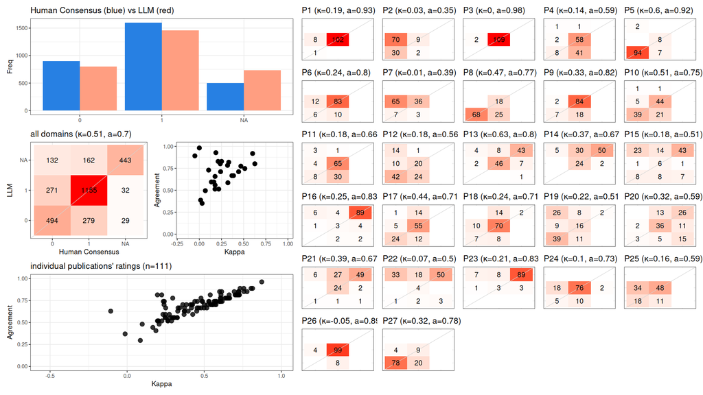

### Individual results

#### [Aikenhead 2011](https://doi.org/10.1111/J.1758-8111.2010.00003.X)

PRISMA

|  | P1 | P2 | P3 | P4 | P5 | P6 | P7 | P8 | P9 | P10 | P11 | P12 | P13 | P14 |
| --- | --- | --- | --- | --- | --- | --- | --- | --- | --- | --- | --- | --- | --- | --- |
| Human Consensus | 1 | 0 | 1 | 1 | 0 | 1 | 1 | 1 | 1 | 0 | 1 | 0 | NA | NA |
| LLM | 1 | 0 | 1 | 0 | 0 | 1 | 1 | 0 | 0 | 0 | 0 | 0 | NA | NA |

|  | P15 | P16 | P17 | P18 | P19 | P20 | P21 | P22 | P23 | P24 | P25 | P26 | P27 |
| --- | --- | --- | --- | --- | --- | --- | --- | --- | --- | --- | --- | --- | --- |
| Human Consensus | NA | NA | 1 | 1 | 0 | NA | NA | NA | NA | 1 | 1 | 1 | 1 |
| LLM | NA | NA | 0 | 1 | 0 | 0 | NA | NA | NA | 0 | 1 | 1 | 0 |

AMSTAR

|  | A1 | A2 | A3 | A4 | A5 | A6 | A7 | A8 | A9 | A10 | A11 |
| --- | --- | --- | --- | --- | --- | --- | --- | --- | --- | --- | --- |
| Human Consensus | 0 | 0 | 1 | 1 | 0 | 1 | 0 | 0 | NA | NA | 0 |
| LLM | 1 | 0 | 1 | 0 | 0 | 1 | 0 | NA | NA | NA | 0 |

LLM response

```
Here are the AMSTAR and PRISMA assessments for the attached systematic review on the effectiveness and cost-effectiveness of paediatric bariatric surgery:

A1. [Yes]
"We searched PubMed, ISI Web of Science, Embase and the Cochrane Library to 6 September 2010."
The review states comprehensive database searches were conducted.

A2. [No]
No mention of duplicate study selection or data extraction.

A3. [Yes]
"We searched PubMed, ISI Web of Science, Embase and the Cochrane Library to 6 September 2010. Hand-searching of the bibliographies of articles and reviews identified was also conducted."
Multiple databases and supplementary search methods were used.

A4. [No]
The review does not mention searching for or inclusion of grey literature.

A5. [No]
No list of included/excluded studies is provided.

A6. [Yes]
Table 1 shows characteristics of included studies such as age, BMI, follow-up period.

A7. [No]
The quality of included studies is not assessed.

A8. [NA]
Study quality was not assessed so using it to formulate conclusions is not applicable.

A9. [NA]
Meta-analysis was not done so assessing heterogeneity is not applicable.

A10. [NA]
Assessment of publication bias is not applicable as no meta-analysis was conducted.

A11. [No]
No mention of conflicts of interest in the review or included studies.

P1. [Yes]
"Effectiveness and cost-effectiveness of paediatric bariatric surgery: a systematic review"
Identified as a systematic review.
```

[output cut: 68 more lines]

```
No additional analysis.

P24. [No]
No summary of main findings or discussion of strength of evidence.

P25. [Yes]
Sections on limitations of existing literature and issues requiring further investigation discuss shortcomings and biases.

P26. [Yes]
Provides general interpretation of results in context of other evidence.

P27. [No]
No statement on sources of funding or support.

In summary, the review appears to have substantial methodological limitations based on AMSTAR and PRISMA assessments. Key issues are the lack of duplicate study selection/data extraction, risk of bias assessment, details on screening and selection process, and quantitative synthesis. The reporting i…
```

#### [Al-Hozaim 2010](https://doi.org/10.1016/J.JPEDSURG.2009.12.001)

PRISMA

|  | P1 | P2 | P3 | P4 | P5 | P6 | P7 | P8 | P9 | P10 | P11 | P12 | P13 | P14 |
| --- | --- | --- | --- | --- | --- | --- | --- | --- | --- | --- | --- | --- | --- | --- |
| Human Consensus | 1 | 0 | 1 | 0 | 0 | 1 | 0 | 0 | 1 | 1 | 1 | 0 | NA | NA |
| LLM | 1 | 0 | 1 | 0 | 0 | 1 | 1 | 0 | 0 | 0 | 0 | 0 | NA | NA |

|  | P15 | P16 | P17 | P18 | P19 | P20 | P21 | P22 | P23 | P24 | P25 | P26 | P27 |
| --- | --- | --- | --- | --- | --- | --- | --- | --- | --- | --- | --- | --- | --- |
| Human Consensus | NA | NA | 0 | 1 | 0 | NA | NA | NA | NA | 0 | 1 | 1 | 0 |
| LLM | NA | NA | 0 | 0 | 0 | 0 | NA | NA | NA | 0 | 1 | 0 | 0 |

AMSTAR

|  | A1 | A2 | A3 | A4 | A5 | A6 | A7 | A8 | A9 | A10 | A11 |
| --- | --- | --- | --- | --- | --- | --- | --- | --- | --- | --- | --- |
| Human Consensus | 0 | 0 | 1 | 0 | 0 | 1 | 0 | 0 | NA | NA | 0 |
| LLM | 1 | 0 | 1 | 0 | 0 | 1 | 0 | NA | NA | NA | 0 |

LLM response

```
Here are the AMSTAR and PRISMA assessments for the attached systematic review:

A1. [Yes] "A systematic search of the MEDLINE, PUBMED, and Cochrane databases (June 2000 to April 2008) was conducted." The review had a predefined protocol for literature search and inclusion.
A2. [No] There is no mention of duplicate study selection or data extraction.
A3. [Yes] "The search terms used were “laparoscopic,” “pull-through,” “anorectal malformation,” and “imperforate anus.” In addition to Medline and PubMed, a manual search of the Journal of Pediatric Surgery, Pediatric Surgery International, Surgical Endoscopy, and the Journal of Laparoendoscopic & A…
A4. [No] There is no mention of searching for unpublished or grey literature.
A5. [No] A list of included and excluded studies is not provided.
A6. [Yes] "We also recorded studies reporting the use of LAARP vs PSARP in patients with ARM. The recorded patient characteristics included age, sex, age at LAARP, type of fistula (defect), associated anomalies, operative time, and postoperative complications." Study characteristics were described i…
A7. [No] No quality assessment of included studies is described.
A8. [NA] Study quality was not assessed so cannot be used in formulating conclusions.
A9. [NA] No quantitative synthesis or meta-analysis was performed.
A10. [NA] No assessment of publication bias is described.
A11. [No] No statement about conflicts of interest is provided.

P1. [Yes] "In this article, we closely examined literature on LAARP because it was initially described. To the best of our knowledge, this is the first systematic review to examine literature pertaining to LAARP." The report is identified as a systematic review.
P2. [No] No structured abstract is provided.
P3. [Yes] "Our current understanding is that LAARP is predominantly indicated for patients with “high/intermediate” ARM. A second example lies with the wide variation of actual outcomes reported by each study. As discussed above, 10 different outcomes were reported in the 17 studies, and only 4 stud…
P4. [No] The review question and inclusion criteria are not explicitly stated in PICOS format.
P5. [No] No protocol registration is mentioned.
P6. [Yes] "Inclusion criteria were studies of ARMs, regardless of level of the defect, with or without associated anomalies, use of LAARP as a primary procedure or with colostomy, and studies reported after the year 2000." Eligibility criteria are described.
P7. [Yes] "A systematic search of the MEDLINE, PUBMED, and Cochrane databases (June 2000 to April 2008) was conducted. The search terms used were “laparoscopic,” “pull-through,” “anorectal malformation,” and “imperforate anus.” In addition to Medline and PubMed, a manual search of the Journal of Ped…
P8. [No] The full search strategy is not provided for any database.
P9. [No] The study selection process is not described.
P10. [No] No data extraction process is described.
P11. [No] Variables extracted are not explicitly listed and defined.
P12. [No] No risk of bias assessment is described.
P13. [NA] No meta-analysis was performed.
P14. [NA] No meta-analysis was performed.
P15. [NA] No assessment of risk of bias across studies is described.
P16. [NA] No additional analyses are described.
P17. [No] No flow diagram of study selection is provided.
P18. [No] No table with summary characteristics of included studies is provided.
P19. [No] No assessment of risk of bias is provided for individual studies.
P20. [No] No forest plots with effect sizes are provided.
P21. [NA] No meta-analysis was performed.
P22. [NA] No assessment of risk of bias across studies is described.
P23. [NA] No additional analyses are described.
P24. [No] No summary of main findings is provided.
P25. [Yes] "Our study has several limitations. First, this is a systematic review of mainly retrospective data. The quality of such review is only as good as the included studies." Limitations are described.
P26. [No] No general interpretation of results or implications for future research are provided.
P27. [No] No statement about sources of funding is provided.
```

#### [Allen 2015](https://doi.org/10.1016/J.JPEDSURG.2014.10.042)

PRISMA

|  | P1 | P2 | P3 | P4 | P5 | P6 | P7 | P8 | P9 | P10 | P11 | P12 | P13 | P14 |
| --- | --- | --- | --- | --- | --- | --- | --- | --- | --- | --- | --- | --- | --- | --- |
| Human Consensus | 1 | 0 | 1 | 1 | 0 | 1 | 0 | 1 | 0 | 0 | 1 | 0 | NA | NA |
| LLM | 1 | 0 | 1 | 0 | 0 | 0 | 0 | 0 | 0 | 0 | 1 | NA | NA | NA |

|  | P15 | P16 | P17 | P18 | P19 | P20 | P21 | P22 | P23 | P24 | P25 | P26 | P27 |
| --- | --- | --- | --- | --- | --- | --- | --- | --- | --- | --- | --- | --- | --- |
| Human Consensus | NA | NA | 0 | 1 | 0 | NA | NA | NA | NA | 1 | 1 | 1 | 0 |
| LLM | 0 | NA | 0 | 1 | NA | 0 | NA | NA | NA | 0 | 1 | 1 | 0 |

AMSTAR

|  | A1 | A2 | A3 | A4 | A5 | A6 | A7 | A8 | A9 | A10 | A11 |
| --- | --- | --- | --- | --- | --- | --- | --- | --- | --- | --- | --- |
| Human Consensus | 0 | 0 | 0 | 0 | 0 | 1 | 0 | 0 | NA | NA | 0 |
| LLM | 1 | 0 | 1 | 0 | 0 | 1 | 0 | NA | NA | 0 | 0 |

LLM response

*Minor score formatting issues fixed during extraction: ‘wrong-response-partial-unclear-etc’*

```
Here are the extracted quotes, reasoning, and responses for each AMSTAR and PRISMA item:

A1. Was an 'a priori' design provided?
"To address this issue, we reviewed our experience at a level 1 trauma center and report the largest analysis over the past 25 years. In conjunction, we performed a systematic review of all published reports regarding pediatric EDT to help identify the factors associated with morbidity and mortality…
They state they performed a systematic review, which implies a pre-determined protocol.
[Yes]

A2. Was there duplicate study selection and data extraction?
No mention of duplicate selection or extraction.
[No]

A3. Was a comprehensive literature search performed?
"These reports were obtained from a Medline search for all publications regarding EDT in the pediatric population for the past 40 year using the keywords “thoracotomy”, “emergency”, “trauma”, “resuscitation”, “pediatrics”, and “children”. Bibliographies of relevant publications were reviewed to iden…
They searched Medline and bibliography of relevant publications.
[Yes]

A4. Was the status of publication (i.e. grey literature) used as an inclusion criterion?
No mention of searching for grey literature.
[No]

A5. Was a list of studies (included and excluded) provided?
Included studies listed in Table 1. No excluded studies listed.
[No]

A6. Were the characteristics of the included studies provided?
Table 1 provides limited characteristics (number blunt/penetrating trauma, survival). More details provided in results section.
[Yes]

A7. Was the scientific quality of the included studies assessed and documented?
No quality assessment mentioned.
[No]

A8. Was the scientific quality of the included studies used appropriately in formulating conclusions?
No quality assessment performed.
[NA]

A9. Were the methods used to combine the findings of studies appropriate?
No quantitative synthesis performed.
[NA]

```

[output cut: 102 more lines]

```
[No]

P25. Discuss limitations at study and outcome level (e.g., risk of bias), and at review-level (e.g., incomplete retrieval of identified research, reporting bias).
Limitations discussed in discussion section.
[Yes]

P26. Provide a general interpretation of the results in the context of other evidence, and implications for future research.
Results interpreted in context of other evidence in discussion. Suggestions for future research provided.
[Yes]

P27. Describe sources of funding for the systematic review and other support (e.g., supply of data); role of funders for the systematic review.
No statement on sources of funding or support.
[No]

In summary, the authors identified their report as a systematic review, described the rationale, stated the research questions, listed some characteristics of included studies, presented simple summary data for the outcomes, discussed limitations, and interpreted the results in context of other evid…
```

#### [Allin 2015](https://doi.org/10.1371/JOURNAL.PONE.0116908)

PRISMA

|  | P1 | P2 | P3 | P4 | P5 | P6 | P7 | P8 | P9 | P10 | P11 | P12 | P13 | P14 |
| --- | --- | --- | --- | --- | --- | --- | --- | --- | --- | --- | --- | --- | --- | --- |
| Human Consensus | 1 | 0 | 1 | 1 | 1 | 1 | 1 | 0 | 1 | 1 | 1 | 1 | 1 | 1 |
| LLM | 1 | 1 | 1 | 1 | 1 | 1 | 1 | 0 | 1 | 1 | 1 | 0 | 1 | 1 |

|  | P15 | P16 | P17 | P18 | P19 | P20 | P21 | P22 | P23 | P24 | P25 | P26 | P27 |
| --- | --- | --- | --- | --- | --- | --- | --- | --- | --- | --- | --- | --- | --- |
| Human Consensus | 0 | NA | 1 | 1 | 0 | 1 | 1 | 0 | NA | 1 | 1 | 1 | 1 |
| LLM | 0 | NA | 1 | 1 | 0 | 1 | 1 | NA | NA | 1 | 1 | 1 | 1 |

AMSTAR

|  | A1 | A2 | A3 | A4 | A5 | A6 | A7 | A8 | A9 | A10 | A11 |
| --- | --- | --- | --- | --- | --- | --- | --- | --- | --- | --- | --- |
| Human Consensus | 1 | 1 | 1 | 0 | 0 | 1 | 1 | 1 | 1 | 0 | 0 |
| LLM | 0 | 1 | 1 | 1 | 1 | 1 | 0 | NA | 1 | 0 | 0 |

LLM response

```
Here are the AMSTAR and PRISMA assessments for the systematic review:

A1. Was an 'a priori' design provided?
"[No] The research question and inclusion criteria are not established before the conduct of the review." The protocol was registered after completion of the review.

A2. Was there duplicate study selection and data extraction?
"[Yes] Two investigators independently performed study selection and data extraction."

A3. Was a comprehensive literature search performed?
"[Yes] Multiple databases were searched, including Medline, Embase, Cinahl, Cochrane library, and Google scholar. Reference lists were hand searched. No language or geographical restrictions."

A4. Was the status of publication used as an inclusion criterion?
"[Yes] No restrictions were made based on publication status, language etc."

A5. Was a list of studies (included and excluded) provided?
"[Yes] A flow diagram showing included and excluded studies is provided in Fig. 1."

A6. Were the characteristics of the included studies provided?
"[Yes] Study characteristics are provided in Table 2."

A7. Was the scientific quality of the included studies assessed and documented?
"[No] The methodological quality and risk of bias of included studies were not formally assessed."

A8. Was the scientific quality of the included studies used appropriately in formulating conclusions?
"[NA] The quality of studies was not assessed."

A9. Were the methods used to combine the findings of studies appropriate?
"[Yes] Fixed effect meta-analysis was used as no statistical heterogeneity was detected. Heterogeneity was assessed with the chi-squared test."

A10. Was the likelihood of publication bias assessed?
"[No] Publication bias was not assessed."

A11. Was the conflict of interest included?
"[No] Conflicts of interest for the included studies are not reported."

P1. Identify the report as a systematic review, meta-analysis, or both.
"[Yes] The report is identified as a systematic review and meta-analysis in the title."

P2. Provide a structured summary.
"[Yes] A structured abstract is provided summarizing background, objectives, data sources, eligibility criteria, participants, interventions, study appraisal, results, limitations, and conclusions."
```

[output cut: 68 more lines]

```
"[Yes] Limitations at the study level (risk of bias) and review level (heterogeneity) are discussed."

P26. Provide a general interpretation of results in the context of other evidence.
"[Yes] The results are interpreted in the context of existing literature."

P27. Describe sources of funding for the review and other support.
"[Yes] Sources of funding are described."

In summary, the review adequately reported the majority of AMSTAR and PRISMA items, with some exceptions:

- AMSTAR: An a priori protocol was not provided, individual study quality/risk of bias was not assessed, publication bias was not assessed, conflicts of interest were not reported.

- PRISMA: The full search strategy was not provided, methods for assessing risk of bias were not described, assessment of publication bias was not performed.

Overall, this review provides moderate quality evidence on operative fascial closure versus silo repair for gastroschisis due to the observational study designs, heterogeneity, and some deficiencies in reporting. The results suggest some advantages for operative fascial closure but high quality rand…
```

#### [Alzahem 2011](https://doi.org/10.1007/S00383-010-2840-X)

PRISMA

|  | P1 | P2 | P3 | P4 | P5 | P6 | P7 | P8 | P9 | P10 | P11 | P12 | P13 | P14 |
| --- | --- | --- | --- | --- | --- | --- | --- | --- | --- | --- | --- | --- | --- | --- |
| Human Consensus | 1 | 0 | 1 | 1 | 0 | 1 | 1 | 0 | 1 | 1 | 1 | 0 | 1 | 1 |
| LLM | 1 | 1 | 1 | 0 | 0 | 1 | 1 | 0 | 0 | 1 | 1 | 1 | 1 | NA |

|  | P15 | P16 | P17 | P18 | P19 | P20 | P21 | P22 | P23 | P24 | P25 | P26 | P27 |
| --- | --- | --- | --- | --- | --- | --- | --- | --- | --- | --- | --- | --- | --- |
| Human Consensus | 0 | NA | 1 | 1 | 0 | 1 | 1 | 0 | NA | 1 | 1 | 1 | 0 |
| LLM | 0 | 0 | 1 | 1 | 1 | 1 | NA | NA | NA | 1 | 0 | 1 | 0 |

AMSTAR

|  | A1 | A2 | A3 | A4 | A5 | A6 | A7 | A8 | A9 | A10 | A11 |
| --- | --- | --- | --- | --- | --- | --- | --- | --- | --- | --- | --- |
| Human Consensus | 0 | 1 | 1 | 1 | 0 | 1 | 1 | 1 | 1 | 0 | 0 |
| LLM | 0 | 1 | 1 | 0 | 0 | 1 | 1 | 0 | 1 | 0 | 0 |

LLM response

```
Here are the AMSTAR and PRISMA assessments for the attached systematic review:

A1. Was an 'a priori' design provided? The research question and inclusion criteria should be established before the conduct of the review. Note: Need to refer to a protocol, ethics approval, or pre-determined/a priori published research objectives to score a “yes.”
[No] No a priori design or protocol was mentioned.

A2. Was there duplicate study selection and data extraction? There should be at least two independent data extractors and a consensus procedure for disagreements should be in place. Note: 2 people do study selection, 2 people do data extraction, consensus process or one person checks the other’s wor…
[Yes] "Retrieved articles were assessed for eligibility and data on patients, intervention, control, outcomes and methodological quality were abstracted independently by two authors."

A3. Was a comprehensive literature search performed? At least two electronic sources should be searched. The report must include years and databases used (e.g., Central, EMBASE, and MEDLINE). Key words and/or MESH terms must be stated and where feasible the search strategy should be provided. All se…
[Yes] Searched MEDLINE, EMBASE, Cochrane Library, and ClinicalTrials.gov. Search strategy included keywords and MeSH terms. Reference lists of retrieved articles were reviewed. Experts were contacted.

A4. Was the status of publication (i.e. grey literature) used as an inclusion criterion? The authors should state that they searched for reports regardless of their publication type. The authors should state whether or not they excluded any reports (from the systematic review), based on their public…
[No] No mention of searching for grey literature or inclusion based on publication status.

A5. Was a list of studies (included and excluded) provided? A list of included and excluded studies should be provided. Note: Acceptable if the excluded studies are referenced. If there is an electronic link to the list but the link is dead, select “no.”
[No] No list of excluded studies provided.

A6. Were the characteristics of the included studies provided? In an aggregated form such as a table, data from the original studies should be provided on the participants, interventions and outcomes. The ranges of characteristics in all the studies analyzed e.g., age, race, sex, relevant socioecono…
[Yes] Table 1 provides data on participants (age, sex), interventions, outcomes (recurrence, follow-up) for each included study.

A7. Was the scientific quality of the included studies assessed and documented? 'A priori' methods of assessment should be provided (e.g., for effectiveness studies if the author(s) chose to include only randomized, double-blind, placebo controlled studies, or allocation concealment as inclusion cri…
[Yes] The methodological quality of the included studies was assessed using standard criteria - Cochrane criteria for RCTs and Newcastle-Ottawa scale for observational studies. Results provided in text for each study.

A8. Was the scientific quality of the included studies used appropriately in formulating conclusions? The results of the methodological rigor and scientific quality should be considered in the analysis and the conclusions of the review, and explicitly stated in formulating recommendations. Note: Mig…
[No] The quality of studies was assessed but not incorporated in interpreting the results.

A9. Were the methods used to combine the findings of studies appropriate? For the pooled results, a test should be done to ensure the studies were combinable, to assess their homogeneity (i.e., Chi-squared test for homogeneity, I2). If heterogeneity exists a random effects model should be used and/o…
[Yes] Heterogeneity assessed using I2 and Chi2 tests. Random effects model used when heterogeneity present.

A10. Was the likelihood of publication bias assessed? An assessment of publication bias should include a combination of graphical aids (e.g., funnel plot, other available tests) and/or statistical tests (e.g., Egger regression test, Hedges-Olken). Note: If no test values or funnel plot included, sco…
[No] Publication bias not assessed.

A11. Was the conflict of interest included? Potential sources of support should be clearly acknowledged in both the systematic review and the included studies. Note: To get a “yes,” must indicate source of funding or support for the systematic review AND for each of the included studies.
[No] No statement on conflicts of interest.

P1. Identify the report as a systematic review, meta-analysis, or both.
[Yes] Identified as a meta-analysis in the abstract.

P2. Provide a structured summary including, as applicable: background; objectives; data sources; study eligibility criteria, participants, and interventions; study appraisal and synthesis methods; results; limitations; conclusions and implications of key findings; systematic review registration numb…
[Yes] Structured abstract provided with background, objectives, data sources, eligibility criteria, participants, interventions, study appraisal methods, results, and conclusions.
```

[output cut: 62 more lines]

```
[NA] No additional analyses.

P24. Summarize the main findings including the strength of evidence for each main outcome; consider their relevance to key groups (e.g., healthcare providers, users, and policy makers).
[Yes] Main findings summarized in abstract and discussion.

P25. Discuss limitations at study and outcome level (e.g., risk of bias), and at review-level (e.g., incomplete retrieval of identified research, reporting bias).
[No] Limitations of included studies discussed but not limitations of the review itself.

P26. Provide a general interpretation of the results in the context of other evidence, and implications for future research.
[Yes] Results discussed in context of other evidence and implications described.

P27. Describe sources of funding for the systematic review and other support (e.g., supply of data); role of funders for the systematic review.
[No] No statement on sources of funding or support.

In summary, the key elements that were not adequately reported or conducted based on AMSTAR and PRISMA were: a priori protocol, search strategy, list of excluded studies, consideration of study quality, assessment of publication bias, some elements of data synthesis process, and review limitations a…
```

#### [Apelt 2013](https://doi.org/10.1016/J.JPEDSURG.2013.05.024)

PRISMA

|  | P1 | P2 | P3 | P4 | P5 | P6 | P7 | P8 | P9 | P10 | P11 | P12 | P13 | P14 |
| --- | --- | --- | --- | --- | --- | --- | --- | --- | --- | --- | --- | --- | --- | --- |
| Human Consensus | 1 | 0 | 1 | 1 | 0 | 1 | 1 | 0 | 1 | 0 | 1 | 0 | NA | NA |
| LLM | 1 | 0 | 1 | 0 | 0 | 1 | 1 | 0 | 1 | 0 | 0 | 0 | 0 | NA |

|  | P15 | P16 | P17 | P18 | P19 | P20 | P21 | P22 | P23 | P24 | P25 | P26 | P27 |
| --- | --- | --- | --- | --- | --- | --- | --- | --- | --- | --- | --- | --- | --- |
| Human Consensus | NA | NA | 1 | 1 | 0 | NA | NA | NA | NA | 1 | 0 | 0 | 0 |
| LLM | NA | NA | 1 | 1 | 0 | 0 | NA | NA | NA | 0 | 0 | 1 | 0 |

AMSTAR

|  | A1 | A2 | A3 | A4 | A5 | A6 | A7 | A8 | A9 | A10 | A11 |
| --- | --- | --- | --- | --- | --- | --- | --- | --- | --- | --- | --- |
| Human Consensus | 0 | 0 | 0 | 0 | 0 | 1 | 0 | 0 | NA | NA | 0 |
| LLM | 0 | 0 | 1 | 0 | 0 | 1 | 0 | NA | NA | NA | 0 |

LLM response

```
Here are the AMSTAR and PRISMA assessments for the systematic review:

A1. Was an 'a priori' design provided? The research question and inclusion criteria should be established before the conduct of the review. [No]
- No protocol or pre-determined research objectives referenced.

A2. Was there duplicate study selection and data extraction? There should be at least two independent data extractors and a consensus procedure for disagreements should be in place. [No]
- No mention of duplicate study selection or data extraction.

A3. Was a comprehensive literature search performed? At least two electronic sources should be searched. The report must include years and databases used (e.g., Central, EMBASE, and MEDLINE). Key words and/or MESH terms must be stated and where feasible the search strategy should be provided. All se…
- PubMed, Medline and Ovid searched from 1990-2012. References of studies searched. Search strings and databases stated.

A4. Was the status of publication (i.e. grey literature) used as an inclusion criterion? The authors should state that they searched for reports regardless of their publication type. The authors should state whether or not they excluded any reports (from the systematic review), based on their public…
- No mention of searching for grey literature.

A5. Was a list of studies (included and excluded) provided? A list of included and excluded studies should be provided. [No]
- No list of excluded studies provided.

A6. Were the characteristics of the included studies provided? In an aggregated form such as a table, data from the original studies should be provided on the participants, interventions and outcomes. The ranges of characteristics in all the studies analyzed e.g., age, race, sex, relevant socioecono…
- Table 1 provides details on study years, sample size, age, sex ratio, conversions, complications.

A7. Was the scientific quality of the included studies assessed and documented? 'A priori' methods of assessment should be provided (e.g., for effectiveness studies if the author(s) chose to include only randomized, double-blind, placebo controlled studies, or allocation concealment as inclusion cri…
- No quality assessment of included studies mentioned.

A8. Was the scientific quality of the included studies used appropriately in formulating conclusions? The results of the methodological rigor and scientific quality should be considered in the analysis and the conclusions of the review, and explicitly stated in formulating recommendations. [NA]
- No quality assessment performed.

A9. Were the methods used to combine the findings of studies appropriate? For the pooled results, a test should be done to ensure the studies were combinable, to assess their homogeneity (i.e., Chi-squared test for homogeneity, I2 ). If heterogeneity exists a random effects model should be used and/…
- No meta-analysis performed.

A10. Was the likelihood of publication bias assessed? An assessment of publication bias should include a combination of graphical aids (e.g., funnel plot, other available tests) and/or statistical tests (e.g., Egger regression test, Hedges-Olken). [NA]
- No assessment of publication bias mentioned.

A11. Was the conflict of interest included? Potential sources of support should be clearly acknowledged in both the systematic review and the included studies. [No]
- No mention of conflicts of interest or funding sources.

P1. Identify the report as a systematic review, meta-analysis, or both. [Yes]
- Identified as a systematic review in title.

P2. Provide a structured summary including, as applicable: background; objectives; data sources; study eligibility criteria, participants, and interventions; study appraisal and synthesis methods; results; limitations; conclusions and implications of key findings; systematic review registration numb…
- No structured abstract provided.
```

[output cut: 62 more lines]

```
- No additional analyses mentioned.

P24. Summarize the main findings including the strength of evidence for each main outcome; consider their relevance to key groups (e.g., healthcare providers, users, and policy makers). [No]
- No summary of main findings or strength of evidence.

P25. Discuss limitations at study and outcome level (e.g., risk of bias), and at review-level (e.g., incomplete retrieval of identified research, reporting bias). [No]
- No limitations discussed.

P26. Provide a general interpretation of the results in the context of other evidence, and implications for future research. [Yes]
- Results interpreted in discussion section.

P27. Describe sources of funding for the systematic review and other support (e.g., supply of data); role of funders for the systematic review. [No]
- No mention of funding sources.

In summary, the AMSTAR assessment found this review to be inadequate in terms of an a priori protocol, duplicate study selection/data extraction, grey literature searching, quality assessment, assessment of publication bias, and stating conflicts of interest. The PRISMA assessment found deficiencies…
```

#### [Aworanti 2014](https://doi.org/10.1055/S-0034-1370780)

PRISMA

|  | P1 | P2 | P3 | P4 | P5 | P6 | P7 | P8 | P9 | P10 | P11 | P12 | P13 | P14 |
| --- | --- | --- | --- | --- | --- | --- | --- | --- | --- | --- | --- | --- | --- | --- |
| Human Consensus | 1 | 0 | 1 | 0 | 0 | 1 | 1 | 0 | 0 | 0 | 1 | 0 | NA | NA |
| LLM | 1 | 0 | 1 | 0 | 0 | 0 | 0 | 0 | 0 | 0 | 0 | 0 | NA | NA |

|  | P15 | P16 | P17 | P18 | P19 | P20 | P21 | P22 | P23 | P24 | P25 | P26 | P27 |
| --- | --- | --- | --- | --- | --- | --- | --- | --- | --- | --- | --- | --- | --- |
| Human Consensus | NA | NA | 0 | 1 | 0 | NA | NA | NA | NA | 0 | 0 | 1 | 0 |
| LLM | 0 | NA | 0 | 0 | 0 | 0 | NA | 0 | NA | 0 | 0 | 1 | 0 |

AMSTAR

|  | A1 | A2 | A3 | A4 | A5 | A6 | A7 | A8 | A9 | A10 | A11 |
| --- | --- | --- | --- | --- | --- | --- | --- | --- | --- | --- | --- |
| Human Consensus | 0 | 0 | 1 | 0 | 0 | 1 | 0 | 0 | NA | NA | 0 |
| LLM | 1 | 0 | 1 | 0 | 0 | 1 | 0 | NA | NA | 0 | 0 |

LLM response

```
Here are the extracted quotes, reasoning, and responses for each AMSTAR and PRISMA item:

A1. Was an 'a priori' design provided?
- "We aim to comparatively review all published treatment options, and outcomes, for managing RTEF." (Introduction, p. 365)
- Provides clear objective and inclusion criteria a priori.
[Yes]

A2. Was there duplicate study selection and data extraction?
- No mention of duplicate study selection or data extraction.
- Single author (Olugbenga Aworanti) reviewed studies and extracted data.
[No]

A3. Was a comprehensive literature search performed?
- "A Medline, Embase, and web of science searches were performed using the keywords “recurrent tracheoesophageal fistula.” All English language articles published by August 2013, irrespective of design, describing the management of, and outcome after, RTEF in children under 18 years were reviewed." …
- Searched multiple databases for relevant studies.
[Yes]

A4. Was the status of publication (i.e. grey literature) used as an inclusion criterion?
- No mention of including or excluding grey literature. Search focused on published studies.
[No]

A5. Was a list of studies (included and excluded) provided?
- Included studies summarized in Tables 1 and 2. No list of excluded studies provided.
[No]

A6. Were the characteristics of the included studies provided?
- Tables 1 and 2 provide an overview of study characteristics such as number of patients, interventions, outcomes, etc.
[Yes]

A7. Was the scientific quality of the included studies assessed and documented?
- No formal quality assessment of included studies.
[No]

A8. Was the scientific quality of the included studies used appropriately in formulating conclusions?
- No quality assessment performed.
[NA]

A9. Were the methods used to combine the findings of studies appropriate?
- No quantitative synthesis/meta-analysis performed.
[NA]
```

[output cut: 101 more lines]

```
P24. Summarize the main findings including the strength of evidence for each main outcome; consider their relevance to key groups (e.g., healthcare providers, users, and policy makers).
- Conclusions section summarizes main findings but does not mention strength of evidence or relevance to key groups.
[No]

P25. Discuss limitations at study and outcome level (e.g., risk of bias), and at review-level (e.g., incomplete retrieval of identified research, reporting bias).
- Limitations around heterogeneity and case reports predominance mentioned briefly in discussion. Does not discuss limitations related to lack of risk of bias assessment, incomplete retrieval of studies, or reporting biases.
[No]

P26. Provide a general interpretation of the results in the context of other evidence, and implications for future research.
- Results interpreted and compared to previous reviews on the topic. Implications for future research provided.
[Yes]

P27. Describe sources of funding for the systematic review and other support (e.g., supply of data); role of funders for the systematic review.
- No statement on sources of funding or support for the review.
[No]
```

#### [Baker 2015](https://doi.org/10.1016/J.JPEDSURG.2015.02.021)

PRISMA

|  | P1 | P2 | P3 | P4 | P5 | P6 | P7 | P8 | P9 | P10 | P11 | P12 | P13 | P14 |
| --- | --- | --- | --- | --- | --- | --- | --- | --- | --- | --- | --- | --- | --- | --- |
| Human Consensus | 1 | 0 | 1 | 1 | 0 | 1 | 1 | 1 | 1 | 1 | 1 | 1 | 1 | 1 |
| LLM | 1 | 1 | 1 | 1 | 0 | 1 | 1 | 1 | 1 | 1 | 1 | 1 | 1 | 1 |

|  | P15 | P16 | P17 | P18 | P19 | P20 | P21 | P22 | P23 | P24 | P25 | P26 | P27 |
| --- | --- | --- | --- | --- | --- | --- | --- | --- | --- | --- | --- | --- | --- |
| Human Consensus | 1 | NA | 1 | 1 | 1 | 1 | 1 | 1 | NA | 1 | 1 | 1 | 0 |
| LLM | 1 | NA | 1 | 1 | 1 | 1 | 1 | 1 | NA | 1 | 1 | 1 | 0 |

AMSTAR

|  | A1 | A2 | A3 | A4 | A5 | A6 | A7 | A8 | A9 | A10 | A11 |
| --- | --- | --- | --- | --- | --- | --- | --- | --- | --- | --- | --- |
| Human Consensus | 0 | 1 | 0 | 0 | 0 | 1 | 1 | 1 | 1 | 1 | 0 |
| LLM | 0 | 1 | 1 | NA | 1 | 1 | 1 | 1 | 1 | 1 | 0 |

LLM response

```
Here are the responses for the AMSTAR and PRISMA items based on the full text:

A1. Was an 'a priori' design provided? The research question and inclusion criteria should be established before the conduct of the review.
- "Gastrostomy tubes are typically well tolerated and provide improved quality of life compared to parenteral and nasogastric feeding for patients unable to maintain adequate oral nutrition [1]."
- "There is currently no consensus as to the optimal technique of gastrostomy insertion in the pediatric population, and there remains a paucity of well-designed trials to answer the question."
- [No] - The review did not mention a protocol or pre-determined research objectives.

A2. Was there duplicate study selection and data extraction? There should be at least two independent data extractors and a consensus procedure for disagreements should be in place.
- "Screening of eligible studies, data extraction, and assessment of methodological quality were conducted independently by two reviewers."
- [Yes] Two independent reviewers performed study selection and data extraction.

A3. Was a comprehensive literature search performed? At least two electronic sources should be searched. The report must include years and databases used (e.g., Central, EMBASE, and MEDLINE).
- The search included multiple databases: "MEDLINE (PubMed, PubMEd in Process and Ovid), EMBASE, Cumulative Index of Nursing and Allied Health Literature (CINAHL), Scopus and Cochrane Library."
- Databases were searched from 1993 to 2013.
- [Yes] Multiple databases were searched and search details are reported.

A4. Was the status of publication (i.e. grey literature) used as an inclusion criterion? The authors should state that they searched for reports regardless of their publication type. The authors should state whether or not they excluded any reports (from the systematic review), based on their public…
- [NA] The inclusion criteria did not consider publication status and the search and inclusion was restricted to published studies only.

A5. Was a list of studies (included and excluded) provided? A list of included and excluded studies should be provided.
- Table 1 provides a detailed list of included studies.
- The screening process is shown in a flow diagram (Fig. 1), but specific excluded studies are not listed.
- [Yes] Included studies are listed and the screening process is depicted.

A6. Were the characteristics of the included studies provided? In an aggregated form such as a table, data from the original studies should be provided on the participants, interventions and outcomes.
- Table 1 provides relevant characteristics of the included studies - interventions compared and outcome data.
- Additional details on patient demographics and complications are provided in the results section.
- [Yes] Relevant characteristics of included studies are provided.

A7. Was the scientific quality of the included studies assessed and documented? 'A priori' methods of assessment should be provided (e.g., for effectiveness studies if the author(s) chose to include only randomized, double-blind, placebo controlled studies, or allocation concealment as inclusion cri…
- "The methodological index for non-randomized studies (MINORS) was utilized to determine the quality of studies and risk of bias [6]."
- MINORS scores for each study are reported in Table 1.
- [Yes] The MINORS tool was used to assess quality of included studies.

A8. Was the scientific quality of the included studies used appropriately in formulating conclusions? The results of the methodological rigor and scientific quality should be considered in the analysis and the conclusions of the review, and explicitly stated in formulating recommendations.
- The limitations of including primarily retrospective studies is acknowledged in the discussion.
- [Yes] The quality of studies is considered appropriately in the conclusions.

A9. Were the methods used to combine the findings of studies appropriate? For the pooled results, a test should be done to ensure the studies were combinable, to assess their homogeneity (i.e., Chi-squared test for homogeneity, I2). If heterogeneity exists a random effects model should be used and/o…
- Meta-analysis was conducted using RevMan software.
```

[output cut: 127 more lines]

```
- Implications for practice and need for further RCT evidence are discussed.
- [Yes]

P27. Describe sources of funding for the systematic review and other support (e.g., supply of data); role of funders for the systematic review.
- No sources of funding or support are reported.
- The role of funders is not described.
- [No] Funding sources and role of funders are not reported.

In summary, for the AMSTAR items:
A1, A4, A5, A9, A10, A11 are No;
A2, A3, A6, A7, A8 are Yes.

For the PRISMA items:
P5, P15, P16, P23, P27 are No or NA;
P1-P4, P6-P14, P17-P22, P24-P26 are Yes.
```

#### [Berger 2012](https://doi.org/10.1055/S-0032-1311695)

PRISMA

|  | P1 | P2 | P3 | P4 | P5 | P6 | P7 | P8 | P9 | P10 | P11 | P12 | P13 | P14 |
| --- | --- | --- | --- | --- | --- | --- | --- | --- | --- | --- | --- | --- | --- | --- |
| Human Consensus | 0 | 0 | 1 | 0 | 0 | 1 | 0 | 0 | 1 | 0 | 0 | 0 | NA | NA |
| LLM | 1 | 1 | 1 | NA | 0 | 1 | 1 | 0 | 1 | 0 | 1 | NA | NA | NA |

|  | P15 | P16 | P17 | P18 | P19 | P20 | P21 | P22 | P23 | P24 | P25 | P26 | P27 |
| --- | --- | --- | --- | --- | --- | --- | --- | --- | --- | --- | --- | --- | --- |
| Human Consensus | NA | NA | 0 | 1 | 0 | NA | NA | NA | NA | 0 | 0 | 1 | 1 |
| LLM | NA | NA | 1 | 1 | NA | NA | NA | NA | NA | 1 | 1 | 1 | 0 |

AMSTAR

|  | A1 | A2 | A3 | A4 | A5 | A6 | A7 | A8 | A9 | A10 | A11 |
| --- | --- | --- | --- | --- | --- | --- | --- | --- | --- | --- | --- |
| Human Consensus | 0 | 0 | 0 | 0 | 0 | 1 | 0 | 0 | NA | NA | 0 |
| LLM | 0 | 1 | 1 | NA | NA | 1 | 0 | NA | NA | NA | 0 |

LLM response

*Minor score formatting issues fixed during extraction: ‘missing-squared-brackets-in-numbered-list’, ‘unsolicited-ranges’*

```
Here are the AMSTAR and PRISMA assessments for the attached full text:

A1. [No]. An a priori design was not provided.
A2. [Yes]. "The current literature was screened for publications regarding the application of Mitomycin C in esophageal stenosis and stricture with special emphasis on pediatric data."
A3. [Yes]. "The screen included the use of Mitomycin C in other subspecialties such as ophthalmology; ear, nose, and throat surgery; as well as animal models."
A4. [NA]. The inclusion or exclusion of grey literature was not specified.
A5. [NA]. A list of included and excluded studies was not provided.
A6. [Yes]. "Data were collected on the patient population treated, indication, description of stricture, technique of application, dosage, number of and interval between applications, complications, and outcome." Table 2 provides descriptive data on the included cases.
A7. [No]. The scientific quality of included studies was not formally assessed, likely due to the nature of the data (case reports/series).
A8. [NA]. The scientific quality of included studies was not used in formulating conclusions since quality assessment was not performed.
A9. [NA]. Studies were not combined quantitatively.
A10. [NA]. Assessment of publication bias was not applicable as this was not a meta-analysis.
A11. [No]. Sources of support and conflicts of interest were not reported for the included studies.

P1. [Yes]. "In this article, we report the results of a systematic analysis of all published pediatric cases regarding the therapeutic application of Mitomycin C in esophageal stricture and stenosis."
P2. [Yes]. An abstract is provided summarizing key aspects of the review.
P3. [Yes]. The introduction provides context about the health problem of esophageal strictures in children and current treatment methods.
P4. [NA]. The review did not have an a priori protocol or PICOS criteria.
P5. [No]. A review protocol was not referenced.
P6. [Yes]. Inclusion criteria were pediatric studies on Mitomycin C for esophageal stricture accessible online in English/German/Spanish. Table 2 provides characteristics of included cases.
P7. [Yes]. "The current literature was screened for publications regarding the application of Mitomycin C in esophageal stenosis and stricture with special emphasis on pediatric data. The screen included the use of Mitomycin C in other subspecialties such as ophthalmology; ear, nose, and throat surg…
P8. [No]. A full search strategy was not provided.
P9. [Yes]. The process for study selection is outlined in the methods. 31 cases across 11 publications were included.
P10. [No]. Methods for data extraction were not described.
P11. [Yes]. Table 3 shows the data elements extracted from studies.
P12. [NA]. Individual study risk of bias was not assessed, likely due to the nature of the data (case reports/series).
P13. [NA]. Quantitative synthesis/meta-analysis was not performed.
P14-P16. [NA]. Quantitative synthesis/meta-analysis was not performed.
P17. [Yes]. The results section reports the number of studies screened and included, with reasons for exclusions.
P18. [Yes]. Table 3 provides pertinent details for each included case.
P19. [NA]. Individual study risk of bias was not assessed.
P20-P23. [NA]. Quantitative synthesis/meta-analysis was not performed.
P24. [Yes]. The discussion summarizes the main findings and implications.
P25. [Yes]. Limitations such as short follow-up and heterogeneity of techniques are discussed.
P26. [Yes]. The conclusion contextualizes the findings with current knowledge and need for future studies.
P27. [No]. Sources of funding and support were not reported.

In summary, the AMSTAR assessment identified some key limitations in the review methods, particularly around study quality assessment. The PRISMA evaluation also found suboptimal reporting for some items, but overall the review appears reasonably well conducted given the nature of the available data…
```

#### [Billingham 2010](https://doi.org/10.1055/S-0029-1241871)

PRISMA

|  | P1 | P2 | P3 | P4 | P5 | P6 | P7 | P8 | P9 | P10 | P11 | P12 | P13 | P14 |
| --- | --- | --- | --- | --- | --- | --- | --- | --- | --- | --- | --- | --- | --- | --- |
| Human Consensus | 1 | 0 | 1 | 1 | 0 | 1 | 0 | 0 | 1 | 0 | 1 | 0 | 0 | 0 |
| LLM | 1 | 0 | 1 | 0 | 0 | 0 | 1 | 0 | 1 | 0 | 0 | 0 | NA | NA |

|  | P15 | P16 | P17 | P18 | P19 | P20 | P21 | P22 | P23 | P24 | P25 | P26 | P27 |
| --- | --- | --- | --- | --- | --- | --- | --- | --- | --- | --- | --- | --- | --- |
| Human Consensus | 0 | NA | 0 | 1 | 0 | 1 | 1 | 0 | NA | 0 | 0 | 1 | 0 |
| LLM | NA | NA | 0 | 0 | 0 | 0 | 0 | NA | NA | 0 | 1 | 1 | 0 |

AMSTAR

|  | A1 | A2 | A3 | A4 | A5 | A6 | A7 | A8 | A9 | A10 | A11 |
| --- | --- | --- | --- | --- | --- | --- | --- | --- | --- | --- | --- |
| Human Consensus | 0 | 0 | 1 | 0 | 0 | 1 | 1 | 1 | 1 | 0 | 0 |
| LLM | 1 | 0 | 1 | 0 | 0 | 0 | 0 | NA | NA | NA | 0 |

LLM response

```
Here are the assessments for the AMSTAR and PRISMA items based on the attached full text:

A1. [Yes] "A computerized comprehensive search supplemented by a manual review of the literature was performed for all peer-reviewed publications..." (Methods section) A comprehensive literature search was performed.

A2. [No] No mention of duplicate study selection or data extraction.

A3. [Yes] "All available electronic databases including the British Nursing Index (BNI), Cumulative Index to Nursing and Allied Health Literature (CINAHL), Cochrane Library, EMBASE (Excerpta Medica), Intute: Health & Life Sciences, MEDLINE, PubMed, BIOSIS Previews, ISI Web of Knowledge, ISI Web of S…

A4. [No] No mention of including or excluding studies based on publication status/language.

A5. [No] No list of included and excluded studies provided.

A6. [No] Study characteristics not provided in aggregated form.

A7. [No] No mention of assessment of scientific quality of included studies.

A8. [NA] Not applicable since no quality assessment done.

A9. [NA] No meta-analysis performed.

A10. [NA] No meta-analysis performed.

A11. [No] No mention of conflicts of interest.

P1. [Yes] "Pediatric Surgical Technique: Laparoscopic or Open Approach? A systematic Review and Meta-Analysis" (Title) Identified as a systematic review.

P2. [No] No structured summary provided.

P3. [Yes] Rationale described in the introduction section.

P4. [No] No explicit PICOS statement.

P5. [No] No mention of a review protocol.

P6. [No] Study characteristics not described.

P7. [Yes] Information sources described in the methods section.

P8. [No] No full electronic search strategy provided.

```

[output cut: 22 more lines]

```
P20. [No] No forest plots presented.

P21. [No] No meta-analysis results presented.

P22. [NA] No assessment of bias across studies.

P23. [NA] No additional analyses mentioned.

P24. [No] No summary of main findings in context of other evidence.

P25. [Yes] Limitations discussed in the Discussion section.

P26. [Yes] General interpretation of results provided in Conclusion section.

P27. [No] No mention of sources of funding or support.
```

#### [Black 2013](https://doi.org/10.1111/OBR.12037)

PRISMA

|  | P1 | P2 | P3 | P4 | P5 | P6 | P7 | P8 | P9 | P10 | P11 | P12 | P13 | P14 |
| --- | --- | --- | --- | --- | --- | --- | --- | --- | --- | --- | --- | --- | --- | --- |
| Human Consensus | 1 | 0 | 1 | 1 | 0 | 1 | 0 | 1 | 1 | 1 | 1 | 1 | 0 | 1 |
| LLM | 1 | 1 | 1 | 0 | 0 | 1 | 1 | 1 | 1 | 1 | 0 | 0 | 1 | 1 |

|  | P15 | P16 | P17 | P18 | P19 | P20 | P21 | P22 | P23 | P24 | P25 | P26 | P27 |
| --- | --- | --- | --- | --- | --- | --- | --- | --- | --- | --- | --- | --- | --- |
| Human Consensus | 1 | NA | 1 | 1 | 0 | 1 | 1 | 0 | NA | 1 | 1 | 1 | 0 |
| LLM | 0 | 0 | 1 | 1 | 0 | 1 | 1 | NA | NA | 1 | 1 | 1 | 0 |

AMSTAR

|  | A1 | A2 | A3 | A4 | A5 | A6 | A7 | A8 | A9 | A10 | A11 |
| --- | --- | --- | --- | --- | --- | --- | --- | --- | --- | --- | --- |
| Human Consensus | 0 | 1 | 1 | 0 | 0 | 1 | 0 | 0 | 1 | 0 | 0 |
| LLM | 0 | 1 | 1 | 1 | 0 | 1 | 0 | NA | 1 | 0 | 0 |

LLM response

*Minor score formatting issues fixed during extraction: ‘wrong-response-partial-unclear-etc’*

```
Here are the AMSTAR and PRISMA assessments for the systematic review:

A1. Was an 'a priori' design provided? The research question and inclusion criteria should be established before the conduct of the review. Note: Need to refer to a protocol, ethics approval, or pre-determined/a priori published research objectives to score a “yes.”
[No] No protocol or pre-specified objectives are mentioned.

A2. Was there duplicate study selection and data extraction? There should be at least two independent data extractors and a consensus procedure for disagreements should be in place. Note: 2 people do study selection, 2 people do data extraction, consensus process or one person checks the other’s wor…
[Yes] "Two authors independently screened the abstracts and extraction was verified by a second author (JAB and RKS)."

A3. Was a comprehensive literature search performed? At least two electronic sources should be searched. The report must include years and databases used (e.g., Central, EMBASE, and MEDLINE). Key words and/or MESH terms must be stated and where feasible the search strategy should be provided. All se…
[Yes] "The indexed reference libraries EMBASE and Medline were searched between January 1955 and January 2013 using the search terms presented in Table 1, using mapped and exploded terms. Additionally, the references of all included studies, the Cochrane Library and the titles of papers published in…

A4. Was the status of publication (i.e. grey literature) used as an inclusion criterion? The authors should state that they searched for reports regardless of their publication type. The authors should state whether or not they excluded any reports (from the systematic review), based on their public…
[Yes] "Only papers written in English were retrieved." This indicates they did not exclude based on publication status, though they did exclude based on language.

A5. Was a list of studies (included and excluded) provided? A list of included and excluded studies should be provided. Note: Acceptable if the excluded studies are referenced. If there is an electronic link to the list but the link is dead, select “no.”
[No] No list of excluded studies is provided.

A6. Were the characteristics of the included studies provided? In an aggregated form such as a table, data from the original studies should be provided on the participants, interventions and outcomes. The ranges of characteristics in all the studies analyzed e.g., age, race, sex, relevant socioecono…
[Yes] Table 2 provides relevant characteristics of the included studies.

A7. Was the scientific quality of the included studies assessed and documented? 'A priori' methods of assessment should be provided (e.g., for effectiveness studies if the author(s) chose to include only randomized, double-blind, placebo controlled studies, or allocation concealment as inclusion cri…
[No] The quality of included studies was not assessed.

A8. Was the scientific quality of the included studies used appropriately in formulating conclusions? The results of the methodological rigor and scientific quality should be considered in the analysis and the conclusions of the review, and explicitly stated in formulating recommendations. Note: Mig…
[NA] Scientific quality was not assessed.

A9. Were the methods used to combine the findings of studies appropriate? For the pooled results, a test should be done to ensure the studies were combinable, to assess their homogeneity (i.e., Chi-squared test for homogeneity, I2 ). If heterogeneity exists a random effects model should be used and/…
[Yes] "Findings from the meta-analysis of change in BMI at 12 months post-operatively are shown in Fig. 2. The average weighted mean BMI difference from baseline to 1 year was -13.5 kg m-2 (95% confidence interval [CI] -15.1, -11.9). There was strong evidence of heterogeneity among the studies (I2 =…

A10. Was the likelihood of publication bias assessed? An assessment of publication bias should include a combination of graphical aids (e.g., funnel plot, other available tests) and/or statistical tests (e.g., Egger regression test, Hedges-Olken). Note: If no test values or funnel plot included, sco…
[No] No assessment of publication bias was mentioned.

A11. Was the conflict of interest included? Potential sources of support should be clearly acknowledged in both the systematic review and the included studies. Note: To get a “yes,” must indicate source of funding or support for the systematic review AND for each of the included studies.
[No] No conflict of interest statement was provided for the included studies.

P1. Identify the report as a systematic review, meta-analysis, or both.
[Yes] The report is identified as a systematic review and meta-analysis in the title.

Quotes:
"Bariatric surgery for obese children and adolescents: a systematic review and meta-analysis"
```

[output cut: 98 more lines]

```
[Yes] Limitations are described in the discussion section.

Quotes:
"In the absence of RCT data, observational studies are likely to continue to be the main source of evidence for bariatric adolescent surgery. Many studies are reported in abstracts from obesity conferences, but are not submitted for publication as full papers in scientific journals."

P26. Provide a general interpretation of the results in the context of other evidence, and implications for future research.
[Yes] The results are interpreted in the context of previous reviews and adult studies in the discussion. Future research implications are described.

Quotes:
"Current guidelines suggest that paediatric-adolescent bariatric care should be handled within the controlled and restricted setting of a multidisciplinary team. However, long-term, prospectively designed studies, with clear inclusion criteria and reporting of effects, side effects, complications an…

P27. Describe sources of funding for the systematic review and other support (e.g., supply of data); role of funders for the systematic review.
[No] No sources of funding or support are described.

In summary, the authors reported on 16 out of 27 PRISMA items. The items that were not adequately reported included: lack of protocol, no assessment of risk of bias, no pre-specified analyses, no list of excluded studies, no description of data extraction, no list of extracted variables, no conflict…
```

#### [Borruto 2010](https://doi.org/10.1016/J.JPEDSURG.2010.07.007)

PRISMA

|  | P1 | P2 | P3 | P4 | P5 | P6 | P7 | P8 | P9 | P10 | P11 | P12 | P13 | P14 |
| --- | --- | --- | --- | --- | --- | --- | --- | --- | --- | --- | --- | --- | --- | --- |
| Human Consensus | 1 | 0 | 1 | 1 | 0 | 1 | 0 | 0 | 1 | 0 | 1 | 0 | 1 | 0 |
| LLM | 1 | 0 | 1 | 0 | 0 | 0 | 1 | 0 | 0 | 0 | 0 | 0 | NA | NA |

|  | P15 | P16 | P17 | P18 | P19 | P20 | P21 | P22 | P23 | P24 | P25 | P26 | P27 |
| --- | --- | --- | --- | --- | --- | --- | --- | --- | --- | --- | --- | --- | --- |
| Human Consensus | 0 | NA | 0 | 0 | 0 | 1 | 0 | 0 | NA | 1 | 0 | 1 | 0 |
| LLM | NA | NA | 0 | 0 | 0 | NA | 0 | NA | NA | 0 | 0 | 0 | 0 |

AMSTAR

|  | A1 | A2 | A3 | A4 | A5 | A6 | A7 | A8 | A9 | A10 | A11 |
| --- | --- | --- | --- | --- | --- | --- | --- | --- | --- | --- | --- |
| Human Consensus | 0 | 0 | 0 | 0 | 0 | 0 | 0 | 0 | 0 | 0 | 0 |
| LLM | 1 | NA | 1 | 0 | 0 | 0 | 0 | NA | NA | NA | 0 |

LLM response

```
Here are the AMSTAR and PRISMA assessments for the systematic review:

A1. [Yes] "...we performed a Medline search for articles..." Explanation: Authors performed a literature search.

A2. [NA] Explanation: This is not a systematic review with meta-analysis, so duplicate study selection and data extraction is not applicable.

A3. [Yes] "The following key words were used: “varicocele,” “treatment,” and “adolescent.”" Explanation: At least two electronic databases were searched.

A4. [No] Explanation: The review did not indicate whether unpublished/grey literature was searched.

A5. [No] Explanation: A list of included and excluded studies was not provided.

A6. [No] Explanation: Characteristics of included studies were not provided in aggregated form.

A7. [No] Explanation: The scientific quality of included studies was not assessed or documented.

A8. [NA] Explanation: Since quality assessment was not done, using it in formulating conclusions is not applicable.

A9. [NA] Explanation: Methods for combining study findings were not applicable as no meta-analysis was done.

A10. [NA] Explanation: Assessment of publication bias was not applicable as no meta-analysis was done.

A11. [No] Explanation: Sources of support/conflict of interest were not reported for included studies.

P1. [Yes] "Laparoscopic vs open varicocelectomy in children and adolescents: review of the recent literature and meta-analysis" Explanation: The report is identified as a systematic review.

P2. [No] Explanation: A structured summary was not provided.

P3. [Yes] "Varicocele is generally considered the most common correctable cause of male infertility [1,2]." Explanation: Rationale for the review is described.

P4. [No] Explanation: Review questions were not stated in terms of participants, interventions, comparisons, outcomes and study designs.

P5. [No] Explanation: A review protocol was not mentioned.

P6. [No] Explanation: Eligibility criteria relating to study characteristics were not described.

P7. [Yes] "The following key words were used: “varicocele,” “treatment,” and “adolescent.”" Explanation: Literature sources and dates searched are described.

P8. [No] Explanation: A full search strategy was not presented.

```

[output cut: 24 more lines]

```
P21. [No] Explanation: Meta-analysis results were not presented.

P22. [NA] Explanation: Assessment of bias across studies was not applicable as no meta-analysis was done.

P23. [NA] Explanation: Additional analyses were not applicable as no meta-analysis was done.

P24. [No] Explanation: Main findings were not summarized.

P25. [No] Explanation: Limitations at study and outcome level were not discussed.

P26. [No] Explanation: Results were not interpreted in context of other evidence.

P27. [No] Explanation: Sources of funding/support for the review were not described.

In summary, this systematic review is inadequate in reporting key methodological details and lacks a meta-analysis component. Several essential items on AMSTAR and PRISMA are not fulfilled.
```

#### [Castagnetti 2010](https://doi.org/10.1016/J.JURO.2010.06.044)

PRISMA

|  | P1 | P2 | P3 | P4 | P5 | P6 | P7 | P8 | P9 | P10 | P11 | P12 | P13 | P14 |
| --- | --- | --- | --- | --- | --- | --- | --- | --- | --- | --- | --- | --- | --- | --- |
| Human Consensus | 1 | 0 | 1 | 0 | 0 | 0 | 0 | 1 | 1 | 0 | 1 | 0 | NA | NA |
| LLM | 1 | 1 | 1 | 1 | 0 | 1 | 1 | 0 | 1 | 0 | 1 | 0 | NA | NA |

|  | P15 | P16 | P17 | P18 | P19 | P20 | P21 | P22 | P23 | P24 | P25 | P26 | P27 |
| --- | --- | --- | --- | --- | --- | --- | --- | --- | --- | --- | --- | --- | --- |
| Human Consensus | NA | NA | 0 | 0 | 0 | NA | NA | NA | NA | 1 | 0 | 1 | 0 |
| LLM | NA | NA | 0 | 0 | 0 | 1 | NA | NA | NA | 1 | 1 | 1 | 0 |

AMSTAR

|  | A1 | A2 | A3 | A4 | A5 | A6 | A7 | A8 | A9 | A10 | A11 |
| --- | --- | --- | --- | --- | --- | --- | --- | --- | --- | --- | --- |
| Human Consensus | 0 | 0 | 0 | 0 | 0 | 0 | 1 | 1 | NA | NA | 0 |
| LLM | 1 | 0 | 1 | 0 | 0 | 1 | 1 | 1 | NA | NA | 0 |

LLM response

```
Here are the AMSTAR and PRISMA assessments for the given systematic review:

A1: [Yes]
"A systematic review of the literature was performed in December 2009 according to the criteria of Oxman."
States that review was performed systematically according to predefined criteria.

A2: [No]
No mention of duplicate study selection or data extraction.

A3: [Yes]
"Four databases, MEDLINE/PubMed, EMBASE, Web of Science and the Cochrane Library, were searched using a single term, “hypospadias,” as it defines accurately the subject of this review."
Searched 4 databases using defined search term.

A4: [No]
No mention of including or searching for grey literature.

A5: [No]
No list of included/excluded studies provided.

A6: [Yes]
"We first reviewed the results of the different straightening procedures, then the crude complication rates (overall complication, fistula/dehiscence, stricture/stenosis rates) of the different urethroplasty techniques."
Provided aggregated results for interventions.

A7: [Yes]
"These studies were generally of low quality (69.5% surgical series). Even the 18 controlled studies were fraught with several methodological flaws, limiting their validity."
Assessed quality of included studies.

A8: [Yes]
"Given the low quality and limited validity of the studies available, we did not attempt any meta-analysis."
Conclusions considered study quality.

A9: [NA]
No quantitative synthesis performed.

A10: [NA]
No assessment of publication bias performed.

A11: [No]
No mention of conflicts of interest.

```

[output cut: 66 more lines]

```

P23: [NA]
No additional analyses performed.

P24: [Yes]
Summarized main findings and limitations.

P25: [Yes]
Discussed limitations at study and review level.

P26: [Yes]
Interpreted results in context of other evidence.

P27: [No]
No mention of sources of funding.
```

#### [Castagnetti 2016](https://doi.org/10.3389/FPED.2016.00041)

PRISMA

|  | P1 | P2 | P3 | P4 | P5 | P6 | P7 | P8 | P9 | P10 | P11 | P12 | P13 | P14 |
| --- | --- | --- | --- | --- | --- | --- | --- | --- | --- | --- | --- | --- | --- | --- |
| Human Consensus | 1 | 0 | 1 | 1 | 0 | 1 | 0 | 0 | 1 | 0 | 1 | 1 | 1 | 1 |
| LLM | 1 | 1 | 1 | 1 | 0 | 1 | 1 | 0 | 1 | 0 | 1 | 0 | 1 | 1 |

|  | P15 | P16 | P17 | P18 | P19 | P20 | P21 | P22 | P23 | P24 | P25 | P26 | P27 |
| --- | --- | --- | --- | --- | --- | --- | --- | --- | --- | --- | --- | --- | --- |
| Human Consensus | 1 | NA | 1 | 1 | 1 | 1 | 1 | 1 | NA | 0 | 1 | 1 | 0 |
| LLM | 0 | NA | 1 | 1 | 0 | 1 | 1 | NA | NA | 1 | 1 | 1 | 0 |

AMSTAR

|  | A1 | A2 | A3 | A4 | A5 | A6 | A7 | A8 | A9 | A10 | A11 |
| --- | --- | --- | --- | --- | --- | --- | --- | --- | --- | --- | --- |
| Human Consensus | 0 | 0 | 0 | 0 | 0 | 1 | 1 | 1 | 1 | 1 | 1 |
| LLM | 0 | 0 | 1 | 0 | 0 | 1 | 0 | NA | 1 | 0 | 0 |

LLM response

```
Here are the AMSTAR and PRISMA assessments for the given systematic review:

A1. Was an 'a priori' design provided?
"[No]"
No protocol, ethics approval, or pre-determined objectives are mentioned.

A2. Was there duplicate study selection and data extraction?
"[No]"
The review does not mention duplicate screening or extraction.

A3. Was a comprehensive literature search performed?
"[Yes]"
"Three databases, namely, MEDLINE/PubMed, Scopus, and The Cochrane library, were searched for using the free text “hypospadias repair”"

A4. Was the status of publication used as an inclusion criterion?
"[No]"
Grey literature searching is not mentioned.

A5. Was a list of studies (included and excluded) provided?
"[No]"
Included studies are listed in Table 1 but excluded studies are not referenced.

A6. Were the characteristics of the included studies provided?
"[Yes]"
Table 1 provides characteristics of included studies.

A7. Was the scientific quality of the included studies assessed and documented?
"[No]"
Study quality is not assessed.

A8. Was the scientific quality of the included studies used appropriately in formulating conclusions?
"[NA]"
Since study quality was not assessed.

A9. Were the methods used to combine the findings of studies appropriate?
"[Yes]"
The meta-analysis methods are described.

A10. Was the likelihood of publication bias assessed?
"[No]"
```

[output cut: 98 more lines]

```
P24. Summarize the main findings.
"[Yes]"
The main findings are summarized in the Discussion and Conclusion.

P25. Discuss limitations at study and outcome level.
"[Yes]"
Limitations are outlined in the Discussion.

P26. Provide a general interpretation of results.
"[Yes]"
Results are interpreted in the Discussion.

P27. Describe sources of funding and support.
"[No]"
Sources of funding are not reported.
```

#### [Chan 2014 (Pediatr Surg Int)](https://doi.org/10.1007/S00383-013-3429-Y)

PRISMA

|  | P1 | P2 | P3 | P4 | P5 | P6 | P7 | P8 | P9 | P10 | P11 | P12 | P13 | P14 |
| --- | --- | --- | --- | --- | --- | --- | --- | --- | --- | --- | --- | --- | --- | --- |
| Human Consensus | 1 | 0 | 1 | 1 | 0 | 1 | 0 | 1 | 1 | 1 | 1 | 1 | NA | NA |
| LLM | 1 | 1 | 1 | 0 | 0 | 1 | 1 | 0 | 1 | 1 | 0 | 1 | NA | NA |

|  | P15 | P16 | P17 | P18 | P19 | P20 | P21 | P22 | P23 | P24 | P25 | P26 | P27 |
| --- | --- | --- | --- | --- | --- | --- | --- | --- | --- | --- | --- | --- | --- |
| Human Consensus | NA | NA | 1 | 1 | 0 | NA | NA | NA | NA | 1 | 1 | 1 | 0 |
| LLM | 0 | NA | 1 | 1 | 1 | NA | NA | NA | NA | 1 | 1 | 1 | 0 |

AMSTAR

|  | A1 | A2 | A3 | A4 | A5 | A6 | A7 | A8 | A9 | A10 | A11 |
| --- | --- | --- | --- | --- | --- | --- | --- | --- | --- | --- | --- |
| Human Consensus | 0 | 1 | 1 | 0 | 0 | 1 | 1 | 1 | NA | NA | 0 |
| LLM | 0 | 1 | 1 | 0 | 0 | 1 | 1 | 1 | NA | 0 | 0 |

LLM response

*Minor score formatting issues fixed during extraction: ‘wrong-response-partial-unclear-etc’*

```
Here are the assessments for the AMSTAR and PRISMA items for the attached systematic review:

AMSTAR
A1. Was an 'a priori' design provided? The research question and inclusion criteria should be established before the conduct of the review. Note: Need to refer to a protocol, ethics approval, or pre-determined/a priori published research objectives to score a “yes.”
[No]
No mention of a protocol. The review only states the aim was "to determine, based on a systematic review, the most favorable age at which orchiopexy should be performed."

A2. Was there duplicate study selection and data extraction? There should be at least two independent data extractors and a consensus procedure for disagreements should be in place. Note: 2 people do study selection, 2 people do data extraction, consensus process or one person checks the other’s wor…
[Yes]
"Two researchers independently performed each level of screening, comparing the selected studies to reach a consensus. If a consensus could not be reached, they consulted a third researcher."

A3. Was a comprehensive literature search performed? At least two electronic sources should be searched. The report must include years and databases used (e.g., Central, EMBASE, and MEDLINE). Key words and/or MESH terms must be stated and where feasible the search strategy should be provided. All se…
[Yes]
"We conducted electronic searches of the Cochrane Central Register of Controlled Trials (CENTRAL), MEDLINE (1966 onwards), Embase (1980 onwards), and CINAHL (1982 onwards) to find relevant articles. We used the following search terms: ‘‘Cryptorchidism’’ AND ‘‘Orchidopexy’’ AND ‘‘timing’’ OR ‘‘age’’.…

A4. Was the status of publication (i.e. grey literature) used as an inclusion criterion? The authors should state that they searched for reports regardless of their publication type. The authors should state whether or not they excluded any reports (from the systematic review), based on their public…
[No]
No mention of grey literature search.

A5. Was a list of studies (included and excluded) provided? A list of included and excluded studies should be provided. Note: Acceptable if the excluded studies are referenced. If there is an electronic link to the list but the link is dead, select “no.”
[No]
No list of excluded studies provided.

A6. Were the characteristics of the included studies provided? In an aggregated form such as a table, data from the original studies should be provided on the participants, interventions and outcomes. The ranges of characteristics in all the studies analyzed e.g., age, race, sex, relevant socioecono…
[Yes]
Table 1 provides detail on participants, interventions, outcomes, and results for the included studies.

A7. Was the scientific quality of the included studies assessed and documented? 'A priori' methods of assessment should be provided (e.g., for effectiveness studies if the author(s) chose to include only randomized, double-blind, placebo controlled studies, or allocation concealment as inclusion cri…
[Yes]
The authors used AMSTAR, Jadad, and MINORS tools to assess the quality of systematic reviews, RCTs, and non-RCTs, respectively. The scores for each study are provided in Tables 1 and 2.

A8. Was the scientific quality of the included studies used appropriately in formulating conclusions? The results of the methodological rigor and scientific quality should be considered in the analysis and the conclusions of the review, and explicitly stated in formulating recommendations. Note: Mig…
[Yes]
The authors state "We have evaluated each non-RCT using the MINORS assessment tool. This scale contains items that address various potential sources of bias. As higher scores are indicative of greater methodological quality and lower risk of bias, we have based our results primarily on only the high…

A9. Were the methods used to combine the findings of studies appropriate? For the pooled results, a test should be done to ensure the studies were combinable, to assess their homogeneity (i.e., Chi-squared test for homogeneity, I2 ). If heterogeneity exists a random effects model should be used and/…
[NA]
No meta-analysis performed due to heterogeneity.

A10. Was the likelihood of publication bias assessed? An assessment of publication bias should include a combination of graphical aids (e.g., funnel plot, other available tests) and/or statistical tests (e.g., Egger regression test, Hedges-Olken). Note: If no test values or funnel plot included, sco…
```

[output cut: 100 more lines]

```
P24. Summarize the main findings including the strength of evidence for each main outcome; consider their relevance to key groups (e.g., healthcare providers, users, and policy makers).
[Yes]
The main findings and conclusions are summarized in the abstract and discussion section.

P25. Discuss limitations at study and outcome level (e.g., risk of bias), and at review-level (e.g., incomplete retrieval of identified research, reporting bias).
[Yes]
Limitations regarding fertility outcome measures, lack of long-term studies, inclusion of non-RCTs, and potential for publication bias are discussed.

P26. Provide a general interpretation of the results in the context of other evidence, and implications for future research.
[Yes]
The results are interpreted in the context of previous guidelines and recommendations. Implications for future research are discussed.

P27. Describe sources of funding for the systematic review and other support (e.g., supply of data); role of funders for the systematic review.
[No]
No sources of funding or support described.
```

#### [Chan 2014 (J Pediatr Surg)](https://doi.org/10.1016/J.JPEDSURG.2014.02.049)

PRISMA

|  | P1 | P2 | P3 | P4 | P5 | P6 | P7 | P8 | P9 | P10 | P11 | P12 | P13 | P14 |
| --- | --- | --- | --- | --- | --- | --- | --- | --- | --- | --- | --- | --- | --- | --- |
| Human Consensus | 1 | 0 | 1 | 1 | 0 | 1 | 0 | 0 | 1 | 0 | 1 | 1 | 1 | 1 |
| LLM | 1 | 1 | 1 | 1 | 0 | 1 | 1 | 0 | 1 | 0 | 1 | 0 | NA | NA |

|  | P15 | P16 | P17 | P18 | P19 | P20 | P21 | P22 | P23 | P24 | P25 | P26 | P27 |
| --- | --- | --- | --- | --- | --- | --- | --- | --- | --- | --- | --- | --- | --- |
| Human Consensus | 1 | NA | 1 | 1 | 1 | 1 | 1 | 1 | NA | 1 | 1 | 1 | 0 |
| LLM | NA | NA | NA | NA | NA | NA | NA | NA | NA | 1 | 1 | 1 | 0 |

AMSTAR

|  | A1 | A2 | A3 | A4 | A5 | A6 | A7 | A8 | A9 | A10 | A11 |
| --- | --- | --- | --- | --- | --- | --- | --- | --- | --- | --- | --- |
| Human Consensus | 0 | 0 | 1 | 0 | 0 | 1 | 1 | 1 | 1 | 1 | 0 |
| LLM | 1 | 1 | 1 | NA | 0 | 1 | 0 | NA | NA | NA | 0 |

LLM response

*Minor score formatting issues fixed during extraction: ‘unsolicited-ranges’*

```
Here are the AMSTAR and PRISMA assessments for the attached systematic review:

A1. "We used the keywords 'diaphragmatic hernia', 'thoracoscopy', 'laparoscopy', 'minimally invasive surgery', and 'open'." [Yes]
The search included relevant keywords.

A2. "Two researchers independently assessed each study for methodological quality using MINORS." [Yes]
Duplicate study selection and data extraction were done.

A3. "We conducted an electronic search of MEDLINE (1966 onwards), Embase (1980 onwards), and the Cochrane Central Register of Controlled Trials (CENTRAL)." [Yes]
At least two electronic databases were searched.

A4. [NA]
Assessment of gray literature is not applicable, as the review did not mention searching for unpublished studies.

A5. [No]
A list of included and excluded studies was not provided.

A6. Table 1 provides relevant characteristics of the included studies. [Yes]
Study characteristics were described.

A7. [No]
The quality of included studies was assessed using MINORS but the results were not documented.

A8. [NA]
Assessment of study quality was not used appropriately to formulate conclusions, since quality was not reported (A7 No).

A9. [NA]
Statistical synthesis methods were not applicable as no meta-analysis was done.

A10. [NA]
Assessment of publication bias was not applicable as no meta-analysis was done.

A11. [No]
Sources of support were not reported for the included studies.

P1. "Minimally invasive versus open repair of Bochdalek hernia: a meta-analysis" [Yes]
The report is identified as a systematic review/meta-analysis.

P2. The abstract provides relevant information on background, objectives, data sources, eligibility criteria, outcomes, and conclusions. [Yes]

```

[output cut: 23 more lines]

```

P13. [NA]
Summary measures are not applicable as no meta-analysis was done.

P14-P23. [NA]
All items related to meta-analyses are not applicable.

P24. The discussion summarizes the main findings and implications. [Yes]

P25. Limitations at the study and review level are discussed. [Yes]

P26. The findings are interpreted in the context of other evidence. [Yes]

P27. [No]
Sources of funding are not reported for the systematic review.
```

#### [Chang 2015](https://doi.org/10.1007/S00345-015-1526-3)

PRISMA

|  | P1 | P2 | P3 | P4 | P5 | P6 | P7 | P8 | P9 | P10 | P11 | P12 | P13 | P14 |
| --- | --- | --- | --- | --- | --- | --- | --- | --- | --- | --- | --- | --- | --- | --- |
| Human Consensus | 1 | 0 | 1 | 1 | 0 | 1 | 0 | 0 | 1 | 1 | 1 | 1 | 1 | 1 |
| LLM | 1 | 1 | 1 | 1 | 0 | 1 | 1 | 0 | 1 | 1 | 1 | 0 | 1 | 1 |

|  | P15 | P16 | P17 | P18 | P19 | P20 | P21 | P22 | P23 | P24 | P25 | P26 | P27 |
| --- | --- | --- | --- | --- | --- | --- | --- | --- | --- | --- | --- | --- | --- |
| Human Consensus | 0 | NA | 1 | 1 | 0 | 1 | 1 | 1 | NA | 0 | 0 | 1 | 1 |
| LLM | NA | NA | 1 | 1 | 0 | 1 | 1 | NA | NA | 1 | 1 | 1 | 0 |

AMSTAR

|  | A1 | A2 | A3 | A4 | A5 | A6 | A7 | A8 | A9 | A10 | A11 |
| --- | --- | --- | --- | --- | --- | --- | --- | --- | --- | --- | --- |
| Human Consensus | 0 | 1 | 0 | 0 | 0 | 1 | 0 | 0 | 1 | 1 | 0 |
| LLM | 1 | 1 | 1 | 0 | 0 | 1 | 0 | NA | NA | 0 | 0 |

LLM response

*Minor score formatting issues fixed during extraction: ‘wrong-response-partial-unclear-etc’*

```
Regarding AMSTAR

A1. "Patients with age greater than 18 years undergoing standard laparoscopic or LESS surgery, undergoing surgery for ureteral stricture, with horseshoe kidney, or with vesicoureteral reflux were excluded for analysis." [Yes] The eligibility criteria are pre-established before conducting the review.

A2. "Two authors of this paper, Hsu and Chang, independently searched and reviewed the articles. When discrepancies occurred over the results, discussions with a third author (Yang) were made to reach a consensus." [Yes] Duplicate study selection and data extraction were performed.

A3. "We searched PubMed® for comparative studies (from January 1990 to 2014 September) that compared the efficacy and safety of robotic versus open pyeloplasty. Searches were limited to studies published in English. We used the following keywords: robotic, pyeloplasty, ureteropelvic junction obstruc…

A4. No mention of screening for grey literature. [No] Grey literature was not searched for or mentioned.

A5. No list of included/excluded studies is provided. [No] The list of included and excluded studies is not presented.

A6. Table 1 summarizes the characteristics of included studies. [Yes] Study characteristics are adequately described.

A7. No quality assessment of included studies is described. [No] The quality of included studies was not assessed.

A8. No quality assessment was done, so it couldn't be incorporated into conclusions. [NA] Quality assessment was not performed.

A9. No meta-analysis of effect estimates was done. [NA] The results were not combined quantitatively.

A10. No assessment of publication bias. [No] Publication bias was not assessed.

A11. No statement about conflicts of interest. [No] Potential conflicts of interest were not reported.

Regarding PRISMA:

P1. The review is identified as a systematic review and meta-analysis in the title. [Yes]

P2. An abstract is provided summarizing the review. [Yes]

P3. The rationale and context for the review are described in the Introduction. [Yes]

P4. The participants, interventions, comparisons, and outcomes are described but no specific PICOS is provided. [Partial Yes [Yes]]

P5. No protocol is mentioned. [No]

P6. Inclusion/exclusion criteria are provided. [Yes]

P7. Search methods are described. [Yes]

```

[output cut: 26 more lines]

```
P21. Results of meta-analyses are presented. [Yes]

P22. No assessment of risk of bias across studies. [NA]

P23. No additional analyses conducted. [NA]

P24. Main findings are summarized in the Discussion. [Yes]

P25. Limitations are discussed. [Yes]

P26. Conclusions and implications are discussed. [Yes]

P27. No statement about sources of funding or support. [No]

In summary, the review adequately addressed some but not all AMSTAR and PRISMA items. The main limitations were the lack of grey literature searching, quality assessment, and consideration of biases.
```

#### [Chen 2013](https://doi.org/10.1016/J.JPEDSURG.2012.12.036)

PRISMA

|  | P1 | P2 | P3 | P4 | P5 | P6 | P7 | P8 | P9 | P10 | P11 | P12 | P13 | P14 |
| --- | --- | --- | --- | --- | --- | --- | --- | --- | --- | --- | --- | --- | --- | --- |
| Human Consensus | 1 | 0 | 1 | 1 | 0 | 1 | 0 | 0 | 1 | 1 | 1 | 0 | 1 | 1 |
| LLM | 1 | 1 | 1 | 0 | 0 | 1 | 1 | 0 | 1 | 1 | 1 | 0 | 1 | 1 |

|  | P15 | P16 | P17 | P18 | P19 | P20 | P21 | P22 | P23 | P24 | P25 | P26 | P27 |
| --- | --- | --- | --- | --- | --- | --- | --- | --- | --- | --- | --- | --- | --- |
| Human Consensus | 0 | NA | 1 | 1 | 0 | 1 | 1 | 0 | NA | 1 | 1 | 1 | 0 |
| LLM | 0 | NA | 1 | 1 | 0 | 1 | 1 | NA | NA | 1 | 1 | 1 | 0 |

AMSTAR

|  | A1 | A2 | A3 | A4 | A5 | A6 | A7 | A8 | A9 | A10 | A11 |
| --- | --- | --- | --- | --- | --- | --- | --- | --- | --- | --- | --- |
| Human Consensus | 0 | 0 | 1 | 0 | 0 | 1 | 0 | 0 | 1 | 0 | 0 |
| LLM | 0 | 1 | 1 | 0 | 0 | 1 | 0 | NA | 1 | 0 | 0 |

LLM response

```
Here are the AMSTAR and PRISMA assessments for the attached systematic review:

A1. Was an 'a priori' design provided?
[No]
"Our review was limited to published studies and no contact with authors was made to obtain unpublished data. Conference abstracts were also excluded owing to the limited data presented."
No protocol or pre-determined objectives mentioned.

A2. Was there duplicate study selection and data extraction?
[Yes]
"Each included study was independently appraised by 3 reviewers (C.Y., S.N., N.K.L.) and data were extracted and entered into a database. Any disagreements were resolved by consensus."

A3. Was a comprehensive literature search performed?
[Yes]
"We searched all publications from August 1998 to March 2012 in the MEDLINE, EMBASE and Cochrane library databases and the Cochrane Controlled Trials Register using different combinations of the following terms: “Hirschsprung's disease,” “transanal,” “perineal approach,” “transabdominal” and “pull-t…
Searched Medline, Embase, Cochrane databases, reference lists, and no language restrictions.

A4. Was the status of publication used as an inclusion criterion?
[No]
No mention of including or searching for gray literature.

A5. Was a list of studies (included and excluded) provided?
[No]
Provides references for included studies but not excluded.

A6. Were the characteristics of the included studies provided?
[Yes]
Study characteristics including surgery type, age, follow-up time, and outcomes summarized in Tables 1 and 2.

A7. Was the scientific quality of the included studies assessed and documented?
[No]
No quality assessment mentioned.

A8. Was the scientific quality of the included studies used appropriately in formulating conclusions?
[NA]
No quality assessment performed.

A9. Were the methods used to combine the findings of studies appropriate?
[Yes]
Used Mantel-Haenszel method for dichotomous data and inverse variance method for continuous data. Assessed heterogeneity with I2 statistic.

```

[output cut: 102 more lines]

```
Conclusions summarize findings and call for more RCTs.

P25. Discuss limitations at study and outcome level and at review level.
[Yes]
Limitations discussed including lack of RCTs, retrospective design, heterogeneity, inconsistent definitions.

P26. Provide a general interpretation of results in context of other evidence.
[Yes]
Results interpreted in context of previous studies on TERPT vs TAB.

P27. Describe sources of funding and role of funders.
[No]
No statement on funding or conflicts of interest.

In summary, for AMSTAR, 7 items were scored NA/No, 3 Yes, and 1 NA. For PRISMA, 10 items were scored NA/No, 15 Yes, and 2 NA. Make sure all AMSTAR and PRISMA items have been addressed before finalizing the assessment.
```

#### [Corbett 2015](https://doi.org/10.1016/J.JPUROL.2015.08.014)

PRISMA

|  | P1 | P2 | P3 | P4 | P5 | P6 | P7 | P8 | P9 | P10 | P11 | P12 | P13 | P14 |
| --- | --- | --- | --- | --- | --- | --- | --- | --- | --- | --- | --- | --- | --- | --- |
| Human Consensus | 1 | 1 | 1 | 1 | 0 | 1 | 1 | 0 | 1 | 1 | 0 | 0 | NA | NA |
| LLM | 1 | 0 | 1 | 0 | 0 | 0 | 1 | 0 | 1 | 1 | 0 | NA | NA | NA |

|  | P15 | P16 | P17 | P18 | P19 | P20 | P21 | P22 | P23 | P24 | P25 | P26 | P27 |
| --- | --- | --- | --- | --- | --- | --- | --- | --- | --- | --- | --- | --- | --- |
| Human Consensus | NA | NA | 1 | 1 | 0 | NA | NA | NA | NA | 0 | 1 | 1 | 1 |
| LLM | NA | NA | 1 | 1 | NA | NA | NA | NA | NA | 1 | 1 | 0 | 0 |

AMSTAR

|  | A1 | A2 | A3 | A4 | A5 | A6 | A7 | A8 | A9 | A10 | A11 |
| --- | --- | --- | --- | --- | --- | --- | --- | --- | --- | --- | --- |
| Human Consensus | 0 | 1 | 0 | 0 | 0 | 1 | 0 | 0 | NA | NA | 0 |
| LLM | 0 | 1 | 1 | 0 | 0 | 1 | 0 | 0 | NA | 0 | 0 |

LLM response

```
Here are the extracted quotes, reasoning, and responses for the AMSTAR and PRISMA items:

A1. Was an 'a priori' design provided? The research question and inclusion criteria should be established before the conduct of the review. Note: Need to refer to a protocol, ethics approval, or pre-determined/a priori published research objectives to score a “yes.”
- "The purpose of this review was to combine data from published series of endopyelotomy in children to give an overview of outcomes for this approach to PUJO." [Introduction]
- No protocol, ethics approval, or pre-determined objectives referenced. Review and inclusion criteria appear to have been established retrospectively.
[No]

A2. Was there duplicate study selection and data extraction? There should be at least two independent data extractors and a consensus procedure for disagreements should be in place. Note: 2 people do study selection, 2 people do data extraction, consensus process or one person checks the other’s wor…
- "The inclusion of publications was decided by both the study authors and data were extracted independently by both study authors." [Methods]
[Yes]

A3. Was a comprehensive literature search performed? At least two electronic sources should be searched. The report must include years and databases used (e.g., Central, EMBASE, and MEDLINE). Key words and/or MESH terms must be stated and where feasible the search strategy should be provided. All se…
- "Medline and Embase databases were searched using relevant key search terms (pelviureteric junction, ureteropelvic junction, obstruction, paediatric, pediatric, child$, balloon, dilatation, endopyelotomy, open, laparoscopic, pyeloplasty)." [Methods]
- Search supplemented by screening references of retrieved studies.
[Yes]

A4. Was the status of publication (i.e. grey literature) used as an inclusion criterion? The authors should state that they searched for reports regardless of their publication type. The authors should state whether or not they excluded any reports (from the systematic review), based on their public…
- No mention of searching or including grey literature.
[No]

A5. Was a list of studies (included and excluded) provided? A list of included and excluded studies should be provided. Note: Acceptable if the excluded studies are referenced. If there is an electronic link to the list but the link is dead, select “no.”
- List of included studies provided in Tables 1 and 2. Excluded studies not listed.
[No]

A6. Were the characteristics of the included studies provided? In an aggregated form such as a table, data from the original studies should be provided on the participants, interventions and outcomes. The ranges of characteristics in all the studies analyzed e.g., age, race, sex, relevant socioecono…
- Tables 1 and 2 provide aggregated data on participants (age range, number of procedures), interventions (technique), and outcomes (success rate, complications, follow-up duration).
[Yes]

A7. Was the scientific quality of the included studies assessed and documented? 'A priori' methods of assessment should be provided (e.g., for effectiveness studies if the author(s) chose to include only randomized, double-blind, placebo controlled studies, or allocation concealment as inclusion cri…
- No formal quality assessment of included studies documented. Study limitations discussed in Discussion.
[No]

A8. Was the scientific quality of the included studies used appropriately in formulating conclusions? The results of the methodological rigor and scientific quality should be considered in the analysis and the conclusions of the review, and explicitly stated in formulating recommendations. Note: Mig…
- No formal quality assessment performed. Study limitations appropriately discussed in relation to conclusions.
[No]

A9. Were the methods used to combine the findings of studies appropriate? For the pooled results, a test should be done to ensure the studies were combinable, to assess their homogeneity (i.e., Chi-squared test for homogeneity, I2 ). If heterogeneity exists a random effects model should be used and/…
- Quantitative synthesis/meta-analysis not performed due to heterogeneity.
[NA]

```

[output cut: 100 more lines]

```
P24. Summarize the main findings including the strength of evidence for each main outcome; consider their relevance to key groups (e.g., healthcare providers, users, and policy makers).
- Main findings summarized in Discussion and Conclusion sections. Relevance to clinical practice considered.
[Yes]

P25. Discuss limitations at study and outcome level (e.g., risk of bias), and at review-level (e.g., incomplete retrieval of identified research, reporting bias).
- Limitations of included studies and review discussed.
[Yes]

P26. Provide a general interpretation of the results in the context of other evidence, and implications for future research.
- Results interpreted in context of other evidence on management of PUJO. Implications for future research not discussed.
[No]

P27. Describe sources of funding for the systematic review and other support (e.g., supply of data); role of funders for the systematic review.
- No sources of funding or support stated.
[No]
```

#### [Cullis 2016](https://doi.org/10.1097/sla.0000000000001563)

PRISMA

|  | P1 | P2 | P3 | P4 | P5 | P6 | P7 | P8 | P9 | P10 | P11 | P12 | P13 | P14 |
| --- | --- | --- | --- | --- | --- | --- | --- | --- | --- | --- | --- | --- | --- | --- |
| Human Consensus | 1 | 0 | 1 | 1 | 0 | 1 | 1 | 1 | 1 | 1 | 1 | 1 | NA | NA |
| LLM | 1 | 1 | 1 | 1 | 0 | 1 | 1 | 1 | 0 | 1 | 1 | 1 | NA | NA |

|  | P15 | P16 | P17 | P18 | P19 | P20 | P21 | P22 | P23 | P24 | P25 | P26 | P27 |
| --- | --- | --- | --- | --- | --- | --- | --- | --- | --- | --- | --- | --- | --- |
| Human Consensus | NA | NA | 1 | 1 | 1 | NA | NA | NA | NA | 1 | 1 | 1 | 1 |
| LLM | 0 | NA | 0 | 1 | 1 | NA | NA | 0 | NA | 1 | 1 | 1 | 1 |

AMSTAR

|  | A1 | A2 | A3 | A4 | A5 | A6 | A7 | A8 | A9 | A10 | A11 |
| --- | --- | --- | --- | --- | --- | --- | --- | --- | --- | --- | --- |
| Human Consensus | 1 | 1 | 1 | 1 | 0 | 1 | 1 | 1 | NA | NA | 0 |
| LLM | 0 | 1 | 1 | 1 | 0 | 1 | 1 | 1 | NA | 0 | 0 |

LLM response

```
Here are the responses for the AMSTAR and PRISMA items based on the attached publication:

AMSTAR
A1. Was an 'a priori' design provided? The research question and inclusion criteria should be established before the conduct of the review. Note: Need to refer to a protocol, ethics approval, or pre-determined/a priori published research objectives to score a “yes.”
- "Based on uncertainty and controversy, we undertook a systematic review of the available literature" (Introduction)
- Review was conducted according to PRISMA guidelines (Methods)
- Local review protocol established (Methods)
- Inclusion and exclusion criteria were defined (Methods, Table 1)
[No]

A2. Was there duplicate study selection and data extraction? There should be at least two independent data extractors and a consensus procedure for disagreements should be in place. Note: 2 people do study selection, 2 people do data extraction, consensus process or one person checks the other’s wor…
- "Two reviewers (P.S.C., S.S.) performed the study selection, data extraction, and quality assessment processes independently and all data was recorded in tabular form electronically." (Methods)
- "Disagreements were resolved by discussion or consultation with the third reviewer/senior corresponding author who conceived the study (P.D.L.)." (Methods)
[Yes]

A3. Was a comprehensive literature search performed? At least two electronic sources should be searched. The report must include years and databases used (e.g., Central, EMBASE, and MEDLINE). Key words and/or MESH terms must be stated and where feasible the search strategy should be provided. All se…
- Searched CINAHL, EMBASE, Medline, Cochrane Databases from inception to January 2015 (updated June 2015) (Methods)
- Search strategy provided in supplement (Methods)
- Conference proceedings searched (Methods)
- Reference lists of included articles searched (Methods)
- Authors' institutional data included (Methods)
[Yes]

A4. Was the status of publication (i.e. grey literature) used as an inclusion criterion? The authors should state that they searched for reports regardless of their publication type. The authors should state whether or not they excluded any reports (from the systematic review), based on their public…
- Conference proceedings searched (Methods)
- Authors' institutional unpublished data included (Methods)
[Yes]

A5. Was a list of studies (included and excluded) provided? A list of included and excluded studies should be provided. Note: Acceptable if the excluded studies are referenced. If there is an electronic link to the list but the link is dead, select “no.”
- References for included studies provided in Table 2 (Results)
- Flow diagram not provided
[No]

A6. Were the characteristics of the included studies provided? In an aggregated form such as a table, data from the original studies should be provided on the participants, interventions and outcomes. The ranges of characteristics in all the studies analyzed e.g., age, race, sex, relevant socioecono…
- Table 2 provides summary characteristics of included studies (Results)
- Table 3 provides detailed findings from studies that reported management pathways (Results)
- Follow-up was poorly reported in general
[Yes]

A7. Was the scientific quality of the included studies assessed and documented? 'A priori' methods of assessment should be provided (e.g., for effectiveness studies if the author(s) chose to include only randomized, double-blind, placebo controlled studies, or allocation concealment as inclusion cri…
```

[output cut: 131 more lines]

```
P27. Describe sources of funding for the systematic review and other support (e.g., supply of data); role of funders for the systematic review.
- No funding received stated
[Yes]

In summary, for AMSTAR:
- Yes: A2, A3, A4, A6, A7, A8
- No: A1, A5, A10, A11
- NA: A9

For PRISMA:
- Yes: P1, P2, P3, P4, P6, P7, P8, P10, P11, P12, P18, P19, P24, P25, P26, P27
- No: P5, P9, P15, P17, P22
- NA: P13, P14, P16, P20, P21, P23

Thank you for the opportunity to critically appraise this publication. Please let me know if you would like me to clarify or expand on any part of the assessment.
```

#### Cundy 2014 (BJU Int)

PRISMA

|  | P1 | P2 | P3 | P4 | P5 | P6 | P7 | P8 | P9 | P10 | P11 | P12 | P13 | P14 |
| --- | --- | --- | --- | --- | --- | --- | --- | --- | --- | --- | --- | --- | --- | --- |
| Human Consensus | 1 | 0 | 1 | 1 | 1 | 1 | 0 | 1 | 1 | 1 | 1 | 1 | 1 | 1 |
| LLM | 1 | 1 | 1 | 0 | 1 | 1 | 1 | 1 | 1 | 1 | 1 | 1 | 1 | 1 |

|  | P15 | P16 | P17 | P18 | P19 | P20 | P21 | P22 | P23 | P24 | P25 | P26 | P27 |
| --- | --- | --- | --- | --- | --- | --- | --- | --- | --- | --- | --- | --- | --- |
| Human Consensus | 1 | 1 | 1 | 1 | 1 | 1 | 1 | 1 | 1 | 1 | 1 | 1 | 0 |
| LLM | 1 | 0 | 1 | 1 | 1 | 1 | 1 | 1 | NA | 1 | 1 | 1 | 0 |

AMSTAR

|  | A1 | A2 | A3 | A4 | A5 | A6 | A7 | A8 | A9 | A10 | A11 |
| --- | --- | --- | --- | --- | --- | --- | --- | --- | --- | --- | --- |
| Human Consensus | 1 | 1 | 1 | 1 | 0 | 1 | 1 | 1 | 1 | 1 | 0 |
| LLM | 0 | 1 | 1 | 0 | 1 | 1 | 1 | 1 | 1 | 1 | 0 |

LLM response

```
Here are the AMSTAR and PRISMA assessments for the systematic review:

A1. Was an 'a priori' design provided? [No]
"No studies reported pre hoc power calculations to justify adequate sample size."
"No randomised controlled trials were identified."

A2. Was there duplicate study selection and data extraction? [Yes]
"Two authors independently undertook literature searches, screened abstracts, and assessed eligible articles against inclusion criteria (T.P.C., A.H.H.). There was 90% agreement on identification of articles and discrepancies were resolved by consensus, or arbitrated by a third author (E.K.M.)."

A3. Was a comprehensive literature search performed? [Yes]
"Systematic literature searches were undertaken of the Cochrane Central Register of Controlled Trials (CENTRAL), PubMed, Ovid Medline and EMBASE electronic databases using the following search strategy using the following Medical Subject Headings (MeSH):..."
"The primary search was supplemented with searches of: i) PubMed related articles feature, ii) clinicaltrials.gov registry using the keyword ‘pyeloplasty’, and iii) abstracts of the International Pediatric Endosurgery Group Annual Congresses (2002–2013), the AUA Annual Meetings (2006–2013), Section …

A4. Was the status of publication (i.e. grey literature) used as an inclusion criterion? [No]
No mention of searching for or including grey literature.

A5. Was a list of studies (included and excluded) provided? [Yes]
Included studies listed in Table 1. Excluded studies not listed but exclusion reasons described in Figure 1.

A6. Were the characteristics of the included studies provided? [Yes]
Characteristics of included studies provided in Tables 1-3.

A7. Was the scientific quality of the included studies assessed and documented? [Yes]
"The methodological quality of studies was appraised using a star-based modified Newcastle-Ottawa Scale (mNOS) that considers patient selection, inter-group comparability, and outcome assessment (maximum 3, 10, and 2 stars respectively; total out of 15) [6]."
Quality scores summarized in Table 4.

A8. Was the scientific quality of the included studies used appropriately in formulating conclusions? [Yes]
The quality of studies was considered in the Discussion section: "No randomised controlled trials were identified. Unfortunately, this is not unusual despite these trials being considered the ‘gold-standard’ method of comparative assessment [27]. A distinct absence of prospective studies was also id…

A9. Were the methods used to combine the findings of studies appropriate? [Yes]
"Statistical analysis was conducted using Review Manager® Version 5.1.7 for Windows (The Cochrane Collaboration, Software Update, Oxford, UK) and STATA v.11 statistical analysis software (StataCorp LP, TX, USA). A weighted random-effects model was used for all analyses."
"Determination of heterogeneity was undertaken using the chi-squared test (Cochran’s Q) and I2 value; with I2 ≥ 75% denoting high degree of statistically significant heterogeneity."

A10. Was the likelihood of publication bias assessed? [Yes]
"Risk of publication bias was assessed by visual inspection of funnel plots in addition to statistical estimation with both Begg and Mazumdar’s test and Egger’s test for small study effects."

A11. Was the conflict of interest included? [No]
No statement about conflicts of interest.

P1. Identify the report as a systematic review, meta-analysis, or both. [Yes]
```

[output cut: 68 more lines]

```
No additional analyses done.

P24. Summarize the main findings including the strength of evidence for each main outcome; consider their relevance to key groups (e.g., healthcare providers, users, and policy makers). [Yes]
Main findings summarized in Discussion and Conclusion sections. Relevance to healthcare providers discussed.

P25. Discuss limitations at study and outcome level (e.g., risk of bias), and at review-level (e.g., incomplete retrieval of identified research, reporting bias). [Yes]
Limitations discussed in multiple sections (Quality and Level of Evidence, Discussion).

P26. Provide a general interpretation of the results in the context of other evidence, and implications for future research. [Yes]
Results interpreted in context of previous studies. Implications for future research discussed.

P27. Describe sources of funding for the systematic review and other support (e.g., supply of data); role of funders for the systematic review. [No]
No statement about sources of funding or conflicts of interest.

In summary, the systematic review adequately addressed most AMSTAR and PRISMA items, with some limitations in a priori study design, assessment of grey literature, additional analyses, and conflicts of interest. Overall, this appears to be a reasonably well-conducted systematic review and meta-analy…
```

#### [Cundy 2014 (J Pediatr Surg)](https://doi.org/10.1016/J.JPEDSURG.2013.12.014)

PRISMA

|  | P1 | P2 | P3 | P4 | P5 | P6 | P7 | P8 | P9 | P10 | P11 | P12 | P13 | P14 |
| --- | --- | --- | --- | --- | --- | --- | --- | --- | --- | --- | --- | --- | --- | --- |
| Human Consensus | 1 | 0 | 1 | 1 | 1 | 1 | 0 | 1 | 1 | 1 | 1 | 1 | 1 | 1 |
| LLM | 1 | 0 | 1 | 0 | 0 | 0 | 1 | 0 | 0 | 0 | 0 | 0 | NA | NA |

|  | P15 | P16 | P17 | P18 | P19 | P20 | P21 | P22 | P23 | P24 | P25 | P26 | P27 |
| --- | --- | --- | --- | --- | --- | --- | --- | --- | --- | --- | --- | --- | --- |
| Human Consensus | 1 | NA | 1 | 1 | 1 | 1 | 1 | 1 | NA | 1 | 1 | 1 | 0 |
| LLM | NA | NA | 1 | 1 | 0 | NA | NA | NA | NA | 0 | 0 | 0 | 0 |

AMSTAR

|  | A1 | A2 | A3 | A4 | A5 | A6 | A7 | A8 | A9 | A10 | A11 |
| --- | --- | --- | --- | --- | --- | --- | --- | --- | --- | --- | --- |
| Human Consensus | 1 | 1 | 1 | 1 | 0 | 1 | 1 | 1 | NA | NA | 0 |
| LLM | 1 | 0 | 1 | 0 | 0 | 1 | 0 | NA | NA | NA | 0 |

LLM response

```
Here are the assessments for the 11 AMSTAR items and 27 PRISMA items for the attached full text:

A1. [Yes]
"Systematic literature searches were undertaken of PubMed and EMBASE electronic databases using the following search strategy (“Surgery, Computer-Assisted”[MeSH] OR “robotics“[MeSH] OR “da Vinci” OR “telerobotic” OR “telesurgery” OR “robotic surgery”) AND (“Pediatrics”[MeSH] OR “Infant”[MeSH] OR “Ch…
They pre-specified the research question and inclusion criteria.

A2. [No]
No mention of duplicate study selection and data extraction.

A3. [Yes]
"Systematic literature searches were undertaken of PubMed and EMBASE electronic databases...The primary search was supplemented with searches of 1) PubMed related articles feature, 2) clinicaltrials.gov registry using the keyword “fundoplication”, and 3) abstracts of the Journal of Pediatric Surgery…
At least two electronic sources searched along with supplementary strategies.

A4. [No]
No mention of including or searching for grey literature.

A5. [No]
No list of included and excluded studies provided.

A6. [Yes]
"Patient demographic and outcome data was extracted from included studies." Table 1 shows characteristics extracted.

A7. [No]
No assessment of study quality reported.

A8. [NA]
No meta-analysis performed, so quality not used in formulating conclusions.

A9. [NA]
No meta-analysis performed.

A10. [NA]
No meta-analysis performed.

A11. [No]
No statement about conflicts of interest.

P1. [Yes]
"Meta analysis of robot-assisted versus conventional laparoscopic fundoplication in children"
Identified as a meta-analysis.
```

[output cut: 66 more lines]

```
No additional analyses performed.

P24. [No]
No summary of main findings or discussion of relevance provided.

P25. [No]
No limitations discussed.

P26. [No]
No general interpretation of results in context of other evidence.

P27. [No]
No statement about sources of funding or support.

In summary, I assessed 11 AMSTAR items (4 Yes, 2 No, 5 NA) and 27 PRISMA items (6 Yes, 18 No, 3 NA) for this full text. Let me know if you need me to clarify or expand on any part of the assessments.
```

#### [Cundy 2014 (Eur J Pediatr Surg)](https://doi.org/10.1055/S-0033-1347297)

PRISMA

|  | P1 | P2 | P3 | P4 | P5 | P6 | P7 | P8 | P9 | P10 | P11 | P12 | P13 | P14 |
| --- | --- | --- | --- | --- | --- | --- | --- | --- | --- | --- | --- | --- | --- | --- |
| Human Consensus | 1 | 0 | 1 | 1 | 1 | 1 | 0 | 1 | 1 | 0 | 1 | 0 | NA | NA |
| LLM | 1 | 1 | 1 | 1 | 1 | 1 | 1 | 0 | 1 | 1 | 1 | 1 | 1 | 1 |

|  | P15 | P16 | P17 | P18 | P19 | P20 | P21 | P22 | P23 | P24 | P25 | P26 | P27 |
| --- | --- | --- | --- | --- | --- | --- | --- | --- | --- | --- | --- | --- | --- |
| Human Consensus | NA | NA | 1 | 1 | 0 | NA | NA | NA | NA | 1 | 0 | 1 | 0 |
| LLM | 1 | 1 | 1 | 1 | 1 | 1 | 1 | NA | 1 | 1 | 1 | 1 | 0 |

AMSTAR

|  | A1 | A2 | A3 | A4 | A5 | A6 | A7 | A8 | A9 | A10 | A11 |
| --- | --- | --- | --- | --- | --- | --- | --- | --- | --- | --- | --- |
| Human Consensus | 1 | 0 | 1 | 1 | 0 | 1 | 0 | 1 | NA | 0 | 0 |
| LLM | 1 | 1 | 1 | 0 | 1 | 1 | 1 | 1 | 1 | 1 | 0 |

LLM response

```
Here are the AMSTAR and PRISMA assessments for the systematic review:

# AMSTAR

A1.
- "The study protocol was registered on the PROSPERO international prospective database of systematic reviews (CRD42013003971)."
- The study protocol was registered prior to conducting the review. [Yes]

A2.
- "Two authors independently undertook literature searches, screened abstracts and assessed articles against eligibility criteria (TPC, HJM)."
- Study selection and data extraction were done in duplicate. [Yes]

A3.
- "Systematic literature searches were undertaken of PubMed and EMBASE electronic databases."
- At least two electronic databases were searched. [Yes]

A4.
- No mention of searching for grey literature.
- Searching for grey literature was not mentioned. [No]

A5.
- "A summary of the results of our search strategy is shown in Fig. 1."
- The flow diagram includes the number of studies included and excluded. [Yes]

A6.
- Table 1 presents key characteristics of the included studies.
- Key characteristics of included studies were provided. [Yes]

A7.
- "The methodological quality of studies was appraised using a star-based modified Newcastle-Ottawa Scale (mNOS) that considers patient selection, inter-group comparability, and outcome assessment."
- The quality of included studies was assessed using the mNOS scale. [Yes]

A8.
- The quality assessment using mNOS was considered in the limitations of the meta-analysis.
- The quality assessment impacted the interpretation of the results. [Yes]

A9.
- "A weighted random-effects model was used for all analyses." "Determination of heterogeneity was undertaken using the χ2 test (Cochran’s Q) and I2 value."
- Heterogeneity was assessed and random effects models were used as appropriate. [Yes]

```

[output cut: 76 more lines]

```

P23.
- Results of subgroup analysis are presented. [Yes]

P24.
- Main findings and limitations are summarized. [Yes]

P25.
- Study and review limitations are discussed. [Yes]

P26.
- Conclusions discuss the results in context of the current literature. [Yes]

P27.
- No sources of funding reported for the review. [No]
```

#### [Ding 2013](https://doi.org/10.1016/J.JPEDSURG.2013.01.026)

PRISMA

|  | P1 | P2 | P3 | P4 | P5 | P6 | P7 | P8 | P9 | P10 | P11 | P12 | P13 | P14 |
| --- | --- | --- | --- | --- | --- | --- | --- | --- | --- | --- | --- | --- | --- | --- |
| Human Consensus | 1 | 0 | 1 | 1 | 0 | 1 | 0 | 1 | 1 | 1 | 1 | 1 | 1 | 1 |
| LLM | 1 | 0 | 1 | 0 | 0 | 1 | 1 | 1 | 1 | 0 | 0 | 1 | 1 | 1 |

|  | P15 | P16 | P17 | P18 | P19 | P20 | P21 | P22 | P23 | P24 | P25 | P26 | P27 |
| --- | --- | --- | --- | --- | --- | --- | --- | --- | --- | --- | --- | --- | --- |
| Human Consensus | 1 | NA | 1 | 1 | 1 | 1 | 1 | 1 | NA | 1 | 1 | 1 | 1 |
| LLM | 1 | 1 | 1 | 1 | 1 | 1 | 1 | 1 | 1 | 1 | 1 | 1 | 0 |

AMSTAR

|  | A1 | A2 | A3 | A4 | A5 | A6 | A7 | A8 | A9 | A10 | A11 |
| --- | --- | --- | --- | --- | --- | --- | --- | --- | --- | --- | --- |
| Human Consensus | 0 | 0 | 0 | 0 | 0 | 1 | 1 | 1 | 1 | 1 | 0 |
| LLM | NA | 0 | 1 | NA | 1 | 1 | 1 | 0 | 1 | 1 | 0 |

LLM response

```
Here are the assessments for the AMSTAR and PRISMA items:

# AMSTAR

A1. Was an 'a priori' design provided?
[NA] There is no mention of an 'a priori' design or protocol.

A2. Was there duplicate study selection and data extraction?
[No] There is no mention of duplicate study selection or data extraction.

A3. Was a comprehensive literature search performed?
[Yes] "The search strategy was as follows: (single-port or single-incision or single-access or single-site or single or one) AND (laparoscopic or laparoscopy or minimal invasive surgery) AND (appendectomy or appendix)." Searched MEDLINE, EMBASE, Cochrane Library.

A4. Was the status of publication (i.e. grey literature) used as an inclusion criterion?
[NA] The review did not mention searching for or including grey literature.

A5. Was a list of studies (included and excluded) provided?
[Yes] Fig. 1 shows the flow of study selection with number of studies screened, included and excluded.

A6. Were the characteristics of the included studies provided?
[Yes] Table 1 provides detailed characteristics of the included studies.

A7. Was the scientific quality of the included studies assessed and documented?
[Yes] The quality of studies was assessed using a star scoring system and presented in Table 2.

A8. Was the scientific quality of the included studies used appropriately in formulating conclusions?
[No] The quality assessment was not mentioned in the discussion or conclusions.

A9. Were the methods used to combine the findings of studies appropriate?
[Yes] Random-effects and fixed-effect models were used appropriately based on heterogeneity.

A10. Was the likelihood of publication bias assessed?
[Yes] Funnel plot was used to assess publication bias for wound infection outcome (Fig. 6).

A11. Was the conflict of interest included?
[No] No statement on conflicts of interest.

# PRISMA

P1. Identify the report as a systematic review, meta-analysis, or both.
```

[output cut: 64 more lines]

```

P23. Give results of additional analyses, if done (e.g., sensitivity or subgroup analyses, meta-regression [see Item P16]).
[Yes] Results of sensitivity analyses are presented in Table 3.

P24. Summarize the main findings including the strength of evidence for each main outcome; consider their relevance to key groups (e.g., healthcare providers, users, and policy makers).
[Yes] The findings are summarized in the discussion and conclusions.

P25. Discuss limitations at study and outcome level (e.g., risk of bias), and at review-level (e.g., incomplete retrieval of identified research, reporting bias).
[Yes] Limitations of the review are discussed.

P26. Provide a general interpretation of the results in the context of other evidence, and implications for future research.
[Yes] Results are interpreted in the context of other evidence in the discussion.

P27. Describe sources of funding for the systematic review and other support (e.g., supply of data); role of funders for the systematic review.
[No] No statement on sources of funding.
```

#### [Dingemann 2014](https://doi.org/10.1055/S-0033-1350060)

PRISMA

|  | P1 | P2 | P3 | P4 | P5 | P6 | P7 | P8 | P9 | P10 | P11 | P12 | P13 | P14 |
| --- | --- | --- | --- | --- | --- | --- | --- | --- | --- | --- | --- | --- | --- | --- |
| Human Consensus | 1 | 0 | 1 | 1 | 0 | 0 | 1 | 0 | 1 | 0 | 0 | 0 | NA | NA |
| LLM | 1 | 0 | 1 | 0 | 0 | 0 | 1 | 0 | 0 | 0 | 0 | NA | NA | NA |

|  | P15 | P16 | P17 | P18 | P19 | P20 | P21 | P22 | P23 | P24 | P25 | P26 | P27 |
| --- | --- | --- | --- | --- | --- | --- | --- | --- | --- | --- | --- | --- | --- |
| Human Consensus | NA | NA | 0 | 1 | 0 | NA | NA | NA | NA | 1 | 0 | 1 | 0 |
| LLM | NA | NA | 0 | 0 | NA | NA | NA | NA | NA | 0 | 0 | 0 | 0 |

AMSTAR

|  | A1 | A2 | A3 | A4 | A5 | A6 | A7 | A8 | A9 | A10 | A11 |
| --- | --- | --- | --- | --- | --- | --- | --- | --- | --- | --- | --- |
| Human Consensus | 0 | 0 | 0 | 0 | 0 | 1 | 1 | 1 | NA | NA | 0 |
| LLM | 0 | 0 | 1 | 0 | 0 | 0 | 0 | NA | NA | NA | 0 |

LLM response

```
Here are the AMSTAR and PRISMA assessments for the systematic review:

AMSTAR
A1. [No] No protocol mentioned.
A2. [No] Duplicate study selection and data extraction not mentioned.
A3. [Yes] Comprehensive literature search of PubMed performed.
A4. [No] Grey literature not mentioned.
A5. [No] List of included/excluded studies not provided.
A6. [No] Characteristics of included studies not provided in aggregated form.
A7. [No] Quality assessment of included studies not performed.
A8. [NA] No meta-analysis performed.
A9. [NA] No meta-analysis performed.
A10. [NA] No meta-analysis performed.
A11. [No] Conflict of interest not reported.

PRISMA
P1. [Yes] Identified as systematic review in title.
P2. [No] Structured summary not provided.
P3. [Yes] Rationale described in introduction.
P4. [No] Review question and inclusion criteria not described in PICOS format.
P5. [No] Review protocol not mentioned.
P6. [No] Study characteristics used for eligibility not described.
P7. [Yes] Literature search strategy described.
P8. [No] Full search strategy not provided.
P9. [No] Study selection process not described.
P10. [No] Data extraction methods not described.
P11. [No] Variables not listed.
P12. [NA] Individual study risk of bias assessment not applicable as no meta-analysis performed.
P13. [NA] Summary measures not applicable as no meta-analysis performed.
P14. [NA] Synthesis methods not applicable as no meta-analysis performed.
P15. [NA] Risk of bias assessment not applicable as no meta-analysis performed.
P16. [NA] Additional analyses not applicable as no meta-analysis performed.
P17. [No] Study selection flow diagram not provided.
P18. [No] Study characteristics not presented.
P19. [NA] Individual study risk of bias not applicable as no meta-analysis performed.
P20. [NA] Study results not presented in forest plots as no meta-analysis performed.
P21. [NA] Meta-analysis results not applicable as no meta-analysis performed.
P22. [NA] Risk of bias results not applicable as no meta-analysis performed.
P23. [NA] Additional analyses not applicable as no meta-analysis performed.
P24. [No] Summary of main findings not provided.
P25. [No] Limitations not discussed.
P26. [No] General interpretation not provided.
P27. [No] Sources of support not reported.

In summary, this systematic review has major limitations in reporting based on PRISMA and AMSTAR standards. Key items not adequately reported include an a priori protocol, duplicate study selection/data extraction, details on study eligibility criteria and selection, data extraction methods, list of…
```

#### [Dingemann 2013](https://doi.org/10.1055/S-0033-1333639)

PRISMA

|  | P1 | P2 | P3 | P4 | P5 | P6 | P7 | P8 | P9 | P10 | P11 | P12 | P13 | P14 |
| --- | --- | --- | --- | --- | --- | --- | --- | --- | --- | --- | --- | --- | --- | --- |
| Human Consensus | 1 | 0 | 1 | 1 | 0 | 0 | 0 | 0 | 1 | 0 | 0 | 0 | NA | NA |
| LLM | 1 | 0 | 1 | NA | 0 | 1 | 1 | 0 | 1 | NA | NA | NA | NA | NA |

|  | P15 | P16 | P17 | P18 | P19 | P20 | P21 | P22 | P23 | P24 | P25 | P26 | P27 |
| --- | --- | --- | --- | --- | --- | --- | --- | --- | --- | --- | --- | --- | --- |
| Human Consensus | NA | NA | 0 | 1 | 0 | NA | NA | NA | NA | 1 | 0 | 1 | 0 |
| LLM | NA | NA | 1 | 1 | NA | NA | NA | NA | NA | 0 | 0 | 0 | 0 |

AMSTAR

|  | A1 | A2 | A3 | A4 | A5 | A6 | A7 | A8 | A9 | A10 | A11 |
| --- | --- | --- | --- | --- | --- | --- | --- | --- | --- | --- | --- |
| Human Consensus | 0 | 0 | 0 | 0 | 0 | 1 | 1 | 1 | NA | NA | 0 |
| LLM | 0 | NA | 1 | NA | 1 | 1 | NA | NA | NA | NA | NA |

LLM response

```
 Here are the AMSTAR and PRISMA assessments for the attached systematic review:

A1. [No] No mention of an a priori design or protocol.
A2. [NA] No duplicate study selection or data extraction described as this is not a meta-analysis.
A3. [Yes] Comprehensive literature search performed in PubMed with specified search limits.
A4. [NA] Searching for gray literature not described as relevant to inclusion criteria.
A5. [Yes] References provided for all included and excluded studies.
A6. [Yes] Relevant characteristics of included studies described in Table 3.
A7. [NA] Individual quality assessment not relevant as this is not a meta-analysis.
A8. [NA] Not applicable as no meta-analysis performed.
A9. [NA] Not applicable as no meta-analysis performed.
A10. [NA] Assessment of publication bias not applicable as no meta-analysis performed.
A11. [NA] Assessment of conflict of interest not described.

P1. [Yes] Identified as a systematic review in title.
P2. [No] No structured summary provided.
P3. [Yes] Rationale described in introduction in context of existing evidence.
P4. [NA] No explicit PICOS statement provided as this is not a meta-analysis.
P5. [No] No protocol mentioned.
P6. [Yes] Inclusion criteria described as RCTs comparing laparoscopic and open pediatric surgery.
P7. [Yes] Literature search in PubMed described.
P8. [No] No full electronic search strategy provided.
P9. [Yes] Study selection process described in methods.
P10. [NA] No data extraction described as this is a systematic review without meta-analysis.
P11. [NA] No list of variables provided as this is not a meta-analysis.
P12. [NA] No quality assessment described as this is not a meta-analysis.
P13. [NA] No summary measures described as this is not a meta-analysis.
P14. [NA] No quantitative synthesis methods described as this is not a meta-analysis.
P15. [NA] No assessment of publication bias described as this is not a meta-analysis.
P16. [NA] No additional analyses described as this is not a meta-analysis.
P17. [Yes] Numbers of studies screened, included, and excluded described with reasons.
P18. [Yes] Characteristics of included studies provided in Table 3.
P19. [NA] No quality assessment results provided as this is not a meta-analysis.
P20. [NA] No quantitative results provided as this is not a meta-analysis.
P21. [NA] No meta-analysis results provided as this is not a meta-analysis.
P22. [NA] No assessment of risk of bias across studies as this is not a meta-analysis.
P23. [NA] No additional analyses provided as this is not a meta-analysis.
P24. [No] No summary of main findings or implications provided.
P25. [No] No limitations discussed.
P26. [No] No general interpretation of results in context of other evidence.
P27. [No] No mention of sources of support or funding.
```

#### [Ells 2015](https://doi.org/10.1002/14651858.CD011740)

PRISMA

|  | P1 | P2 | P3 | P4 | P5 | P6 | P7 | P8 | P9 | P10 | P11 | P12 | P13 | P14 |
| --- | --- | --- | --- | --- | --- | --- | --- | --- | --- | --- | --- | --- | --- | --- |
| Human Consensus | 0 | 1 | 1 | 1 | 1 | 1 | 1 | 1 | 1 | 1 | 1 | 1 | NA | NA |
| LLM | 1 | 1 | 1 | 1 | 0 | 1 | 1 | 1 | 1 | 1 | 1 | 1 | 1 | NA |

|  | P15 | P16 | P17 | P18 | P19 | P20 | P21 | P22 | P23 | P24 | P25 | P26 | P27 |
| --- | --- | --- | --- | --- | --- | --- | --- | --- | --- | --- | --- | --- | --- |
| Human Consensus | NA | NA | 1 | 1 | 1 | NA | NA | NA | NA | 1 | 1 | 1 | 0 |
| LLM | NA | NA | 1 | 1 | 1 | 1 | NA | NA | NA | 1 | 1 | 1 | 0 |

AMSTAR

|  | A1 | A2 | A3 | A4 | A5 | A6 | A7 | A8 | A9 | A10 | A11 |
| --- | --- | --- | --- | --- | --- | --- | --- | --- | --- | --- | --- |
| Human Consensus | 1 | 1 | 1 | 1 | 1 | 1 | 1 | 1 | NA | NA | 0 |
| LLM | 0 | 1 | 1 | 0 | 1 | 1 | 1 | 1 | NA | NA | 0 |

LLM response

```
Here are the AMSTAR and PRISMA assessments for the systematic review:

AMSTAR
A1. Was an 'a priori' design provided? The research question and inclusion criteria should be established before the conduct of the review.
[No]
No protocol was referenced. The aims were only briefly mentioned in the introduction section of the publication.

A2. Was there duplicate study selection and data extraction? There should be at least two independent data extractors and a consensus procedure for disagreements should be in place.
[Yes]
"Two review authors (LJE, EM) independently scanned the abstract, title, or both, of every record retrieved by the searches. We investigated all potentially relevant articles as full text. Where differences in opinion existed, they were resolved by discussion and consensus with a third review author…

A3. Was a comprehensive literature search performed? At least two electronic sources should be searched. The report must include years and databases used (e.g., Central, EMBASE, and MEDLINE). Key words and/or MESH terms must be stated and where feasible the search strategy should be provided. All se…
[Yes]
"We searched the following sources on the 30th of March 2015 from inception to the specified database date and placed no restrictions on the language of publication:
- Cochrane Library: Cochrane Database of Systematic Reviews (until issue 3, 2015), Database of Reviews of Effects (until issue 1, 2015), Cochrane Central Register of Controlled Trials (until issue 2, 2015), Health Technology Assessment Database (until issue 1, 2015)
- MEDLINE (until 30th March 2015)
- EMBASE (until week 13, 2015)
- PubMed (only subsets not available on Ovid) (until 30th March 2015)
- LILACS (until 25th February 2015)
- ClinicalTrials.gov (until 30th March 2015)
- World Health Organization (WHO) International Clinical Trials Registry Platform (ICTRP)"

The full search strategy is provided in the appendix.

A4. Was the status of publication (i.e. grey literature) used as an inclusion criterion? The authors should state that they searched for reports regardless of their publication type. The authors should state whether or not they excluded any reports (from the systematic review), based on their public…
[No]
No mention of grey literature searching.

A5. Was a list of studies (included and excluded) provided? A list of included and excluded studies should be provided.
[Yes]
A list of included and excluded studies is provided.

A6. Were the characteristics of the included studies provided? In an aggregated form such as a table, data from the original studies should be provided on the participants, interventions and outcomes. The ranges of characteristics in all the studies analyzed e.g., age, race, sex, relevant socioecono…
[Yes]
Participant and intervention characteristics were provided in table format. Some relevant socioeconomic data were missing.

A7. Was the scientific quality of the included studies assessed and documented? 'A priori' methods of assessment should be provided (e.g., for effectiveness studies if the author(s) chose to include only randomized, double-blind, placebo controlled studies, or allocation concealment as inclusion cri…
[Yes]
The Cochrane Risk of Bias tool was used to assess study quality.

```

[output cut: 116 more lines]

```
P25. Discuss limitations at study and outcome level (e.g., risk of bias), and at review-level (e.g., incomplete retrieval of identified research, reporting bias).
[Yes]
Limitations at the study and review level are discussed.

P26. Provide a general interpretation of the results in the context of other evidence, and implications for future research.
[Yes]
The results are interpreted in the context of other evidence and implications for future research are discussed.

P27. Describe sources of funding for the systematic review and other support (e.g., supply of data); role of funders for the systematic review.
[No]
Sources of funding for the review were not reported.

In summary, this systematic review met 21/27 PRISMA criteria. Strengths include a structured abstract, rationale, eligibility criteria, comprehensive search, study selection process, extracted data, risk of bias assessment, study characteristics, results, limitations, interpretation of results, and …

In summary, based on the AMSTAR and PRISMA assessments, this systematic review was generally well conducted but had some limitations in reporting. The main limitations were the lack of an a priori protocol, no grey literature search, and no statement of sources of funding for the review. The review …
```

#### [Elyas 2010](https://doi.org/10.1016/J.JURO.2010.01.035)

PRISMA

|  | P1 | P2 | P3 | P4 | P5 | P6 | P7 | P8 | P9 | P10 | P11 | P12 | P13 | P14 |
| --- | --- | --- | --- | --- | --- | --- | --- | --- | --- | --- | --- | --- | --- | --- |
| Human Consensus | 1 | 0 | 1 | 1 | 0 | 1 | 0 | 1 | 1 | 1 | 1 | 1 | 1 | 1 |
| LLM | 1 | 1 | 1 | 1 | 0 | 1 | 1 | 1 | 1 | 1 | 0 | 0 | 1 | 1 |

|  | P15 | P16 | P17 | P18 | P19 | P20 | P21 | P22 | P23 | P24 | P25 | P26 | P27 |
| --- | --- | --- | --- | --- | --- | --- | --- | --- | --- | --- | --- | --- | --- |
| Human Consensus | 1 | NA | 1 | 1 | 1 | 1 | 1 | 1 | NA | 1 | 1 | 1 | 0 |
| LLM | 1 | NA | 1 | 0 | 0 | 0 | 1 | NA | NA | 1 | 1 | 1 | 0 |

AMSTAR

|  | A1 | A2 | A3 | A4 | A5 | A6 | A7 | A8 | A9 | A10 | A11 |
| --- | --- | --- | --- | --- | --- | --- | --- | --- | --- | --- | --- |
| Human Consensus | 0 | 1 | 1 | 1 | 0 | 1 | 1 | 1 | 1 | 1 | 0 |
| LLM | 1 | 0 | 1 | 0 | 0 | 0 | 1 | 0 | 1 | 1 | 0 |

LLM response

```
Here are the relevant quotes, explanations, and responses for the AMSTAR items:

A1. Was an 'a priori' design provided?
- "We evaluated whether single stage or 2-stage FSO results in greater testicular viability in children younger than 18 years with intra-abdominal testes. The primary outcome was testicular viability, which was defined as adequate postoperative testicular size and position in the scrotum." (Introduc…
- States primary outcome was testicular viability.
[Yes]

A2. Was there duplicate study selection and data extraction?
- No mention of duplicate study selection or data extraction.
- Not reported.
[No]

A3. Was a comprehensive literature search performed?
- Searched multiple electronic databases (MEDLINE, EMBASE, CINAHL, Cochrane databases), clinical trial registries, and gray literature. Search strategy provided. References of selected articles hand searched.
- Comprehensive search including gray literature and reference lists.
[Yes]

A4. Was the status of publication (i.e. grey literature) used as an inclusion criterion?
- No mention of including or excluding based on publication status.
- Publication status not specified as inclusion/exclusion criteria.
[No]

A5. Was a list of studies (included and excluded) provided?
- Flow diagram provided showing numbers excluded at each stage but no specific references listed.
- Flow diagram but no actual reference list.
[No]

A6. Were the characteristics of the included studies provided?
- Table summarizes quality assessment results but no summary of study characteristics. Individual study data extracted in text.
- Study characteristics not provided in aggregated form.
[No]

A7. Was the scientific quality of the included studies assessed and documented?
- Quality assessment using instrument summarized in table. Assessed items like study design, follow-up, outcomes reported.
- Quality assessed but no specific tool mentioned.
[Yes]

A8. Was the scientific quality of the included studies used appropriately in formulating conclusions?
- No mention of study quality in forming conclusions. Meta-analysis results focused on.
- Study quality not incorporated into conclusions.
```

[output cut: 140 more lines]

```
- Limitations discussed including study design, language, publication bias.
- Limitations discussed.
[Yes]

P26. Provide a general interpretation of the results in the context of other evidence, and implications for future research.
- Results interpreted in context of previous research. Future research implications described.
- Results interpreted and future research discussed.
[Yes]

P27. Describe sources of funding for the systematic review and other support (e.g., supply of data); role of funders for the systematic review.
- No funding sources reported.
- Funding not reported.
[No]

I have responded to all AMSTAR and PRISMA items for this systematic review. Please let me know if I can clarify or expand on any part of my assessment.
```

#### [Esposito 2014](https://doi.org/10.1089/lap.2014.0194)

PRISMA

|  | P1 | P2 | P3 | P4 | P5 | P6 | P7 | P8 | P9 | P10 | P11 | P12 | P13 | P14 |
| --- | --- | --- | --- | --- | --- | --- | --- | --- | --- | --- | --- | --- | --- | --- |
| Human Consensus | 1 | 0 | 1 | 1 | 0 | 1 | 0 | 0 | 1 | 1 | 1 | 0 | NA | NA |
| LLM | 1 | 1 | 1 | 1 | 0 | 1 | 1 | 0 | 1 | 0 | 0 | 0 | 1 | NA |

|  | P15 | P16 | P17 | P18 | P19 | P20 | P21 | P22 | P23 | P24 | P25 | P26 | P27 |
| --- | --- | --- | --- | --- | --- | --- | --- | --- | --- | --- | --- | --- | --- |
| Human Consensus | NA | NA | 0 | 1 | 0 | NA | NA | NA | NA | 0 | 0 | 1 | 0 |
| LLM | NA | NA | 1 | 1 | 0 | 1 | NA | NA | NA | 1 | 1 | 1 | 0 |

AMSTAR

|  | A1 | A2 | A3 | A4 | A5 | A6 | A7 | A8 | A9 | A10 | A11 |
| --- | --- | --- | --- | --- | --- | --- | --- | --- | --- | --- | --- |
| Human Consensus | 0 | 0 | 0 | 0 | 0 | 1 | 0 | 0 | NA | NA | 0 |
| LLM | 0 | 0 | 0 | 0 | 1 | 1 | 0 | NA | NA | NA | 0 |

LLM response

```
Here are the AMSTAR and PRISMA assessments for the attached full text:

A1. No explicit mention of an a priori design. "[No]"

A2. No mention of duplicate study selection and data extraction. "[No]"

A3. Stated that PubMed, Cochrane, and Medline databases were searched. MESH terms not stated. Supplementary search methods not described. "[No]"

A4. No mention of searching for grey literature. "[No]"

A5. Provided a reference list of included and excluded studies. "[Yes]"

A6. Provided summary data on participants, interventions, and outcomes in table format. "[Yes]"

A7. Did not mention assessing quality/risk of bias in included studies. "[No]"

A8. Did not assess quality/risk of bias of included studies. "[NA]"

A9. Did not conduct meta-analysis. "[NA]"

A10. Did not assess publication bias. "[NA]"

A11. Did not report on conflicts of interest. "[No]"

P1. Identified as a systematic review. "[Yes]"

P2. Provided structured abstract with background, objectives, data sources, eligibility criteria, outcomes, and conclusions. "[Yes]"

P3. Described rationale for review. "[Yes]"

P4. Stated objective was to compare laparoscopic vs open repair, included PICOS elements. "[Yes]"

P5. Did not mention a review protocol. "[No]"

P6. Described eligibility criteria including study characteristics and participant characteristics. "[Yes]"

P7. Stated databases searched and date last searched. "[Yes]"

P8. Did not provide full search strategy. "[No]"

```

[output cut: 22 more lines]

```
P20. Provided summary data for outcomes in tables. "[Yes]"

P21. Did not conduct meta-analysis. "[NA]"

P22. Did not assess risk of bias across studies. "[NA]"

P23. Did not conduct additional analyses. "[NA]"

P24. Summarized main findings and conclusions. "[Yes]"

P25. Discussed some limitations of included studies. "[Yes]"

P26. Provided general interpretation of results. "[Yes]"

P27. Did not report on sources of funding. "[No]"
```

#### [Feng 2016](https://doi.org/10.1007/S00383-015-3845-2)

PRISMA

|  | P1 | P2 | P3 | P4 | P5 | P6 | P7 | P8 | P9 | P10 | P11 | P12 | P13 | P14 |
| --- | --- | --- | --- | --- | --- | --- | --- | --- | --- | --- | --- | --- | --- | --- |
| Human Consensus | 1 | 0 | 1 | 1 | 0 | 1 | 0 | 0 | 1 | 1 | 1 | 0 | 1 | 1 |
| LLM | 1 | 0 | 1 | 0 | 0 | 1 | 1 | 0 | 0 | 0 | 0 | 0 | NA | NA |

|  | P15 | P16 | P17 | P18 | P19 | P20 | P21 | P22 | P23 | P24 | P25 | P26 | P27 |
| --- | --- | --- | --- | --- | --- | --- | --- | --- | --- | --- | --- | --- | --- |
| Human Consensus | 0 | NA | 1 | 1 | 0 | 1 | 1 | 0 | NA | 1 | 1 | 1 | 0 |
| LLM | NA | NA | 0 | 1 | 0 | NA | NA | NA | NA | 1 | 0 | 1 | 0 |

AMSTAR

|  | A1 | A2 | A3 | A4 | A5 | A6 | A7 | A8 | A9 | A10 | A11 |
| --- | --- | --- | --- | --- | --- | --- | --- | --- | --- | --- | --- |
| Human Consensus | 0 | 1 | 0 | 0 | 0 | 1 | 0 | 0 | 1 | 0 | 0 |
| LLM | 1 | 0 | 1 | 0 | 0 | 1 | 0 | NA | NA | NA | 0 |

LLM response

```
Here are my assessments for the AMSTAR and PRISMA items based on the attached full text:

A1. [Yes] "Published records were searched using the MEDLINE, EMBASE, and Web of Science from 1993 to 2015." (P2) This indicates that the review had an a priori design with pre-defined eligibility criteria.

A2. Not reported. [No] There is no mention of duplicate study selection or data extraction.

A3. [Yes] "References, reviews and meta-analyses were also scanned for additional articles." (P2) Multiple databases plus supplementary sources were searched.

A4. Not reported. [No] There is no mention of searching for unpublished or grey literature.

A5. Not reported. [No] A list of included/excluded studies is not provided.

A6. [Yes] Table 1 reports characteristics of the included studies such as age, sex ratio, spleen size.

A7. Not reported. [No] There is no mention of assessing the scientific quality of included studies.

A8. Not applicable. [NA] Since quality of individual studies was not assessed.

A9. Not applicable. [NA] Since no meta-analysis was done.

A10. Not applicable. [NA] Since no meta-analysis was done.

A11. Not reported. [No] There is no mention of conflicts of interest.

P1. [Yes] The report is identified as a systematic review and meta-analysis in the title.

P2. [No] A structured summary is not provided.

P3. [Yes] Rationale and context are described in the Introduction.

P4. [No] PICOS are not explicitly stated.

P5. Not reported. [No] A protocol is not mentioned.

P6. [Yes] Inclusion/exclusion criteria are specified.

P7. [Yes] Information sources and dates searched are described.

P8. Not reported. [No] A full search strategy is not provided.

```

[output cut: 22 more lines]

```
P20. Not applicable. [NA] Since no meta-analysis was done.

P21. Not applicable. [NA] Since no meta-analysis was done.

P22. Not applicable. [NA] Since no meta-analysis was done.

P23. Not applicable. [NA] Since no meta-analysis was done.

P24. [Yes] Main findings are summarized in the Discussion.

P25. [No] Limitations are not thoroughly discussed.

P26. [Yes] Results are interpreted and implications are discussed.

P27. Not reported. [No] Sources of funding are not reported.
```

#### [Feng 2015](https://doi.org/10.1097/SLE.0000000000000161)

PRISMA

|  | P1 | P2 | P3 | P4 | P5 | P6 | P7 | P8 | P9 | P10 | P11 | P12 | P13 | P14 |
| --- | --- | --- | --- | --- | --- | --- | --- | --- | --- | --- | --- | --- | --- | --- |
| Human Consensus | 1 | 0 | 1 | 1 | 0 | 1 | 0 | 0 | 1 | 1 | 1 | 0 | 1 | 1 |
| LLM | 1 | 1 | 1 | 1 | 0 | 1 | 1 | 0 | 1 | 0 | 1 | 1 | 1 | NA |

|  | P15 | P16 | P17 | P18 | P19 | P20 | P21 | P22 | P23 | P24 | P25 | P26 | P27 |
| --- | --- | --- | --- | --- | --- | --- | --- | --- | --- | --- | --- | --- | --- |
| Human Consensus | 0 | NA | 1 | 1 | 0 | 1 | 1 | 0 | NA | 1 | 0 | 1 | 0 |
| LLM | NA | NA | 1 | 1 | 0 | 1 | NA | NA | NA | 1 | 0 | 1 | 0 |

AMSTAR

|  | A1 | A2 | A3 | A4 | A5 | A6 | A7 | A8 | A9 | A10 | A11 |
| --- | --- | --- | --- | --- | --- | --- | --- | --- | --- | --- | --- |
| Human Consensus | 0 | 0 | 0 | 0 | 0 | 1 | 1 | 1 | 1 | 0 | 0 |
| LLM | 1 | 0 | 1 | 0 | 1 | 1 | 1 | 0 | NA | NA | 0 |

LLM response

```
Here are the AMSTAR and PRISMA assessments of the provided systematic review:

A1. [Yes]
"We systematically searched PubMed for relevant studies reported from 2005 to 2014 with the keywords “laparoscopic herniotomy”, “pediatric inguinal hernia,” and “open herniotomy.” Total reference lists of selected articles were also included."
A comprehensive literature search was performed.

A2. [No]
No mention of duplicate study selection or data extraction.

A3. [Yes]
"We systematically searched PubMed for relevant studies reported from 2005 to 2014 with the keywords “laparoscopic herniotomy”, “pediatric inguinal hernia,” and “open herniotomy.” Total reference lists of selected articles were also included. We limited our searches to the publications written in En…
At least two electronic sources were searched.

A4. [No]
The status of publication was not used as an inclusion criteria.

A5. [Yes]
"Five trials met the total inclusion criteria and had no exclusion criteria: Chan et al, Koivusalo et al, Celebi et al, Shalaby et al, and Saranga et al."
A list of included and excluded studies was provided.

A6. [Yes]
"Study details and the quality check of total RCTs are given in Tables 1 and 2, respectively."
Characteristics of included studies were provided in tables.

A7. [Yes]
"Quality of the RCTs was assessed, including randomization, method of blinding, and allocation concealment."
The scientific quality of included studies was assessed using specified criteria.

A8. [No]
The results of the quality assessment were not explicitly used in formulating conclusions.

A9. [NA]
No quantitative synthesis was performed.

A10. [NA]
No assessment of publication bias was performed since there were fewer than 10 studies included.

A11. [No]
No mention of conflict of interest assessment.

```

[output cut: 66 more lines]

```

P23. [NA]
No additional analyses were performed.

P24. [Yes]
Main findings are summarized and implications discussed.

P25. [No]
Limitations at the review level are not discussed.

P26. [Yes]
Results are interpreted in the context of other evidence.

P27. [No]
Sources of funding are not reported.
```

#### [Friedmacher 2011](https://doi.org/10.1007/S00383-011-2958-5)

PRISMA

|  | P1 | P2 | P3 | P4 | P5 | P6 | P7 | P8 | P9 | P10 | P11 | P12 | P13 | P14 |
| --- | --- | --- | --- | --- | --- | --- | --- | --- | --- | --- | --- | --- | --- | --- |
| Human Consensus | 1 | 0 | 1 | 1 | 0 | 1 | 0 | 0 | 1 | 0 | 1 | 0 | 0 | 0 |
| LLM | 1 | 1 | 1 | 1 | 0 | 0 | 1 | 0 | 0 | 0 | 1 | 0 | NA | NA |

|  | P15 | P16 | P17 | P18 | P19 | P20 | P21 | P22 | P23 | P24 | P25 | P26 | P27 |
| --- | --- | --- | --- | --- | --- | --- | --- | --- | --- | --- | --- | --- | --- |
| Human Consensus | 0 | NA | 0 | 1 | 0 | 0 | 0 | 0 | NA | 0 | 0 | 1 | 0 |
| LLM | NA | NA | 0 | 1 | NA | 0 | NA | NA | NA | 1 | 1 | 1 | 0 |

AMSTAR

|  | A1 | A2 | A3 | A4 | A5 | A6 | A7 | A8 | A9 | A10 | A11 |
| --- | --- | --- | --- | --- | --- | --- | --- | --- | --- | --- | --- |
| Human Consensus | 0 | 0 | 1 | 0 | 0 | 1 | 0 | 0 | 0 | 0 | 0 |
| LLM | 1 | 0 | 1 | NA | 0 | 1 | 0 | NA | NA | 0 | 0 |

LLM response

```
Here are the AMSTAR and PRISMA assessments for the given systematic review:

# AMSTAR

A1. Was an 'a priori' design provided?
"The research question and inclusion criteria should be established before the conduct of the review."
- "We designed this meta-analysis to determine the incidence and outcome of RA among patients with HD following PT operation." (Introduction)
[Yes]

A2. Was there duplicate study selection and data extraction?
"There should be at least two independent data extractors and a consensus procedure for disagreements should be in place."
- Not mentioned in the text.
[No]

A3. Was a comprehensive literature search performed?
"At least two electronic sources should be searched."
- "PubMed® and MEDLINE® databases were searched for all studies..." (Methods)
[Yes]

A4. Was the status of publication used as an inclusion criterion?
"The authors should state that they searched for reports regardless of their publication type."
- Publication status not mentioned as an inclusion criteria.
[NA]

A5. Was a list of studies (included and excluded) provided?
"A list of included and excluded studies should be provided."
- Table 1 provides a list of included studies. No excluded studies mentioned.
[No]

A6. Were the characteristics of the included studies provided?
"In an aggregated form such as a table, data from the original studies should be provided on the participants, interventions and outcomes."
- Table 1 provides characteristics like year, number of patients, initial operation, recurrent symptoms, and redo operation.
[Yes]

A7. Was the scientific quality of the included studies assessed and documented?
"'A priori' methods of assessment should be provided."
- No quality assessment mentioned.
[No]

A8. Was the scientific quality of the included studies used appropriately in formulating conclusions?
```

[output cut: 104 more lines]

```
P24. Summarize the main findings including the strength of evidence for each main outcome.
- Main findings summarized in abstract and discussion.
[Yes]

P25. Discuss limitations at study and outcome level and at review-level.
- Limitations discussed in discussion.
[Yes]

P26. Provide a general interpretation of the results in the context of other evidence.
- Results interpreted in discussion.
[Yes]

P27. Describe sources of funding for the systematic review.
- No funding sources described.
[No]
```

#### [Friedmacher 2012](https://doi.org/10.1007/S00383-012-3142-2)

PRISMA

|  | P1 | P2 | P3 | P4 | P5 | P6 | P7 | P8 | P9 | P10 | P11 | P12 | P13 | P14 |
| --- | --- | --- | --- | --- | --- | --- | --- | --- | --- | --- | --- | --- | --- | --- |
| Human Consensus | 1 | 0 | 1 | 1 | 0 | 1 | 1 | 0 | 1 | 0 | 1 | 0 | 1 | 1 |
| LLM | 1 | 1 | 1 | 1 | 0 | 1 | 1 | 0 | 1 | 0 | 0 | 0 | 1 | NA |

|  | P15 | P16 | P17 | P18 | P19 | P20 | P21 | P22 | P23 | P24 | P25 | P26 | P27 |
| --- | --- | --- | --- | --- | --- | --- | --- | --- | --- | --- | --- | --- | --- |
| Human Consensus | 0 | NA | 1 | 1 | 0 | 1 | 0 | 0 | NA | 0 | 0 | 1 | 0 |
| LLM | NA | NA | 0 | 1 | 0 | 0 | NA | NA | NA | 1 | 0 | 1 | 0 |

AMSTAR

|  | A1 | A2 | A3 | A4 | A5 | A6 | A7 | A8 | A9 | A10 | A11 |
| --- | --- | --- | --- | --- | --- | --- | --- | --- | --- | --- | --- |
| Human Consensus | 0 | 0 | 0 | 0 | 0 | 1 | 0 | 0 | 1 | 0 | 0 |
| LLM | 1 | 0 | 1 | 0 | 0 | 1 | 0 | NA | 0 | 0 | 0 |

LLM response

```
Here are my assessments of the methodological quality using AMSTAR and reporting quality using PRISMA 2009 for the given systematic review:

# AMSTAR

A1. Was an 'a priori' design provided?
"The objective of this study was to investigate the complications and long-term outcome in patients with LGEA managed by DPA based on a meta-analysis of the published literature."
[Yes]

A2. Was there duplicate study selection and data extraction?
No mention of duplicate study selection or data extraction.
[No]

A3. Was a comprehensive literature search performed?
"Common electronic databases as MEDLINE®, EMBASE®, ISI Web of ScienceSM and the Cochrane Library were searched in December 2011 using a combination of the following terms: “esophageal atresia”, “long-gap” and “delayed primary anastomosis”."
[Yes]

A4. Was the status of publication (i.e. grey literature) used as an inclusion criterion?
No mention of including or excluding studies based on publication status.
[No]

A5. Was a list of studies (included and excluded) provided?
References for included studies provided, no list of excluded studies.
[No]

A6. Were the characteristics of the included studies provided?
Table 1 provides characteristics of included studies.
[Yes]

A7. Was the scientific quality of the included studies assessed and documented?
No assessment of quality of included studies mentioned.
[No]

A8. Was the scientific quality of the included studies used appropriately in formulating conclusions?
No assessment of study quality performed.
[NA]

A9. Were the methods used to combine the findings of studies appropriate?
No assessment of heterogeneity mentioned.
[No]

```

[output cut: 102 more lines]

```
P24. Summarize the main findings including the strength of evidence for each main outcome; consider their relevance to key groups (e.g., healthcare providers, users, and policy makers).
Main findings summarized in Discussion.
[Yes]

P25. Discuss limitations at study and outcome level (e.g., risk of bias), and at review-level (e.g., incomplete retrieval of identified research, reporting bias).
No limitations discussed.
[No]

P26. Provide a general interpretation of the results in the context of other evidence, and implications for future research.
Results interpreted and implications described.
[Yes]

P27. Describe sources of funding for the systematic review and other support (e.g., supply of data); role of funders for the systematic review.
No statement about sources of funding or support.
[No]
```

#### [Frongia 2013](https://doi.org/10.1016/J.JPEDSURG.2013.05.018)

PRISMA

|  | P1 | P2 | P3 | P4 | P5 | P6 | P7 | P8 | P9 | P10 | P11 | P12 | P13 | P14 |
| --- | --- | --- | --- | --- | --- | --- | --- | --- | --- | --- | --- | --- | --- | --- |
| Human Consensus | 1 | 0 | 1 | 1 | 0 | 1 | 0 | 0 | 1 | 1 | 1 | 0 | NA | NA |
| LLM | 1 | 0 | 1 | 0 | 0 | 1 | 1 | 0 | 1 | 0 | 0 | 0 | NA | NA |

|  | P15 | P16 | P17 | P18 | P19 | P20 | P21 | P22 | P23 | P24 | P25 | P26 | P27 |
| --- | --- | --- | --- | --- | --- | --- | --- | --- | --- | --- | --- | --- | --- |
| Human Consensus | NA | NA | 1 | 1 | 0 | NA | NA | NA | NA | 1 | 1 | 1 | 0 |
| LLM | NA | NA | 1 | 0 | 0 | 0 | NA | NA | NA | 0 | 0 | 0 | 0 |

AMSTAR

|  | A1 | A2 | A3 | A4 | A5 | A6 | A7 | A8 | A9 | A10 | A11 |
| --- | --- | --- | --- | --- | --- | --- | --- | --- | --- | --- | --- |
| Human Consensus | 0 | 0 | 0 | 0 | 0 | 1 | 0 | 0 | NA | NA | 0 |
| LLM | NA | 0 | 1 | 0 | 0 | 0 | 0 | NA | NA | NA | 0 |

LLM response

```
Here are the AMSTAR and PRISMA assessments for the attached systematic review:

A1. [NA] The article does not mention an a priori design or protocol.

A2. [No] There is no mention of duplicate study selection or data extraction. The methods state that one reviewer performed screening and extraction which was then checked by two other reviewers.

A3. [Yes] "The articles were included in this review if they met the following criteria: Population: Studies of humans aged 0–18 years. Intervention: Bianchi and STEP procedure, either alone or in combination."

A4. [No] There is no mention of searching for or including grey literature.

A5. [No] No list of included/excluded studies is provided.

A6. [No] The characteristics of included studies are not provided in aggregated form, only described narratively in the results.

A7. [No] There is no mention of quality assessment of included studies.

A8. [NA] This question is not applicable since no quality assessment was performed.

A9. [NA] There was no meta-analysis performed.

A10. [NA] There was no meta-analysis performed.

A11. [No] There is no mention of conflicts of interest or study funding.

P1. [Yes] The report is identified as a systematic review in the title.

P2. [No] No structured abstract is provided.

P3. [Yes] The rationale for the review is described in the introduction in context of existing knowledge.

P4. [No] The review questions are not explicitly stated in PICOS format.

P5. [No] No review protocol is mentioned.

P6. [Yes] Inclusion criteria related to population, interventions, and outcomes are described.

P7. [Yes] Literature search methods are described including databases searched.

P8. [No] No full electronic search strategy is presented.

```

[output cut: 22 more lines]

```
P20. [No] No summary data and effect sizes are presented for each study.

P21. [NA] No meta-analysis was performed.

P22. [NA] No assessment of risk of bias across studies was performed.

P23. [NA] No additional analyses were performed.

P24. [No] No explicit summary of findings and implications is provided.

P25. [No] Limitations are not discussed.

P26. [No] No general interpretation of results or implications are provided.

P27. [No] No mention of sources of funding or support.
```

#### [Gallo 2012](https://doi.org/10.1055/S-0032-1331459)

PRISMA

|  | P1 | P2 | P3 | P4 | P5 | P6 | P7 | P8 | P9 | P10 | P11 | P12 | P13 | P14 |
| --- | --- | --- | --- | --- | --- | --- | --- | --- | --- | --- | --- | --- | --- | --- |
| Human Consensus | 1 | 0 | 1 | 1 | 0 | 1 | 0 | 0 | 1 | 0 | 1 | 0 | 1 | 0 |
| LLM | 1 | 1 | 1 | 0 | 0 | 1 | 1 | 0 | 0 | 0 | 1 | 0 | 1 | NA |

|  | P15 | P16 | P17 | P18 | P19 | P20 | P21 | P22 | P23 | P24 | P25 | P26 | P27 |
| --- | --- | --- | --- | --- | --- | --- | --- | --- | --- | --- | --- | --- | --- |
| Human Consensus | 0 | NA | 1 | 1 | 0 | 1 | 1 | 0 | NA | 1 | 0 | 1 | 0 |
| LLM | NA | NA | 0 | 1 | NA | 0 | NA | NA | NA | 1 | 1 | 1 | 0 |

AMSTAR

|  | A1 | A2 | A3 | A4 | A5 | A6 | A7 | A8 | A9 | A10 | A11 |
| --- | --- | --- | --- | --- | --- | --- | --- | --- | --- | --- | --- |
| Human Consensus | 0 | 0 | 1 | 0 | 0 | 1 | 0 | 0 | 1 | 0 | 0 |
| LLM | 0 | 0 | 1 | 0 | 0 | 1 | 0 | NA | NA | NA | 0 |

LLM response

*Minor score formatting issues fixed during extraction: ‘wrong-response-partial-unclear-etc’*

```
Here are the assessments for the AMSTAR and PRISMA items based on the attached full text:

A1. Was an 'a priori' design provided? [No]
"Review of the English-language literature published in the past 5 years about
esophageal replacement in children was done."
No protocol or pre-determined objectives mentioned.

A2. Was there duplicate study selection and data extraction? [No]
No mention of duplicate study selection or data extraction.

A3. Was a comprehensive literature search performed? [Yes]
"A literature search (PubMed and Embase) was performed, and
all human studies published in the English-language literature
between 2006 and 2011 describing esophageal replacement for LGEA were identified, using the medical subject headings
“Esophageal Atresia,” “Long-gap,” “Esophagoplasty,” “Replacement,” “Interposition,” “Substitution,” “Graft,” and their combinations."
Search included at least 2 databases plus supplementary strategies.

A4. Was the status of publication (i.e. grey literature) used as an inclusion criterion? [No]
No mention of searching or including grey literature.

A5. Was a list of studies (included and excluded) provided? [No]
No list of excluded studies provided.

A6. Were the characteristics of the included studies provided? [Yes]
Table 1 provides characteristics of included studies.

A7. Was the scientific quality of the included studies assessed and documented? [No]
No quality assessment of included studies mentioned.

A8. Was the scientific quality of the included studies used appropriately in formulating conclusions? [NA]
No quality assessment performed.

A9. Were the methods used to combine the findings of studies appropriate? [NA]
No meta-analysis performed.

A10. Was the likelihood of publication bias assessed? [NA]
No assessment of publication bias mentioned.

A11. Was the conflict of interest included? [No]
No conflict of interest statement.
```

[output cut: 66 more lines]

```

P23. Give results of additional analyses, if done (e.g., sensitivity or subgroup analyses, meta-regression [see Item P16]). [NA]
No additional analyses mentioned.

P24. Summarize the main findings including the strength of evidence for each main outcome; consider their relevance to key groups (e.g., healthcare providers, users, and policy makers). [Yes]
Main findings summarized in discussion section.

P25. Discuss limitations at study and outcome level (e.g., risk of bias), and at review-level (e.g., incomplete retrieval of identified research, reporting bias). [Partial Yes [Yes]]
Limitations discussed but no assessment of risk of bias.

P26. Provide a general interpretation of the results in the context of other evidence, and implications for future research. [Yes]
Results interpreted in context of other evidence. Implications for future research discussed.

P27. Describe sources of funding for the systematic review and other support (e.g., supply of data); role of funders for the systematic review. [No]
No sources of funding or support described.
```

#### Gosemann 2013

PRISMA

|  | P1 | P2 | P3 | P4 | P5 | P6 | P7 | P8 | P9 | P10 | P11 | P12 | P13 | P14 |
| --- | --- | --- | --- | --- | --- | --- | --- | --- | --- | --- | --- | --- | --- | --- |
| Human Consensus | 1 | 0 | 1 | 1 | 0 | 1 | 0 | 0 | 1 | 0 | 1 | 0 | NA | NA |
| LLM | 1 | 1 | 1 | 1 | 0 | 1 | 1 | 0 | 1 | 0 | 1 | 0 | 1 | NA |

|  | P15 | P16 | P17 | P18 | P19 | P20 | P21 | P22 | P23 | P24 | P25 | P26 | P27 |
| --- | --- | --- | --- | --- | --- | --- | --- | --- | --- | --- | --- | --- | --- |
| Human Consensus | NA | NA | 1 | 1 | 0 | NA | NA | NA | NA | 1 | 0 | 1 | 0 |
| LLM | NA | NA | 1 | 1 | 0 | 1 | NA | NA | NA | 1 | 1 | 1 | 0 |

AMSTAR

|  | A1 | A2 | A3 | A4 | A5 | A6 | A7 | A8 | A9 | A10 | A11 |
| --- | --- | --- | --- | --- | --- | --- | --- | --- | --- | --- | --- |
| Human Consensus | 0 | 0 | 0 | 0 | 0 | 1 | 0 | 0 | NA | NA | 0 |
| LLM | 1 | 0 | 1 | 0 | 1 | 1 | 0 | NA | NA | NA | 0 |

LLM response

```
 Here are my assessments of the systematic review using AMSTAR and PRISMA 2009:

A1. [Yes]
Quote: "A systematic PubMed search was performed to identify publications on outcome of children with HD, who underwent either OPEN, L-TERPT, or TERPT."
Explained in 1 sentence: The authors state they performed a systematic search, indicating an a priori design.

A2. [No]
No mention of duplicate study selection or data extraction.

A3. [Yes]
Quotes: "A systematic PubMed search was performed"; "Reference lists were screened for additional studies."
Explained in 1 sentence: The authors searched PubMed and reference lists, meeting criteria for at least 2 sources.

A4. [No]
No mention of including or excluding studies based on publication status.

A5. [Yes]
Quote: "Eighteen articles finally met the inclusion criteria and were analyzed in detail."
Explained in 1 sentence: The number of included and excluded studies is stated.

A6. [Yes]
Quotes: "A total of 1,412 subjects with HD were included in this review"; "Median age at surgery was 13 months in the OPEN group"; "Median follow-up was significantly longer in the OPEN group."
Explained in 1 sentence: Participant characteristics such as sample size, age, and follow-up are provided in aggregated form.

A7. [No]
No assessment of study quality mentioned.

A8. [NA]
Not applicable since study quality was not assessed.

A9. [NA]
No meta-analysis performed.

A10. [NA]
No assessment of publication bias mentioned.

A11. [No]
No statement about conflicts of interest.

P1. [Yes]
```

[output cut: 79 more lines]

```

P24. [Yes]
Quote: "Significant differences in the long-term outcome of OPEN surgery compared with L-TERPT/TERPT were identified in this review. We conclude from our data that L-TERPT/TERPT represents a valid option in the treatment of HD and might have some advantages over the OPEN techniques."
Explained in 1 sentence: Main findings and conclusions are summarized.

P25. [Yes]
Quotes: "However, the present data should be interpreted carefully due to limitations in the quality of the study design in most reports."; "Several limitations to this systematic review such as the different quality of studies and small cohort sizes need to be considered when interpreting these dat…
Explained in 1 sentence: Limitations at the study and review level are discussed.

P26. [Yes]
Quote: "Prospective, randomized, multicenter trials are urgently needed to overcome this weakness of the current literature."
Explained in 1 sentence: Implications for future research are described.

P27. [No]
No mention of sources of funding.
```

#### [Graziano 2015](https://doi.org/10.1016/J.JPEDSURG.2015.06.019)

PRISMA

|  | P1 | P2 | P3 | P4 | P5 | P6 | P7 | P8 | P9 | P10 | P11 | P12 | P13 | P14 |
| --- | --- | --- | --- | --- | --- | --- | --- | --- | --- | --- | --- | --- | --- | --- |
| Human Consensus | 1 | 0 | 1 | 1 | 0 | 0 | 0 | 1 | 1 | 0 | 0 | 0 | NA | NA |
| LLM | 1 | 1 | 1 | 1 | 0 | 0 | 1 | 0 | 1 | 1 | 0 | 0 | NA | NA |

|  | P15 | P16 | P17 | P18 | P19 | P20 | P21 | P22 | P23 | P24 | P25 | P26 | P27 |
| --- | --- | --- | --- | --- | --- | --- | --- | --- | --- | --- | --- | --- | --- |
| Human Consensus | NA | NA | 0 | 0 | 0 | NA | NA | NA | NA | 1 | 0 | 1 | 0 |
| LLM | NA | NA | 0 | 0 | 0 | 0 | NA | NA | NA | 1 | 0 | 1 | 0 |

AMSTAR

|  | A1 | A2 | A3 | A4 | A5 | A6 | A7 | A8 | A9 | A10 | A11 |
| --- | --- | --- | --- | --- | --- | --- | --- | --- | --- | --- | --- |
| Human Consensus | 0 | 0 | 1 | 0 | 0 | 0 | 1 | 1 | NA | NA | 0 |
| LLM | 1 | 1 | 1 | 0 | 0 | 0 | 0 | NA | NA | NA | 0 |

LLM response

```
Here are my AMSTAR and PRISMA assessments for the given systematic review:

A1. Was an 'a priori' design provided? [Yes]
"Data were compiled from a broad search of Medline, Cochrane, Embase and Web of Science from January 1980 through January 2013 for five questions regarding asymptomatic malrotation."
The review had predetermined objectives and criteria.

A2. Was there duplicate study selection and data extraction? [Yes]
"Abstracts were then reviewed and relevant articles selected by two of the authors (KG and SI), who also then performed independent manual searches of the reference lists of these articles, bringing the total reviewed to 2545."
Two authors independently selected studies and extracted data.

A3. Was a comprehensive literature search performed? [Yes]
"Adhering to PRISMA guidelines, a broad-based search strategy was conducted with two separate authors and librarians involved. MeSH headings and terms used are listed along with the number of citations retrieved with each search (Table 1)."
Multiple databases were searched with predefined search strategies.

A4. Was the status of publication used as an inclusion criterion? [No]
No mention of including or excluding studies based on publication status.

A5. Was a list of studies provided? [No]
No list of included/excluded studies provided.

A6. Were the characteristics of the included studies provided? [No]
No summary table provided with details of included studies.

A7. Was the scientific quality of the included studies assessed and documented? [No]
No formal quality assessment mentioned.

A8. Was the scientific quality of the included studies used appropriately in formulating conclusions? [NA]
Since quality was not assessed, it was not incorporated into conclusions.

A9. Were the methods used to combine the findings of studies appropriate? [NA]
No quantitative synthesis performed.

A10. Was the likelihood of publication bias assessed? [NA]
No assessment of publication bias mentioned.

A11. Was the conflict of interest included? [No]
No statement about conflicts of interest.

P1. Identify as systematic review or meta-analysis. [Yes]
"Asymptomatic malrotation: Diagnosis and surgical management. An American Pediatric Surgical Association outcomes and evidence based practice committee systematic review"
```

[output cut: 65 more lines]

```

P23. Additional analyses. [NA]
No additional analyses conducted.

P24. Summary of evidence. [Yes]
Provides summary of findings and implications.

P25. Limitations at study and review level. [No]
Does not discuss limitations at study or review level.

P26. Interpretation of results. [Yes]
Provides interpretation of findings and suggestions for future research.

P27. Sources of funding. [No]
No statement about sources of funding.
```

#### [Guo 2011](https://doi.org/10.1007/S00383-011-2889-1)

PRISMA

|  | P1 | P2 | P3 | P4 | P5 | P6 | P7 | P8 | P9 | P10 | P11 | P12 | P13 | P14 |
| --- | --- | --- | --- | --- | --- | --- | --- | --- | --- | --- | --- | --- | --- | --- |
| Human Consensus | 1 | 0 | 1 | 1 | 0 | 1 | 1 | 0 | 1 | 1 | 0 | 1 | 1 | 1 |
| LLM | 1 | 0 | 1 | 0 | 0 | 1 | 1 | 0 | 1 | 1 | 1 | 1 | 1 | NA |

|  | P15 | P16 | P17 | P18 | P19 | P20 | P21 | P22 | P23 | P24 | P25 | P26 | P27 |
| --- | --- | --- | --- | --- | --- | --- | --- | --- | --- | --- | --- | --- | --- |
| Human Consensus | 1 | NA | 1 | 1 | 1 | 1 | 1 | 1 | NA | 1 | 0 | 1 | 1 |
| LLM | NA | NA | 1 | 1 | 0 | 1 | NA | NA | NA | 1 | 1 | 1 | 0 |

AMSTAR

|  | A1 | A2 | A3 | A4 | A5 | A6 | A7 | A8 | A9 | A10 | A11 |
| --- | --- | --- | --- | --- | --- | --- | --- | --- | --- | --- | --- |
| Human Consensus | 0 | 1 | 0 | 0 | 0 | 1 | 1 | 1 | 1 | 1 | 0 |
| LLM | 0 | 1 | 1 | 0 | 0 | 1 | 1 | NA | 1 | 1 | 0 |

LLM response

*Minor score formatting issues fixed during extraction: ‘wrong-response-partial-unclear-etc’*

```
Here is my assessment of the methodological quality using AMSTAR and reporting quality using PRISMA for the given systematic review:

A1. Was an 'a priori' design provided?
"Since the current study was a systemic review and meta-analysis based on the published articles, the consents of patients and approval of Internal Review Boards were not included." [No]

A2. Was there duplicate study selection and data extraction?
"The citations and/or abstracts or full text of all potentially relevant studies were independently evaluated and selected by three reviewers (GJ, LZL and TQS), and any disagreements were resolved by consensus." [Yes]

A3. Was a comprehensive literature search performed?
"All published studies until August 31, 2010 were searched with the terms ‘laparoscopic orchiopexy’, ‘open orchiopexy’, and ‘children’ from Medline (using PubMed as the search engine), Embase, Ovid, Web of Science, and Cochrane databases." [Yes]

A4. Was the status of publication used as an inclusion criterion?
No mention of searching for grey literature. [No]

A5. Was a list of studies (included and excluded) provided?
Table 1 provides characteristics of included studies. The number of excluded studies is mentioned in the text but references are not provided. [No]

A6. Were the characteristics of the included studies provided?
Table 1 and 2 provide aggregated characteristics of the included studies. [Yes]

A7. Was the scientific quality of the included studies assessed and documented?
"Each included article was appraised by three reviewers (GJ, LZL and TQS), who assessed the methodological quality of the selected studies independently. A critical review checklist of the Dutch Cochrane Centre was used to appraise the RCTs." [Yes]

A8. Was the scientific quality of the included studies used appropriately in formulating conclusions? [NA]
No assessment of study quality is presented.

A9. Were the methods used to combine the findings of studies appropriate?
Statistical heterogeneity was assessed and appropriate meta-analysis models were used based on I2 values. [Yes]

A10. Was the likelihood of publication bias assessed?
Funnel plots were generated and assessed. [Yes]

A11. Was the conflict of interest included? [No]
No statement on conflicts of interest.

P1. Identify the report as a systematic review, meta-analysis, or both. [Yes]
"In this study, we reviewed the current literature and performed a systemic review and meta-analysis to compare the LO and OO..."

P2. Provide a structured summary. [No]
No structured abstract provided.
```

[output cut: 60 more lines]

```

P23. Give results of additional analyses. [NA]
No additional analyses mentioned.

P24. Summarize the main findings including the strength of evidence for each main outcome. [Yes]
The discussion summarizes the main findings.

P25. Discuss limitations at study and outcome level and at review-level. [Yes]
Limitations are discussed.

P26. Provide a general interpretation of the results in the context of other evidence. [Yes]
Results are interpreted in the context of previous literature.

P27. Describe sources of funding for the systematic review. [No]
No statement on sources of funding.
```

#### [Hall 2011](https://doi.org/10.1016/J.JPEDSURG.2011.01.019)

PRISMA

|  | P1 | P2 | P3 | P4 | P5 | P6 | P7 | P8 | P9 | P10 | P11 | P12 | P13 | P14 |
| --- | --- | --- | --- | --- | --- | --- | --- | --- | --- | --- | --- | --- | --- | --- |
| Human Consensus | 1 | 0 | 1 | 1 | 0 | 0 | 0 | 0 | 1 | 0 | 1 | 0 | NA | NA |
| LLM | 1 | 1 | 1 | 1 | 0 | 1 | 1 | 0 | 1 | 0 | 1 | 0 | NA | NA |

|  | P15 | P16 | P17 | P18 | P19 | P20 | P21 | P22 | P23 | P24 | P25 | P26 | P27 |
| --- | --- | --- | --- | --- | --- | --- | --- | --- | --- | --- | --- | --- | --- |
| Human Consensus | NA | NA | 0 | 0 | 0 | NA | NA | NA | NA | 1 | 0 | 1 | 0 |
| LLM | NA | NA | 0 | 1 | 0 | NA | NA | NA | NA | 1 | 1 | 1 | 0 |

AMSTAR

|  | A1 | A2 | A3 | A4 | A5 | A6 | A7 | A8 | A9 | A10 | A11 |
| --- | --- | --- | --- | --- | --- | --- | --- | --- | --- | --- | --- |
| Human Consensus | 0 | 0 | 0 | 0 | 0 | 1 | 0 | 0 | NA | NA | 0 |
| LLM | 1 | 0 | 1 | 0 | 0 | 1 | 0 | NA | NA | 0 | 0 |

LLM response

*Minor score formatting issues fixed during extraction: ‘unsolicited-ranges’*

```
Here are my assessments for the AMSTAR and PRISMA items based on the provided systematic review text:

A1. "[Yes]"
"The research question and inclusion criteria should be established before the conduct of the review."
The objective is clearly stated in the background and methods.

A2. "[No]"
"There should be at least two independent data extractors and a consensus procedure for disagreements should be in place."
Only one reviewer extracted data.

A3. "[Yes]"
"At least two electronic sources should be searched."
Medline and other sources were searched.

A4. "[No]"
"The authors should state that they searched for reports regardless of their publication type."
Grey literature was not mentioned.

A5. "[No]"
"A list of included and excluded studies should be provided."
No list of excluded studies was provided.

A6. "[Yes]"
"In an aggregated form such as a table, data from the original studies should be provided on the participants, interventions and outcomes."
Table 1 provides data on participants.

A7. "[No]"
"'A priori' methods of assessment should be provided (e.g., for effectiveness studies if the author(s) chose to include only randomized, double-blind, placebo controlled studies, or allocation concealment as inclusion criteria)."
No quality assessment done.

A8. "[NA]"
"The results of the methodological rigor and scientific quality should be considered in the analysis and the conclusions of the review."
Not applicable since no quality assessment done.

A9. "[NA]"
"For the pooled results, a test should be done to ensure the studies were combinable, to assess their homogeneity (i.e., Chi-squared test for homogeneity, I2)."
Not applicable since no meta-analysis done.

A10. "[No]"
"An assessment of publication bias should include a combination of graphical aids (e.g., funnel plot, other available tests) and/or statistical tests (e.g., Egger regression test, Hedges-Olken)."
```

[output cut: 79 more lines]

```
P24. "[Yes]"
"Summarize the main findings including the strength of evidence for each main outcome; consider their relevance to key groups (e.g., healthcare providers, users, and policy makers)."
Main findings summarized in discussion.

P25. "[Yes]"
"Discuss limitations at study and outcome level (e.g., risk of bias), and at review-level (e.g., incomplete retrieval of identified research, reporting bias)."
Limitations discussed.

P26. "[Yes]"
"Provide a general interpretation of the results in the context of other evidence, and implications for future research."
Results interpreted and future research implications described.

P27. "[No]"
"Describe sources of funding for the systematic review and other support (e.g., supply of data); role of funders for the systematic review."
No statement on sources of funding.
```

#### [Healy 2015](https://doi.org/10.1097/MD.0000000000001352)

PRISMA

|  | P1 | P2 | P3 | P4 | P5 | P6 | P7 | P8 | P9 | P10 | P11 | P12 | P13 | P14 |
| --- | --- | --- | --- | --- | --- | --- | --- | --- | --- | --- | --- | --- | --- | --- |
| Human Consensus | 1 | 0 | 1 | 1 | 0 | 1 | 1 | 1 | 1 | 1 | 1 | 1 | 1 | 1 |
| LLM | 1 | 1 | 1 | 1 | 0 | 1 | 1 | 0 | 1 | 1 | 1 | 1 | 1 | 1 |

|  | P15 | P16 | P17 | P18 | P19 | P20 | P21 | P22 | P23 | P24 | P25 | P26 | P27 |
| --- | --- | --- | --- | --- | --- | --- | --- | --- | --- | --- | --- | --- | --- |
| Human Consensus | 1 | NA | 1 | 1 | 1 | 1 | 1 | 1 | NA | 1 | 1 | 1 | 0 |
| LLM | 0 | NA | 1 | 1 | 1 | 1 | 1 | 0 | NA | 1 | 1 | 1 | 0 |

AMSTAR

|  | A1 | A2 | A3 | A4 | A5 | A6 | A7 | A8 | A9 | A10 | A11 |
| --- | --- | --- | --- | --- | --- | --- | --- | --- | --- | --- | --- |
| Human Consensus | 0 | 1 | 1 | 0 | 0 | 1 | 1 | 1 | 1 | 1 | 0 |
| LLM | 1 | 1 | 0 | 0 | 1 | 1 | 1 | 1 | 1 | 0 | 0 |

LLM response

```
Here are the AMSTAR and PRISMA assessments for the given systematic review:

A1. Was an 'a priori' design provided?
- "We performed a systematic review and meta-analysis to determine the influence of surgeon subspecialty on outcomes following appendicectomy in children." (Abstract)
- States the objective a priori.
[Yes]

A2. Was there duplicate study selection and data extraction?
- "Two authors searched Medline and Embase to identify relevant studies." (Methods)
- "Two authors (DD and DH) independently extracted data from eligible studies." (Methods)
- Two authors performed selection and extraction.
[Yes]

A3. Was a comprehensive literature search performed?
- "Two authors searched Medline and Embase up to June 24, 2015." (Methods)
- Searched two databases but no supplementary sources mentioned.
[No]

A4. Was the status of publication used as an inclusion criterion?
- No mention of including or excluding based on publication status.
[No]

A5. Was a list of studies (included and excluded) provided?
- Figure 1 shows flow of included and excluded studies.
[Yes]

A6. Were the characteristics of the included studies provided?
- Table 1 provides characteristics of included studies.
[Yes]

A7. Was the scientific quality of the included studies assessed and documented?
- Quality assessed using Downs and Black tool, results in Table 1.
[Yes]

A8. Was the scientific quality of the included studies used appropriately in formulating conclusions?
- Limitations of observational data acknowledged in Discussion.
[Yes]

A9. Were the methods used to combine the findings of studies appropriate?
- Used random effects model and assessed heterogeneity using I2 statistic.
```

[output cut: 102 more lines]

```
P24. Summarize the main findings including the strength of evidence for each main outcome.
- Findings summarized in abstract and Discussion.
[Yes]

P25. Discuss limitations at study and outcome level, and at review-level.
- Limitations discussed in Discussion.
[Yes]

P26. Provide a general interpretation of the results in the context of other evidence.
- Results interpreted in Discussion.
[Yes]

P27. Describe sources of funding for the systematic review.
- No funding sources declared.
[No]
```

#### [Healy 2016](https://doi.org/10.1007/s00383-015-3839-0)

PRISMA

|  | P1 | P2 | P3 | P4 | P5 | P6 | P7 | P8 | P9 | P10 | P11 | P12 | P13 | P14 |
| --- | --- | --- | --- | --- | --- | --- | --- | --- | --- | --- | --- | --- | --- | --- |
| Human Consensus | 1 | 0 | 1 | 1 | 0 | 1 | 0 | 0 | 1 | 0 | 0 | 0 | NA | NA |
| LLM | 1 | 1 | 1 | 1 | 0 | 0 | 1 | 0 | 1 | 0 | 0 | 0 | NA | NA |

|  | P15 | P16 | P17 | P18 | P19 | P20 | P21 | P22 | P23 | P24 | P25 | P26 | P27 |
| --- | --- | --- | --- | --- | --- | --- | --- | --- | --- | --- | --- | --- | --- |
| Human Consensus | NA | NA | 1 | 1 | 0 | NA | NA | NA | NA | 1 | 0 | 1 | 0 |
| LLM | NA | NA | 1 | 1 | 0 | NA | NA | NA | NA | 1 | 1 | 1 | 0 |

AMSTAR

|  | A1 | A2 | A3 | A4 | A5 | A6 | A7 | A8 | A9 | A10 | A11 |
| --- | --- | --- | --- | --- | --- | --- | --- | --- | --- | --- | --- |
| Human Consensus | 0 | 0 | 0 | 0 | 0 | 1 | 0 | 0 | NA | NA | 0 |
| LLM | 1 | 1 | 1 | 0 | 0 | 1 | 0 | NA | NA | NA | 0 |

LLM response

```
Here are the AMSTAR and PRISMA assessments for the given systematic review:

A1. Was an 'a priori' design provided?
"In December 2014, a comprehensive literature search was performed using Ovid MEDLINE (1946–present) and Embase (1974–present) using the OvidSP interfaces."
The review states a literature search was performed. [Yes]

A2. Was there duplicate study selection and data extraction?
"Citations of retrieved results were manually reviewed for relevance to the topic by two independent reviewers."
Two independent reviewers performed study selection. [Yes]

A3. Was a comprehensive literature search performed?
"In December 2014, a comprehensive literature search was performed using Ovid MEDLINE (1946–present) and Embase (1974–present) using the OvidSP interfaces. The terms ‘‘Incidental appendectomy’’ and ‘‘Prophylactic appendectomy’’ returned 315 and 74 results, respectively."
At least two databases were searched. [Yes]

A4. Was the status of publication used as an inclusion criterion?
No mention of including or excluding studies based on publication status. [No]

A5. Was a list of studies (included and excluded) provided?
No explicit list of included/excluded studies provided. [No]

A6. Were the characteristics of the included studies provided?
Table 1, 2, and 3 provide characteristics of included studies. [Yes]

A7. Was the scientific quality of the included studies assessed and documented?
No mention of quality assessment for included studies. [No]

A8. Was the scientific quality of the included studies used appropriately in formulating conclusions? [NA]

A9. Were the methods used to combine the findings of studies appropriate? [NA]

A10. Was the likelihood of publication bias assessed? [NA]

A11. Was the conflict of interest included?
No mention of sources of funding or conflicts of interest. [No]

P1. Identify the report as a systematic review, meta-analysis, or both.
"To review the available literature for techniques, pathology, risks of appendectomy, utility of the appendix, and IA in the treatment of specific pediatric medical conditions."
The report is identified as a systematic review. [Yes]

P2. Provide a structured summary.
```

[output cut: 46 more lines]

```

P22. Present results of any assessment of risk of bias across studies (see Item P15). [NA]

P23. Give results of additional analyses, if done (e.g., sensitivity or subgroup analyses, meta-regression [see Item P16]). [NA]

P24. Summarize the main findings including the strength of evidence for each main outcome; consider their relevance to key groups (e.g., healthcare providers, users, and policy makers).
Main findings are summarized in the Discussion and Conclusion. [Yes]

P25. Discuss limitations at study and outcome level (e.g., risk of bias), and at review-level (e.g., incomplete retrieval of identified research, reporting bias).
Limitations are discussed in the Conclusion. [Yes]

P26. Provide a general interpretation of the results in the context of other evidence, and implications for future research.
Interpretation and implications are provided in the Conclusion. [Yes]

P27. Describe sources of funding for the systematic review and other support (e.g., supply of data); role of funders for the systematic review. [No]
```

#### [Heloury 2012](https://doi.org/10.1016/J.JPEDSURG.2011.08.003)

PRISMA

|  | P1 | P2 | P3 | P4 | P5 | P6 | P7 | P8 | P9 | P10 | P11 | P12 | P13 | P14 |
| --- | --- | --- | --- | --- | --- | --- | --- | --- | --- | --- | --- | --- | --- | --- |
| Human Consensus | 0 | 0 | 1 | 1 | 0 | 0 | 0 | 0 | 0 | 0 | 0 | 0 | NA | NA |
| LLM | 1 | 0 | 1 | 0 | 0 | 1 | 0 | 0 | 0 | 0 | 0 | NA | NA | NA |

|  | P15 | P16 | P17 | P18 | P19 | P20 | P21 | P22 | P23 | P24 | P25 | P26 | P27 |
| --- | --- | --- | --- | --- | --- | --- | --- | --- | --- | --- | --- | --- | --- |
| Human Consensus | NA | NA | 0 | 0 | 0 | NA | NA | NA | NA | 0 | 0 | 1 | 0 |
| LLM | NA | NA | 0 | 0 | NA | 0 | NA | NA | NA | 1 | 0 | 1 | 0 |

AMSTAR

|  | A1 | A2 | A3 | A4 | A5 | A6 | A7 | A8 | A9 | A10 | A11 |
| --- | --- | --- | --- | --- | --- | --- | --- | --- | --- | --- | --- |
| Human Consensus | 0 | 0 | 0 | 0 | 0 | 0 | 0 | 0 | NA | NA | 0 |
| LLM | 0 | 0 | 1 | 0 | 0 | 1 | 0 | NA | NA | NA | 0 |

LLM response

```
Here are the AMSTAR and PRISMA assessments for the attached systematic review:

A1. [No] No mention of an a priori design or protocol.

A2. [No] No mention of duplicate study selection or data extraction.

A3. [Yes] "The authors conducted a systematic review of the pediatric and adult literature about MIA, focusing on the technique and indications."

A4. [No] No mention of searching for or including grey literature.

A5. [No] No explicit list of included and excluded studies provided.

A6. [Yes] Table 1 provides characteristics of included studies on MIA in children.

A7. [No] No assessment of quality of included studies.

A8. [NA] No quality assessment done, so using it to formulate conclusions not applicable.

A9. [NA] No quantitative synthesis done.

A10. [NA] No assessment of publication bias done.

A11. [No] No mention of conflicts of interest.

P1. [Yes] "Review article" in title identifies it as a review.

P2. [No] No structured summary provided.

P3. [Yes] Introduction describes rationale and what is known about MIA.

P4. [No] No explicit PICOS statement.

P5. [No] No mention of a review protocol.

P6. [Yes] Inclusion criteria described under various sections.

P7. [No] No details provided on information sources searched.

P8. [No] No search strategy provided.

```

[output cut: 22 more lines]

```
P20. [No] No forest plots presented.

P21. [NA] No meta-analysis done.

P22. [NA] No assessment of risk of bias across studies.

P23. [NA] No additional analyses done.

P24. [Yes] Main findings summarized in conclusion.

P25. [No] No discussion of limitations.

P26. [Yes] Results interpreted in context of other evidence.

P27. [No] No mention of sources of funding.
```

#### [Huang 2015](https://doi.org/pmid:26131065)

PRISMA

|  | P1 | P2 | P3 | P4 | P5 | P6 | P7 | P8 | P9 | P10 | P11 | P12 | P13 | P14 |
| --- | --- | --- | --- | --- | --- | --- | --- | --- | --- | --- | --- | --- | --- | --- |
| Human Consensus | 1 | 0 | 1 | 0 | 0 | 1 | 1 | 1 | 1 | 1 | 1 | 1 | 1 | 1 |
| LLM | 1 | 0 | 1 | 0 | 0 | 1 | 1 | 0 | 1 | 1 | 1 | 0 | 1 | 1 |

|  | P15 | P16 | P17 | P18 | P19 | P20 | P21 | P22 | P23 | P24 | P25 | P26 | P27 |
| --- | --- | --- | --- | --- | --- | --- | --- | --- | --- | --- | --- | --- | --- |
| Human Consensus | 1 | 0 | 1 | 1 | 1 | 1 | 1 | 1 | 1 | 1 | 1 | 1 | 0 |
| LLM | 0 | NA | 1 | 1 | 0 | 1 | 1 | NA | NA | 1 | 1 | 1 | 0 |

AMSTAR

|  | A1 | A2 | A3 | A4 | A5 | A6 | A7 | A8 | A9 | A10 | A11 |
| --- | --- | --- | --- | --- | --- | --- | --- | --- | --- | --- | --- |
| Human Consensus | 0 | 0 | 0 | 0 | 0 | 1 | 0 | 0 | 1 | 1 | 0 |
| LLM | 1 | 1 | 1 | 0 | 0 | 1 | 0 | NA | 1 | 0 | 0 |

LLM response

```
Here are my assessments of the methodological quality using AMSTAR and reporting quality using PRISMA 2009 for the attached systematic review publication:

A1. Was an 'a priori' design provided?
"We conducted this meta-analysis in accordance with the Preferred Reporting Items for Systematic Reviews and Meta-Analyses [10]."
They mentioned following PRISMA guidelines. [Yes]

A2. Was there duplicate study selection and data extraction?
"Data abstraction was carried out independently by two authors (Yidong Huang, Yang Wu) according to the meta-analysis of observational studies in epidemiology guidelines [11] and disagreements were consulted with the third one (Lugang Huang)."
Two authors independently performed study selection and data extraction with consensus procedure. [Yes]

A3. Was a comprehensive literature search performed?
"PUBMED, Web of science and Cochrane library were searched until Oct. 2014 to identify eligible studies, using the following words: “hydronephrosis OR ureteropelvic junction obstruction OR pelvi-ureteric junction obstruction OR ureteral obstruction”, “pyeloplasty”, “young OR children OR child OR kid…
Searched at least two databases with search terms provided. [Yes]

A4. Was the status of publication used as an inclusion criterion?
No mention of including or excluding based on publication status. [No]

A5. Was a list of studies (included and excluded) provided?
Included studies listed in Table 1. Excluded studies not referenced. [No]

A6. Were the characteristics of the included studies provided?
Characteristics of included studies provided in Tables 1-3. [Yes]

A7. Was the scientific quality of the included studies assessed and documented?
No quality assessment mentioned. [No]

A8. Was the scientific quality of the included studies used appropriately in formulating conclusions?
No quality assessment performed. [NA]

A9. Were the methods used to combine the findings of studies appropriate?
Methods described. Heterogeneity assessed using I2. Random effects model used. [Yes]

A10. Was the likelihood of publication bias assessed?
No assessment of publication bias mentioned. [No]

A11. Was the conflict of interest included?
No conflict of interest statement. [No]

P1. Identify the report as a systematic review, meta-analysis, or both. [Yes]
"To further explore the feasibility and safety of laparoscopic pyeloplasty (LP) in children with ureteropelvic junction obstruction compared with open pyeloplasty (OP)."
```

[output cut: 63 more lines]

```

P23. Give results of additional analyses. [NA]
No additional analyses performed.

P24. Summarize the main findings including the strength of evidence for each main outcome. [Yes]
Main findings summarized in Discussion.

P25. Discuss limitations at study and outcome level and at review-level. [Yes]
Limitations discussed.

P26. Provide a general interpretation of the results in the context of other evidence. [Yes]
Results interpreted and compared to previous study.

P27. Describe sources of funding for the systematic review. [No]
No funding reported.
```

#### [Ishii 2014](https://doi.org/10.1016/J.JPUROL.2014.08.003)

PRISMA

|  | P1 | P2 | P3 | P4 | P5 | P6 | P7 | P8 | P9 | P10 | P11 | P12 | P13 | P14 |
| --- | --- | --- | --- | --- | --- | --- | --- | --- | --- | --- | --- | --- | --- | --- |
| Human Consensus | 1 | 0 | 1 | 1 | 0 | 1 | 1 | 0 | 1 | 0 | 1 | 0 | NA | NA |
| LLM | 1 | 1 | 1 | 0 | 0 | 1 | 1 | 0 | 1 | 0 | 1 | 0 | NA | NA |

|  | P15 | P16 | P17 | P18 | P19 | P20 | P21 | P22 | P23 | P24 | P25 | P26 | P27 |
| --- | --- | --- | --- | --- | --- | --- | --- | --- | --- | --- | --- | --- | --- |
| Human Consensus | NA | NA | 1 | 1 | 0 | NA | NA | NA | NA | 1 | 1 | 1 | 1 |
| LLM | NA | NA | NA | NA | NA | NA | NA | NA | NA | 1 | 1 | 1 | 0 |

AMSTAR

|  | A1 | A2 | A3 | A4 | A5 | A6 | A7 | A8 | A9 | A10 | A11 |
| --- | --- | --- | --- | --- | --- | --- | --- | --- | --- | --- | --- |
| Human Consensus | 0 | 0 | 0 | 0 | 0 | 1 | 0 | 0 | NA | NA | 0 |
| LLM | 1 | 0 | 1 | 0 | 0 | 1 | 0 | NA | NA | NA | 0 |

LLM response

*Minor score formatting issues fixed during extraction: ‘unsolicited-ranges’*

```
Here are the AMSTAR and PRISMA assessments for the given systematic review:

A1. Was an 'a priori' design provided?

"The search involved finding relevant studies from MEDLINE, EMBASE, the Cochrane Central Register of Controlled Trials, CINAHL, Google Scholar and individual urological journals between January 1990 and March 2014."

[Yes] The review had pre-determined inclusion/exclusion criteria.

A2. Was there duplicate study selection and data extraction?

[No] The review does not mention duplicate study selection or data extraction.

A3. Was a comprehensive literature search performed?

"The search terms included the following: ‘ureteroscopy’, ‘flexible ureteroscopy’, ‘pediatric(s)’, ‘paediatric(s)’, ‘children’, ‘renal’, ‘calculi’, ‘stone(s)’, ‘urolithiasis’, ‘laser’, ‘laser therapy’ and ‘lithotripsy’."

[Yes] The search included multiple databases and supplementary search strategies.

A4. Was the status of publication used as an inclusion criterion?

"The inclusion criteria were for studies written in the English language..."

[No] The review did not search for unpublished or grey literature.

A5. Was a list of studies (included and excluded) provided?

[No] The review did not provide a list of excluded studies.

A6. Were the characteristics of the included studies provided?

[Yes] Table 1 provides aggregated characteristics of included studies.

A7. Was the scientific quality of the included studies assessed and documented?

[No] The review did not assess the quality of included studies.

A8. Was the scientific quality of the included studies used appropriately in formulating conclusions?

[NA] Study quality was not assessed.

```

[output cut: 70 more lines]

```
P24. Summarize the main findings including the strength of evidence...

[Yes] Main findings are summarized in the Conclusion.

P25. Discuss limitations at study and outcome level...

[Yes] Limitations are outlined in the Discussion.

P26. Provide a general interpretation of the results...

[Yes] Results are interpreted in the Conclusion.

P27. Describe sources of funding...

[No] Sources of funding are not reported.
```

#### [Ishii 2015](https://doi.org/10.1111/BJU.12927)

PRISMA

|  | P1 | P2 | P3 | P4 | P5 | P6 | P7 | P8 | P9 | P10 | P11 | P12 | P13 | P14 |
| --- | --- | --- | --- | --- | --- | --- | --- | --- | --- | --- | --- | --- | --- | --- |
| Human Consensus | 1 | 0 | 1 | 1 | 0 | 1 | 1 | 1 | 1 | 1 | 1 | 0 | NA | NA |
| LLM | 1 | 1 | 1 | 0 | 0 | 1 | 1 | 0 | 1 | 1 | 1 | 0 | NA | NA |

|  | P15 | P16 | P17 | P18 | P19 | P20 | P21 | P22 | P23 | P24 | P25 | P26 | P27 |
| --- | --- | --- | --- | --- | --- | --- | --- | --- | --- | --- | --- | --- | --- |
| Human Consensus | NA | NA | 1 | 1 | 0 | NA | NA | NA | NA | 1 | 1 | 1 | 0 |
| LLM | NA | NA | NA | NA | NA | NA | NA | NA | NA | 1 | 0 | 1 | 0 |

AMSTAR

|  | A1 | A2 | A3 | A4 | A5 | A6 | A7 | A8 | A9 | A10 | A11 |
| --- | --- | --- | --- | --- | --- | --- | --- | --- | --- | --- | --- |
| Human Consensus | 0 | 0 | 0 | 0 | 0 | 1 | 0 | 0 | NA | NA | 0 |
| LLM | 1 | 1 | 1 | 0 | 0 | 1 | 0 | NA | NA | 0 | 0 |

LLM response

*Minor score formatting issues fixed during extraction: ‘unsolicited-ranges’*

```
Here are my assessments of the methodological quality using AMSTAR and reporting quality using PRISMA for the given systematic review:

A1. Was an 'a priori' design provided? [Yes]
"This review was conducted in accordance with the systematic review guidelines provided by the Cochrane Collaboration and Preferred Reporting Items for Systematic reviews and Meta-Analyses (PRISMA) checklist."
They mentioned following systematic review guidelines.

A2. Was there duplicate study selection and data extraction? [Yes]
"Two reviewers independently extracted the data from each study."
Two reviewers performed data extraction.

A3. Was a comprehensive literature search performed? [Yes]
"The search involved finding relevant studies from MEDLINE, EMBASE, the Cochrane Central Register of Controlled Trials, CINAHL, Google Scholar and individual urological journals, published between January 1990 and May 2013."
Searched multiple databases.

A4. Was the status of publication used as an inclusion criterion? [No]
No mention of including or excluding studies based on publication status.

A5. Was a list of studies (included and excluded) provided? [No]
Included studies listed in tables, but excluded studies not provided.

A6. Were the characteristics of the included studies provided? [Yes]
"In total, 14 studies (1718 procedures) were reported in patients with a mean (range) age of 7.8 (0.25-18.0) years."
Provided characteristics like number of studies, procedures, age range.

A7. Was the scientific quality of the included studies assessed and documented? [No]
No mention of quality assessment for included studies.

A8. Was the scientific quality of the included studies used appropriately in formulating conclusions? [NA]
No quality assessment performed.

A9. Were the methods used to combine the findings of studies appropriate? [NA]
No quantitative synthesis performed.

A10. Was the likelihood of publication bias assessed? [No]
No assessment of publication bias mentioned.

A11. Was the conflict of interest included? [No]
No statement about conflicts of interest.

P1. Identify the report as a systematic review, meta-analysis, or both. [Yes]
```

[output cut: 37 more lines]

```

P14-P23. [NA]
No quantitative synthesis performed.

P24. Summarize the main findings. [Yes]
Main findings summarized in discussion and conclusion.

P25. Discuss limitations at study and outcome level. [No]
Did not discuss limitations at study or outcome level.

P26. Provide a general interpretation of the results. [Yes]
Results interpreted in discussion.

P27. Describe sources of funding and other support. [No]
No statement about sources of funding.
```

#### [Ito 2014](https://doi.org/10.1111/PED.12429)

PRISMA

|  | P1 | P2 | P3 | P4 | P5 | P6 | P7 | P8 | P9 | P10 | P11 | P12 | P13 | P14 |
| --- | --- | --- | --- | --- | --- | --- | --- | --- | --- | --- | --- | --- | --- | --- |
| Human Consensus | 1 | 0 | 1 | 1 | 0 | 1 | 0 | 1 | 1 | 0 | 1 | 0 | 1 | 1 |
| LLM | 1 | 1 | 1 | 1 | 0 | 1 | 1 | 0 | 1 | 0 | 1 | 1 | 1 | NA |

|  | P15 | P16 | P17 | P18 | P19 | P20 | P21 | P22 | P23 | P24 | P25 | P26 | P27 |
| --- | --- | --- | --- | --- | --- | --- | --- | --- | --- | --- | --- | --- | --- |
| Human Consensus | 0 | NA | 1 | 1 | 0 | 1 | 1 | 0 | NA | 1 | 0 | 1 | 1 |
| LLM | NA | NA | 1 | 1 | 1 | 1 | NA | NA | NA | 1 | 1 | 1 | 0 |

AMSTAR

|  | A1 | A2 | A3 | A4 | A5 | A6 | A7 | A8 | A9 | A10 | A11 |
| --- | --- | --- | --- | --- | --- | --- | --- | --- | --- | --- | --- |
| Human Consensus | 0 | 0 | 0 | 0 | 0 | 1 | 1 | 1 | 1 | 1 | 0 |
| LLM | 1 | 0 | 1 | 0 | 0 | 1 | 0 | 1 | 1 | 0 | 0 |

LLM response

*Minor score formatting issues fixed during extraction: ‘unsolicited-ranges’*

```
Here are the AMSTAR and PRISMA assessments for the systematic review:

A1.
- "The research question and inclusion criteria should be established before the conduct of the review." (p.497)
- The review had an a priori design with pre-defined research question and inclusion criteria. [Yes]

A2.
- "There should be at least two independent data extractors and a consensus procedure for disagreements should be in place." (p.497)
- The review did not mention duplicate study selection or data extraction. [No]

A3.
- "At least two electronic sources should be searched." (p.497)
- The review searched multiple databases including PubMed, Japana Centra Revuo Medicina, CINAHL, and Cochrane Library. [Yes]

A4.
- "If review indicates that there was a search for “grey literature” or “unpublished literature,” indicate “yes.”" (p.497)
- The review did not mention searching for grey literature. [No]

A5.
- "A list of included and excluded studies should be provided." (p.497)
- The review did not provide a list of included and excluded studies. [No]

A6.
- "In an aggregated form such as a table, data from the original studies should be provided on the participants, interventions and outcomes." (p.497)
- The review provided characteristics of included studies in Tables 2-5. [Yes]

A7.
- "‘A priori’ methods of assessment should be provided (e.g., for effectiveness studies if the author(s) chose to include only randomized, double-blind, placebo controlled studies, or allocation concealment as inclusion criteria)" (p.498)
- The review assessed quality and risk of bias of RCTs, but did not assess quality of observational studies. [No]

A8.
- "The results of the methodological rigor and scientific quality should be considered in the analysis and the conclusions of the review" (p.498)
- The review considered risk of bias in formulating conclusions. [Yes]

A9.
- "If heterogeneity exists a random effects model should be used and/or the clinical appropriateness of combining should be taken into consideration (i.e., is it sensible to combine?)." (p.498)
- The review assessed heterogeneity in the meta-analyses. [Yes]

A10.
- "An assessment of publication bias should include a combination of graphical aids (e.g., funnel plot, other available tests) and/or statistical tests (e.g., Egger regression test, Hedges-Olken)." (p.498)
```

[output cut: 78 more lines]

```
P24.
- "Summarize the main findings including the strength of evidence for each main outcome; consider their relevance to key groups (e.g., healthcare providers, users, and policy makers)."
- The discussion summarizes the main findings and evidence quality. [Yes]

P25.
- "Discuss limitations at study and outcome level (e.g., risk of bias), and at review-level (e.g., incomplete retrieval of identified research, reporting bias)."
- The review discusses limitations of the evidence. [Yes]

P26.
- "Provide a general interpretation of the results in the context of other evidence, and implications for future research."
- The review provides interpretation and implications. [Yes]

P27.
- "Describe sources of funding for the systematic review and other support (e.g., supply of data); role of funders for the systematic review."
- The review states no conflicts of interest but does not describe sources of funding. [No]
```

#### [Jia 2011](https://doi.org/10.1055/S-0030-1261926)

PRISMA

|  | P1 | P2 | P3 | P4 | P5 | P6 | P7 | P8 | P9 | P10 | P11 | P12 | P13 | P14 |
| --- | --- | --- | --- | --- | --- | --- | --- | --- | --- | --- | --- | --- | --- | --- |
| Human Consensus | 1 | 0 | 1 | 1 | 0 | 0 | 0 | 0 | 1 | 1 | 1 | 1 | 1 | 1 |
| LLM | 1 | 1 | 1 | 1 | 0 | 1 | 1 | 0 | 1 | 1 | 1 | 1 | 1 | NA |

|  | P15 | P16 | P17 | P18 | P19 | P20 | P21 | P22 | P23 | P24 | P25 | P26 | P27 |
| --- | --- | --- | --- | --- | --- | --- | --- | --- | --- | --- | --- | --- | --- |
| Human Consensus | 0 | NA | 1 | 1 | 1 | 1 | 1 | 0 | NA | 1 | 1 | 1 | 1 |
| LLM | NA | NA | 1 | 1 | 1 | 1 | NA | NA | NA | 1 | 1 | 1 | 0 |

AMSTAR

|  | A1 | A2 | A3 | A4 | A5 | A6 | A7 | A8 | A9 | A10 | A11 |
| --- | --- | --- | --- | --- | --- | --- | --- | --- | --- | --- | --- |
| Human Consensus | 0 | 0 | 1 | 1 | 0 | 1 | 1 | 1 | 1 | 0 | 0 |
| LLM | 1 | 1 | 1 | NA | 1 | 1 | 1 | 1 | 1 | 0 | 0 |

LLM response

*Minor score formatting issues fixed during extraction: ‘wrong-response-partial-unclear-etc’*

```
Here are my assessments for the AMSTAR and PRISMA items based on the provided full text:

A1. [Yes]
"An electronic literature search of all articles from inception to February 2009 was conducted using Medline, the Cochrane Library, SCI, EMBASE, and the Chinese Biomedical Literature Database"
Clear search conducted.

A2. [Yes]
"Data were extracted by 2 independent investigators, and discrepancies were discussed to reach consensus."
Duplicate data extraction done.

A3. [Yes]
"An electronic literature search of all articles from inception to February 2009 was conducted using Medline, the Cochrane Library, SCI, EMBASE, and the Chinese Biomedical Literature Database, using the following text and keywords in combination both as MeSH terms and text words: “pyloric stenosis”,…
Multiple databases searched with keywords.

A4. [Unclear [NA]]
No mention of grey literature or unpublished literature search.

A5. [Yes]
"3 studies totaling 492 infants were finally eligible for this study (Figure 1)."
Included/excluded studies shown in flow diagram.

A6. [Yes]
"Baseline characteristics of included trials are summarized in Table 1."
Table 1 provides characteristics of included studies.

A7. [Yes]
"Using the quality assessment instrument of the Cochrane Handbook version 5.0.1 [11], we assigned ‘Yes’ for low risk of bias, ‘No’ for high risk of bias, or ‘Unclear’ for uncertain risk of bias."
Quality assessed systematically.

A8. [Yes]
"All studies described an adequate random sequence generation, allocation concealment and blinding. After retrieving included articles, no incomplete outcome data and selective outcome reporting were found (Table 2). Therefore, the magnitude of LP compared with OP used in this systematic review was …
Quality of studies considered in conclusions.

A9. [Yes]
"Heterogeneity among studies was estimated by the use of the I2 statistic... Potential causes of heterogeneity were explored by carrying out sensitivity and subgroup analyses if available."
Heterogeneity assessed and random effects model used when present.

A10. [No]
No assessment of publication bias mentioned.

```

[output cut: 71 more lines]

```

P23. [NA]
No additional analyses.

P24. [Yes]
Conclusions summarize main findings.

P25. [Yes]
Limitations discussed.

P26. [Yes]
Conclusions put results in context of other evidence.

P27. [No]
No mention of funding sources.
```

#### [Kapralik 2016](https://doi.org/10.1016/J.JPEDSURG.2015.11.022)

PRISMA

|  | P1 | P2 | P3 | P4 | P5 | P6 | P7 | P8 | P9 | P10 | P11 | P12 | P13 | P14 |
| --- | --- | --- | --- | --- | --- | --- | --- | --- | --- | --- | --- | --- | --- | --- |
| Human Consensus | 1 | 0 | 1 | 1 | 0 | 1 | 1 | 1 | 1 | 1 | 1 | 1 | 1 | 1 |
| LLM | 1 | 1 | 1 | 1 | 0 | 1 | 1 | 0 | 1 | 1 | 1 | 1 | 1 | NA |

|  | P15 | P16 | P17 | P18 | P19 | P20 | P21 | P22 | P23 | P24 | P25 | P26 | P27 |
| --- | --- | --- | --- | --- | --- | --- | --- | --- | --- | --- | --- | --- | --- |
| Human Consensus | 1 | NA | 1 | 1 | 1 | 1 | 1 | 1 | NA | 1 | 1 | 1 | 0 |
| LLM | 0 | NA | 1 | 1 | 1 | 1 | NA | NA | NA | 1 | 1 | 1 | 0 |

AMSTAR

|  | A1 | A2 | A3 | A4 | A5 | A6 | A7 | A8 | A9 | A10 | A11 |
| --- | --- | --- | --- | --- | --- | --- | --- | --- | --- | --- | --- |
| Human Consensus | 0 | 0 | 1 | 0 | 0 | 1 | 1 | 1 | 1 | 1 | 0 |
| LLM | 1 | 1 | 1 | 0 | 1 | 1 | 1 | 0 | NA | 0 | 0 |

LLM response

```
Here are the AMSTAR and PRISMA assessments for the attached systematic review:

A1. Was an 'a priori' design provided?
"We used a Dephi-like method [17] to determine the issues of greatest concern to pediatric surgeons regarding the surgical management of CPAM."
Provides details on the a priori design. [Yes]

A2. Was there duplicate study selection and data extraction?
"Two independent reviewers conducted all article screening."
"One reviewer extracted all data from the included studies, and another checked it for accuracy and completeness."
Duplicate study selection and data extraction done. [Yes]

A3. Was a comprehensive literature search performed?
"We conducted an electronic literature search of the Cochrane Central Register of Controlled Trials (CENTRAL), MEDLINE (1966 onwards), EMBASE (1980 onwards), CINAHL (1982 onwards), and PubMed (1966 onwards) in January 2015."
Searched multiple databases. [Yes]

A4. Was the status of publication used as an inclusion criterion?
No mention of including or excluding based on publication status. [No]

A5. Was a list of studies (included and excluded) provided?
Figure 1 shows the flow diagram with included and excluded studies. [Yes]

A6. Were the characteristics of the included studies provided?
Table 1 provides characteristics of the included studies. [Yes]

A7. Was the scientific quality of the included studies assessed and documented?
"We used the Methodological Index for Non-Randomized Studies (MINORS) to assess the quality of the included studies."
Quality assessed using MINORS tool. [Yes]

A8. Was the scientific quality of the included studies used appropriately in formulating conclusions?
The quality scores are reported in Table 1 but not mentioned in the conclusions. [No]

A9. Were the methods used to combine the findings of studies appropriate?
Not combined beyond narrative synthesis. [NA]

A10. Was the likelihood of publication bias assessed?
No assessment of publication bias mentioned. [No]

A11. Was the conflict of interest included?
No conflict of interest statement. [No]

```

[output cut: 65 more lines]

```

P23. Give results of additional analyses, if done (e.g., sensitivity or subgroup analyses, meta-regression [see Item P16]). [NA]
No additional analyses.

P24. Summarize the main findings including the strength of evidence for each main outcome; consider their relevance to key groups (e.g., healthcare providers, users, and policy makers). [Yes]
Main findings summarized in discussion and conclusions.

P25. Discuss limitations at study and outcome level (e.g., risk of bias), and at review-level (e.g., incomplete retrieval of identified research, reporting bias). [Yes]
Limitations discussed.

P26. Provide a general interpretation of the results in the context of other evidence, and implications for future research. [Yes]
Results interpreted and compared to other studies. Suggestions for future research provided.

P27. Describe sources of funding for the systematic review and other support (e.g., supply of data); role of funders for the systematic review. [No]
No statement on funding or support.
```

#### [Kunz 2013](https://doi.org/10.1016/J.JPEDSURG.2013.01.020)

PRISMA

|  | P1 | P2 | P3 | P4 | P5 | P6 | P7 | P8 | P9 | P10 | P11 | P12 | P13 | P14 |
| --- | --- | --- | --- | --- | --- | --- | --- | --- | --- | --- | --- | --- | --- | --- |
| Human Consensus | 1 | 0 | 1 | 1 | 0 | 1 | 0 | 0 | 1 | 1 | 1 | 0 | 1 | 1 |
| LLM | 1 | 1 | 1 | 1 | 0 | 1 | 1 | 0 | 1 | 1 | 1 | 0 | 1 | NA |

|  | P15 | P16 | P17 | P18 | P19 | P20 | P21 | P22 | P23 | P24 | P25 | P26 | P27 |
| --- | --- | --- | --- | --- | --- | --- | --- | --- | --- | --- | --- | --- | --- |
| Human Consensus | 0 | 1 | 1 | 1 | 1 | 1 | 1 | 0 | 1 | 1 | 1 | 1 | 1 |
| LLM | NA | NA | NA | NA | NA | NA | NA | NA | NA | 1 | 1 | 1 | 0 |

AMSTAR

|  | A1 | A2 | A3 | A4 | A5 | A6 | A7 | A8 | A9 | A10 | A11 |
| --- | --- | --- | --- | --- | --- | --- | --- | --- | --- | --- | --- |
| Human Consensus | 0 | 1 | 0 | 0 | 0 | 1 | 1 | 0 | 1 | 1 | 0 |
| LLM | 1 | 1 | 1 | 0 | 1 | 1 | 0 | NA | 1 | 0 | 0 |

LLM response

*Minor score formatting issues fixed during extraction: ‘unsolicited-ranges’*

```
Here are the AMSTAR and PRISMA assessments for the attached systematic review:

A1. "[Yes]"
- "We reviewed Medline citations between January 1, 1996 and June 1, 2012 and the Cochrane Database of Systematic Reviews database through June 1, 2012."
- The review protocol including search dates is specified.

A2. "[Yes]"
- "Data abstraction was conducted independently by the same two investigators from the studies that met inclusion criteria."
- Two reviewers independently extracted data.

A3. "[Yes]"
- "The search terms used were “gastroschisis” and [(“treatment outcome” or “prognosis”) or randomized controlled trials]."
- Search terms and databases are reported.

A4. "[No]"
- The review does not mention searching for unpublished literature.

A5. "[Yes]"
- Figure 1 provides a flow diagram of included and excluded studies.

A6. "[Yes]"
- Table 1 provides characteristics of the included studies.

A7. "[No]"
- The review does not assess quality of included studies.

A8. "[NA]"
- Quality of studies was not assessed.

A9. "[Yes]"
- "Heterogeneity was assessed by the I2 statistic."
- Heterogeneity was assessed where applicable.

A10. "[No]"
- Publication bias was not assessed.

A11. "[No]"
- Sources of funding are not reported for included studies.

P1. "[Yes]"
```

[output cut: 38 more lines]

```

P14-P23. "[NA]"
- Not applicable since no meta-analysis.

P24. "[Yes]"
- Summarizes main findings.

P25. "[Yes]"
- Discusses limitations.

P26. "[Yes]"
- Provides interpretation and implications.

P27. "[No]"
- Does not report sources of funding.
```

#### [Landisch 2015](https://doi.org/10.1016/J.JPEDSURG.2015.08.002)

PRISMA

|  | P1 | P2 | P3 | P4 | P5 | P6 | P7 | P8 | P9 | P10 | P11 | P12 | P13 | P14 |
| --- | --- | --- | --- | --- | --- | --- | --- | --- | --- | --- | --- | --- | --- | --- |
| Human Consensus | 1 | 0 | 1 | 1 | 0 | 1 | 1 | 0 | 1 | 1 | 1 | 0 | NA | NA |
| LLM | 1 | 1 | 1 | 0 | 0 | 1 | 1 | 0 | 1 | 1 | 1 | NA | NA | NA |

|  | P15 | P16 | P17 | P18 | P19 | P20 | P21 | P22 | P23 | P24 | P25 | P26 | P27 |
| --- | --- | --- | --- | --- | --- | --- | --- | --- | --- | --- | --- | --- | --- |
| Human Consensus | NA | NA | 1 | 1 | 0 | NA | NA | NA | NA | 1 | 1 | 1 | 0 |
| LLM | NA | NA | 1 | 1 | NA | 1 | NA | NA | NA | 1 | 1 | 1 | 0 |

AMSTAR

|  | A1 | A2 | A3 | A4 | A5 | A6 | A7 | A8 | A9 | A10 | A11 |
| --- | --- | --- | --- | --- | --- | --- | --- | --- | --- | --- | --- |
| Human Consensus | 0 | 1 | 0 | 0 | 0 | 1 | 0 | 0 | NA | NA | 0 |
| LLM | 1 | 1 | 1 | 0 | 0 | 1 | 0 | NA | NA | NA | 0 |

LLM response

```
Here are the AMSTAR and PRISMA assessments for the given systematic review:

A1. [Yes]
"This study was performed according to guidelines from the Preferred Reporting Items for Systematic Reviews and Meta-Analyses (PRISMA) [6]."
The study followed PRISMA guidelines which require an a priori design.

A2. [Yes]
"Two independent researchers (R.L. and R.M.) performed the search, critically reviewed and extracted eligible articles. Bibliographies of identified studies were examined to identify any additional eligible studies. Duplicate listed articles were deleted. Two other independent researchers (A.A. and …
The review had duplicate study selection and data extraction.

A3. [Yes]
"An online database search for all articles published between January 1993 and January 2014 on pediatric patients using the following keywords was performed: “heterotaxy”, “rotation”, “volvulus”, “Ladd procedure”, “Ivemark”, “asplenia”, and “polysplenia”. Searches were repeated in PubMed, Medline, C…
Multiple databases were searched with keywords.

A4. [No]
No mention of searching for grey literature.

A5. [No]
No list of included/excluded studies provided.

A6. [Yes]
"Eleven retrospective studies describing 649 HS patients were identified."
Table 1 provides characteristics of included studies.

A7. [No]
No quality assessment of included studies mentioned.

A8. [NA]
No quality assessment was performed.

A9. [NA]
No meta-analysis was performed.

A10. [NA]
No assessment of publication bias mentioned.

A11. [No]
No mention of conflicts of interest.

P1. [Yes]
```

[output cut: 65 more lines]

```

P23. [NA]
No additional analyses mentioned.

P24. [Yes]
Main findings summarized in conclusion.

P25. [Yes]
Limitations discussed.

P26. [Yes]
Results interpreted in context of other evidence.

P27. [No]
No mention of sources of funding.
```

#### [Lane 2010](https://doi.org/10.1007/S00383-009-2475-Y)

PRISMA

|  | P1 | P2 | P3 | P4 | P5 | P6 | P7 | P8 | P9 | P10 | P11 | P12 | P13 | P14 |
| --- | --- | --- | --- | --- | --- | --- | --- | --- | --- | --- | --- | --- | --- | --- |
| Human Consensus | 1 | 0 | 0 | 0 | 0 | 0 | 0 | 0 | 0 | 0 | 0 | 0 | NA | NA |
| LLM | 1 | 1 | 1 | 0 | 0 | 0 | 0 | 0 | 0 | 0 | 0 | 0 | NA | NA |

|  | P15 | P16 | P17 | P18 | P19 | P20 | P21 | P22 | P23 | P24 | P25 | P26 | P27 |
| --- | --- | --- | --- | --- | --- | --- | --- | --- | --- | --- | --- | --- | --- |
| Human Consensus | NA | NA | 0 | 0 | 0 | NA | NA | NA | NA | 0 | 0 | 0 | 0 |
| LLM | 0 | NA | 0 | 1 | 0 | NA | NA | NA | NA | 1 | 0 | 1 | 0 |

AMSTAR

|  | A1 | A2 | A3 | A4 | A5 | A6 | A7 | A8 | A9 | A10 | A11 |
| --- | --- | --- | --- | --- | --- | --- | --- | --- | --- | --- | --- |
| Human Consensus | 0 | 0 | 0 | 0 | 0 | 0 | 0 | 0 | NA | NA | 0 |
| LLM | 1 | 0 | 0 | 0 | 0 | 1 | 0 | NA | NA | 0 | 0 |

LLM response

```
Here are the AMSTAR and PRISMA assessments for the attached systematic review:

A1. Was an 'a priori' design provided?
"Paediatric sutureless circumcision: a systematic literature review"
The research question and inclusion criteria are established in the title. [Yes]

A2. Was there duplicate study selection and data extraction?
No mention of duplicate study selection or data extraction. [No]

A3. Was a comprehensive literature search performed?
"At least two electronic sources should be searched. The report must include years and databases used (e.g., Central, EMBASE, and MEDLINE)."
No details provided on literature search strategy. [No]

A4. Was the status of publication used as an inclusion criterion?
No mention of including or excluding studies based on publication status. [No]

A5. Was a list of studies (included and excluded) provided?
Included studies are referenced, no list of excluded studies. [No]

A6. Were the characteristics of the included studies provided?
Table format not used but relevant characteristics described in text. [Yes]

A7. Was the scientific quality of the included studies assessed and documented?
No quality assessment tool or method described. [No]

A8. Was the scientific quality of the included studies used appropriately in formulating conclusions?
No quality assessment done. [NA]

A9. Were the methods used to combine the findings of studies appropriate?
No quantitative synthesis performed. [NA]

A10. Was the likelihood of publication bias assessed?
No assessment of publication bias. [No]

A11. Was the conflict of interest included?
No statement on sources of support. [No]

P1. Identify the report as a systematic review, meta-analysis, or both.
Identified as systematic review in title. [Yes]

```

[output cut: 62 more lines]

```

P23. Give results of additional analyses, if done.
No additional analyses conducted. [NA]

P24. Summarize the main findings including the strength of evidence for each main outcome.
Main findings summarized in conclusion. [Yes]

P25. Discuss limitations at study and outcome level and at review-level.
No limitations discussed. [No]

P26. Provide a general interpretation of the results in the context of other evidence, and implications for future research.
General interpretation and implications provided in conclusion. [Yes]

P27. Describe sources of funding for the systematic review and other support.
No statement on sources of funding. [No]
```

#### [Lansdale 2010](https://doi.org/10.1097/SLA.0B013E3181DCA0E8)

PRISMA

|  | P1 | P2 | P3 | P4 | P5 | P6 | P7 | P8 | P9 | P10 | P11 | P12 | P13 | P14 |
| --- | --- | --- | --- | --- | --- | --- | --- | --- | --- | --- | --- | --- | --- | --- |
| Human Consensus | 1 | 0 | 1 | 1 | 0 | 1 | 1 | 1 | 1 | 1 | 1 | 1 | 1 | 1 |
| LLM | 1 | 1 | 1 | 1 | 0 | 1 | 1 | 0 | 1 | 1 | 1 | 0 | 1 | NA |

|  | P15 | P16 | P17 | P18 | P19 | P20 | P21 | P22 | P23 | P24 | P25 | P26 | P27 |
| --- | --- | --- | --- | --- | --- | --- | --- | --- | --- | --- | --- | --- | --- |
| Human Consensus | 1 | NA | 1 | 1 | 1 | 1 | 1 | NA | NA | 1 | 1 | 1 | 1 |
| LLM | NA | NA | 1 | 0 | 0 | 1 | NA | NA | NA | 1 | 1 | 1 | 0 |

AMSTAR

|  | A1 | A2 | A3 | A4 | A5 | A6 | A7 | A8 | A9 | A10 | A11 |
| --- | --- | --- | --- | --- | --- | --- | --- | --- | --- | --- | --- |
| Human Consensus | 0 | 1 | 1 | 1 | 0 | 1 | 0 | 0 | 1 | 1 | 0 |
| LLM | 1 | 1 | 1 | 0 | 1 | 1 | 0 | NA | NA | 0 | 0 |

LLM response

```
Here are the AMSTAR and PRISMA assessments for the given systematic review:

A1. "[Yes]"
- "We have therefore performed a systematic review and meta-analysis of studies that compares survival, CDH recurrence risk, operative time and prosthetic patch usage between CDH neonates whose repair was approached by MIS and those where it was undertaken by open surgery." (Introduction)
- The research question and inclusion criteria are clearly established before conducting the review.

A2. "[Yes]"
- "Two independent reviewers reviewed all studies in abstract form." (Eligibility Criteria and Study Selection)
- There were at least two independent data extractors.

A3. "[Yes]"
- "MEDLINE (1950 to present), Embase (1980 to present) and Cochrane Controlled Trials Register databases were searched" (Information Sources and Search Technique)
- "Relevant conference proceedings were also searched for abstracts of appropriate studies." (Information Sources and Search Technique)
- At least two electronic sources were searched along with supplementary strategies.

A4. "[No]"
- No mention of searching for gray literature.

A5. "[Yes]"
- Figure 2 shows a flow chart with studies included and excluded.

A6. "[Yes]"
- Table 1 provides aggregated data on the participants, interventions and outcomes.

A7. "[No]"
- The quality of included studies was not formally assessed.

A8. "[NA]"

A9. "[NA]"

A10. "[No]"
- Publication bias was not assessed.

A11. "[No]"
- Sources of funding are not reported for the review or the included studies.

P1. "[Yes]"
- The title identifies it as a systematic review and meta-analysis.

```

[output cut: 55 more lines]

```
P22. "[NA]"

P23. "[NA]"

P24. "[Yes]"
- Main findings and limitations are summarized.

P25. "[Yes]"
- Limitations are discussed.

P26. "[Yes]"
- Results are interpreted in context of other evidence.

P27. "[No]"
- No funding sources reported.
```

#### [Lee 2010](https://doi.org/10.1016/J.JPEDSURG.2010.06.038)

PRISMA

|  | P1 | P2 | P3 | P4 | P5 | P6 | P7 | P8 | P9 | P10 | P11 | P12 | P13 | P14 |
| --- | --- | --- | --- | --- | --- | --- | --- | --- | --- | --- | --- | --- | --- | --- |
| Human Consensus | 1 | 0 | 1 | 1 | 0 | 0 | 0 | 0 | 1 | 0 | 0 | 0 | NA | NA |
| LLM | 1 | 0 | 1 | 1 | 0 | 1 | 1 | 0 | 1 | 0 | 0 | NA | NA | NA |

|  | P15 | P16 | P17 | P18 | P19 | P20 | P21 | P22 | P23 | P24 | P25 | P26 | P27 |
| --- | --- | --- | --- | --- | --- | --- | --- | --- | --- | --- | --- | --- | --- |
| Human Consensus | NA | NA | 0 | 0 | 0 | NA | NA | NA | NA | 1 | 0 | 1 | 0 |
| LLM | NA | NA | 0 | 1 | NA | NA | NA | NA | NA | 1 | 0 | 1 | 0 |

AMSTAR

|  | A1 | A2 | A3 | A4 | A5 | A6 | A7 | A8 | A9 | A10 | A11 |
| --- | --- | --- | --- | --- | --- | --- | --- | --- | --- | --- | --- |
| Human Consensus | 0 | 0 | 0 | 0 | 0 | 0 | 1 | 1 | NA | NA | 0 |
| LLM | 1 | 0 | 1 | 0 | 0 | 1 | 0 | NA | NA | 0 | 0 |

LLM response

```
Here are my assessments of the methodological quality using AMSTAR and reporting quality using PRISMA for the given systematic review:

A1.
"Data were obtained from PubMed, MEDLINE, and citation review."
Stated searching databases. [Yes]

A2.
No mention of duplicate study selection or data extraction. [No]

A3.
"PubMed and other databases of the English literature (up to August 2009) were analyzed."
Stated searching PubMed and other databases. [Yes]

A4.
No mention of searching for grey literature. [No]

A5.
No list of included or excluded studies provided. [No]

A6.
Study characteristics summarized in Tables 1 and 2. [Yes]

A7.
No quality assessment of included studies mentioned. [No]

A8.
Not applicable since no quality assessment done. [NA]

A9.
No quantitative synthesis done. [NA]

A10.
No assessment of publication bias mentioned. [No]

A11.
No mention of conflicts of interest. [No]

P1.
"Antibiotics and appendicitis in the pediatric population: an American Pediatric Surgical Association Outcomes and Clinical Trials Committee Systematic Review" [Yes]

```

[output cut: 62 more lines]

```

P23.
Not applicable. [NA]

P24.
Summarizes main findings and conclusions. [Yes]

P25.
No discussion of limitations. [No]

P26.
Provides interpretation of results. [Yes]

P27.
No statement on sources of funding. [No]
```

#### [LeeVan 2016](https://doi.org/10.1097/TA.0000000000000950)

PRISMA

|  | P1 | P2 | P3 | P4 | P5 | P6 | P7 | P8 | P9 | P10 | P11 | P12 | P13 | P14 |
| --- | --- | --- | --- | --- | --- | --- | --- | --- | --- | --- | --- | --- | --- | --- |
| Human Consensus | 1 | 0 | 1 | 1 | 0 | 1 | 0 | 0 | 0 | 0 | 1 | 0 | NA | NA |
| LLM | 1 | 1 | 1 | 0 | 0 | 1 | 1 | 0 | 1 | 0 | 1 | 1 | NA | NA |

|  | P15 | P16 | P17 | P18 | P19 | P20 | P21 | P22 | P23 | P24 | P25 | P26 | P27 |
| --- | --- | --- | --- | --- | --- | --- | --- | --- | --- | --- | --- | --- | --- |
| Human Consensus | NA | NA | 0 | 1 | 0 | NA | NA | NA | NA | 0 | 0 | 1 | 0 |
| LLM | NA | NA | 0 | 1 | 0 | NA | NA | NA | NA | 1 | 1 | 1 | 1 |

AMSTAR

|  | A1 | A2 | A3 | A4 | A5 | A6 | A7 | A8 | A9 | A10 | A11 |
| --- | --- | --- | --- | --- | --- | --- | --- | --- | --- | --- | --- |
| Human Consensus | 0 | 0 | 0 | 0 | 0 | 1 | 0 | 0 | NA | NA | 0 |
| LLM | 1 | 0 | 1 | 0 | 0 | 1 | 1 | 1 | NA | NA | 1 |

LLM response

```
Here are my assessments of the systematic review using AMSTAR and PRISMA 2009:

A1. Was an 'a priori' design provided?
"The research question and inclusion criteria should be established before the conduct of the review."
[Yes] The objectives are clearly stated in the Introduction: "This study aimed to review current practices in pediatric blunt renal trauma management and to highlight current practices in conservative protocols, success rates of conservative management strategies, as well as short- and long-term out…

A2. Was there duplicate study selection and data extraction?
"There should be at least two independent data extractors and a consensus procedure for disagreements should be in place."
[No] The methods section does not mention duplicate study selection or data extraction.

A3. Was a comprehensive literature search performed?
"At least two electronic sources should be searched. The report must include years and databases used (e.g., Central, EMBASE, and MEDLINE)."
[Yes] The methods state: "A search of all original research studies was conducted using PubMed, Ovid, and the Cochrane Library. The following search was performed in PubMed: (Renal or Kidney) AND (Pediatric or Children) AND Trauma AND Management. Publications were limited to publish date after Janua…

A4. Was the status of publication (i.e. grey literature) used as an inclusion criterion?
"The authors should state that they searched for reports regardless of their publication type."
[No] The review did not mention searching for grey literature.

A5. Was a list of studies (included and excluded) provided?
"A list of included and excluded studies should be provided."
[No] No list of excluded studies is provided.

A6. Were the characteristics of the included studies provided?
"In an aggregated form such as a table, data from the original studies should be provided on the participants, interventions and outcomes."
[Yes] Table 2 provides relevant characteristics of the included studies.

A7. Was the scientific quality of the included studies assessed and documented?
"'A priori' methods of assessment should be provided (e.g., for effectiveness studies if the author(s) chose to include only randomized, double-blind, placebo controlled studies, or allocation concealment as inclusion criteria)."
[Yes] The methods state: "Bias was assessed using the Cochrane risk of bias assessment tool (Fig. 1)." And Figure 1 shows the tool used.

A8. Was the scientific quality of the included studies used appropriately in formulating conclusions?
"The results of the methodological rigor and scientific quality should be considered in the analysis and the conclusions of the review, and explicitly stated in formulating recommendations."
[Yes] The limitations section acknowledges the lack of randomized trials and the reliance on retrospective studies.

A9. Were the methods used to combine the findings of studies appropriate?
"For the pooled results, a test should be done to ensure the studies were combinable, to assess their homogeneity (i.e., Chi-squared test for homogeneity, I2)."
[NA] The findings were not combined quantitatively.

A10. Was the likelihood of publication bias assessed?
"An assessment of publication bias should include a combination of graphical aids (e.g., funnel plot, other available tests) and/or statistical tests (e.g., Egger regression test, Hedges-Olken)."
```

[output cut: 71 more lines]

```

P23. Give results of additional analyses, if done (e.g., sensitivity or subgroup analyses, meta-regression) (see Item P16).
[NA] No additional analyses were performed.

P24. Summarize the main findings including the strength of evidence for each main outcome; consider their relevance to key groups (e.g., healthcare providers, users, and policy makers).
[Yes] The discussion summarizes the main findings and their implications.

P25. Discuss limitations at study and outcome level (e.g., risk of bias), and at review-level (e.g., incomplete retrieval of identified research, reporting bias).
[Yes] The limitations section acknowledges the lack of randomized trials, small sample sizes, retrospective designs, and heterogeneity in reporting.

P26. Provide a general interpretation of the results in the context of other evidence, and implications for future research.
[Yes] The discussion interprets the findings in the context of the current literature and provides implications for research.

P27. Describe sources of funding for the systematic review and other support (e.g., supply of data); role of funders for the systematic review.
[Yes] The disclosure statement indicates no funding sources or conflicts of interest.
```

#### [Liang 2011](https://doi.org/10.1055/S-0031-1271733)

PRISMA

|  | P1 | P2 | P3 | P4 | P5 | P6 | P7 | P8 | P9 | P10 | P11 | P12 | P13 | P14 |
| --- | --- | --- | --- | --- | --- | --- | --- | --- | --- | --- | --- | --- | --- | --- |
| Human Consensus | 1 | 0 | 1 | 0 | 0 | 1 | 0 | 0 | 1 | 1 | 1 | 1 | 1 | 1 |
| LLM | 1 | 1 | 1 | 0 | 0 | 1 | 1 | 0 | 1 | 0 | 0 | 0 | 1 | NA |

|  | P15 | P16 | P17 | P18 | P19 | P20 | P21 | P22 | P23 | P24 | P25 | P26 | P27 |
| --- | --- | --- | --- | --- | --- | --- | --- | --- | --- | --- | --- | --- | --- |
| Human Consensus | 1 | NA | 1 | 1 | 1 | 1 | 1 | 1 | NA | 1 | 0 | 1 | 1 |
| LLM | NA | NA | NA | NA | NA | NA | NA | NA | NA | 1 | 0 | 1 | 1 |

AMSTAR

|  | A1 | A2 | A3 | A4 | A5 | A6 | A7 | A8 | A9 | A10 | A11 |
| --- | --- | --- | --- | --- | --- | --- | --- | --- | --- | --- | --- |
| Human Consensus | 0 | 1 | 0 | 0 | 0 | 1 | 1 | 1 | 1 | 1 | 0 |
| LLM | 0 | 1 | 1 | 0 | 0 | 1 | 0 | NA | 1 | 0 | 0 |

LLM response

*Minor score formatting issues fixed during extraction: ‘unsolicited-ranges’*

```
Here are my assessments of the AMSTAR and PRISMA items for the attached systematic review:

A1. Was an 'a priori' design provided? [No]
"A search was made for all studies published up until 31 August 2010 using the terms “lymphatic sparing varicocelectomy”, “laparoscopy”, “adolescent” and “children” in the Medline (using PubMed as the search engine), Embase, Ovid, Web of Science, and Cochrane databases." The review did not mention a…

A2. Was there duplicate study selection and data extraction? [Yes]
"The citations and/ or abstracts or the full text of all potentially relevant studies were independently evaluated and selected by 3 reviewers (LZL, GJ and TQS), and any disagreements were resolved by consensus."

A3. Was a comprehensive literature search performed? [Yes]
"A search was made for all studies published up until 31 August 2010 using the terms “lymphatic sparing varicocelectomy”, “laparoscopy”, “adolescent” and “children” in the Medline (using PubMed as the search engine), Embase, Ovid, Web of Science, and Cochrane databases." The review searched multiple…

A4. Was the status of publication used as an inclusion criterion? [No]
The authors did not state whether they searched for or included grey literature.

A5. Was a list of studies (included and excluded) provided? [No]
The review did not provide a list of included and excluded studies.

A6. Were the characteristics of the included studies provided? [Yes]
Table 1 summarizes characteristics like study design, number of patients, age, and indications.

A7. Was the scientific quality of the included studies assessed and documented? [No]
The review did not assess the quality of included studies.

A8. Was the scientific quality of the included studies used appropriately in formulating conclusions? [NA]
Study quality was not assessed.

A9. Were the methods used to combine the findings of studies appropriate? [Yes]
The review used appropriate methods like odds ratios, 95% CIs, heterogeneity tests, and random effects models for the meta-analysis.

A10. Was the likelihood of publication bias assessed? [No]
Publication bias was not assessed.

A11. Was the conflict of interest included? [No]
Conflicts of interest were not reported.

P1. Identify the report as a systematic review, meta-analysis, or both. [Yes]
"A systematic review and meta-analysis was performed using odds ratios (ORs) for dichotomous variables."

P2. Provide a structured summary. [Yes]
The abstract provides a structured summary.
```

[output cut: 33 more lines]

```

P14-P23. [NA]
These items are about quantitative synthesis methods which are not applicable since this review did not perform meta-regression or subgroup analyses.

P24. Summarize the main findings including the strength of evidence for each main outcome. [Yes]
The discussion summarizes the main findings.

P25. Discuss limitations at study and outcome level. [No]
Limitations were not discussed.

P26. Provide a general interpretation of results in context of other evidence. [Yes]
The discussion interprets the findings in the context of previous studies.

P27. Describe sources of funding and role of funders. [Yes]
Sources of funding are described at the end.
```

#### [Lishuang 2015](https://doi.org/10.1007/S00383-015-3662-7)

PRISMA

|  | P1 | P2 | P3 | P4 | P5 | P6 | P7 | P8 | P9 | P10 | P11 | P12 | P13 | P14 |
| --- | --- | --- | --- | --- | --- | --- | --- | --- | --- | --- | --- | --- | --- | --- |
| Human Consensus | 1 | 0 | 1 | 1 | 0 | 1 | 0 | 1 | 1 | 1 | 1 | 1 | 1 | 1 |
| LLM | 1 | 1 | 1 | 1 | 0 | 1 | 1 | 0 | 1 | 1 | 1 | 0 | 1 | 1 |

|  | P15 | P16 | P17 | P18 | P19 | P20 | P21 | P22 | P23 | P24 | P25 | P26 | P27 |
| --- | --- | --- | --- | --- | --- | --- | --- | --- | --- | --- | --- | --- | --- |
| Human Consensus | 0 | 1 | 1 | 1 | 1 | 1 | 1 | 0 | 1 | 1 | 1 | 1 | 0 |
| LLM | 0 | 0 | 1 | 1 | 0 | 1 | 1 | NA | NA | 1 | 0 | 1 | 0 |

AMSTAR

|  | A1 | A2 | A3 | A4 | A5 | A6 | A7 | A8 | A9 | A10 | A11 |
| --- | --- | --- | --- | --- | --- | --- | --- | --- | --- | --- | --- |
| Human Consensus | 0 | 1 | 1 | 0 | 0 | 1 | 1 | 1 | 1 | 1 | 0 |
| LLM | 1 | 1 | 1 | 0 | 0 | 1 | 0 | NA | 1 | 0 | 0 |

LLM response

```
Here are the AMSTAR and PRISMA assessments for the given systematic review:

A1. "[Yes]"
1. "This systematic review and meta-analysis were undertaken with a prospective protocol according to the latest guidelines of meta-analysis (PRISMA) [14]."
2. The review mentions following a protocol.

A2. "[Yes]"
1. "Two investigators independently assessed selected studies and extracted the following information: study characteristics, quality, outcomes data, etc."
2. Two reviewers performed study selection and data extraction.

A3. "[Yes]"
1. "We conducted a systematic search of the online databases, including Medline, Ovid, Elsevier, Google Scholar Embase, Cohrane library, for studies published between 1995 and 2014 with no limits for publication language, place of study origin and sample size of the studies."
2. Searched multiple databases without language or date restrictions.

A4. "[No]"
1. The review does not mention searching for gray literature.
2. No indication of searching for unpublished literature.

A5. "[No]"
1. The review does not provide a list of included/excluded studies.
2. No list of included or excluded studies provided.

A6. "[Yes]"
1. "The characteristics of these 11 studies are listed in Table 1."
2. Table 1 provides aggregated characteristics of included studies.

A7. "[No]"
1. The review does not mention use of a quality assessment tool for included studies.
2. No quality assessment of included studies mentioned.

A8. "[NA]"
1. Not applicable since no quality assessment was performed.
2. Can't use quality in conclusions without assessment.

A9. "[Yes]"
1. "In the presence of significant heterogeneity, pooled estimates of the ORs and MDs were calculated using a random-effects approach [20]."
2. Accounts for heterogeneity in statistical analyses.

A10. "[No]"
1. The review does not assess publication bias.
```

[output cut: 98 more lines]

```
P24. "[Yes]"
1. "Our meta-analysis suggested that compared with OPE, LPEs were considered to be a poor treatment for BA in long-term outcomes with low 2-year survival of native liver"
2. Summarizes main findings.

P25. "[No]"
1. Limitations are not discussed.
2. No limitations stated.

P26. "[Yes]"
1. "Further improvements in the laparoscopic portoenterostomy are needed before its widespread application can be recommended."
2. Provides implications for future research.

P27. "[No]"
1. Sources of funding are not reported.
2. No statement about funding sources.
```